# Model Experiments

## 2.3 Dropped-rows diagnostic

Which school-year observations in the raw panel were excluded from the **full** model dataset, and why? The filters are applied sequentially below so we can attribute each dropped row to the *first* filter that removes it.

**Show diagnostic code**

```r
# Start from the same mainstream filter used above
mainstream <- panel %>%
  filter(MINORGROUP %in% c("Academy", "Maintained school"))

cat("Starting mainstream rows:", nrow(mainstream), "\n\n")
```

```
Starting mainstream rows: 13017
```

**Show diagnostic code**

```r
# Apply filters sequentially and tag each row with the reason it was dropped
d_diag <- mainstream %>%
  mutate(
    # Step 1: Outcome missing or zero
    fail_outcome = is.na(ATT8SCR) | ATT8SCR <= 0,
    # Step 2: FSM missing or zero (can't log-transform)
    fail_fsm = !fail_outcome & (is.na(PTFSM6CLA1A) | PTFSM6CLA1A <= 0),
    # Step 3: Absence missing or zero
    fail_absence = !fail_outcome & !fail_fsm & (is.na(PERCTOT) | PERCTOT <= 0),
    # Step 4: EAL missing or zero
    fail_eal = !fail_outcome & !fail_fsm & !fail_absence & (is.na(PNUMEAL) | PNUMEAL <= 0),
    # Step 5: Ofsted rating missing
    fail_ofsted = !fail_outcome & !fail_fsm & !fail_absence & !fail_eal & is.na(OFSTEDRATING_1),
    # Step 6: Region or LA missing
    fail_geo = !fail_outcome & !fail_fsm & !fail_absence & !fail_eal & !fail_ofsted &
               (is.na(gor_name) | is.na(LANAME)),
    # Step 7: Teacher retention missing (workforce — drops 2024-25)
    fail_retention = !fail_outcome & !fail_fsm & !fail_absence & !fail_eal &
                     !fail_ofsted & !fail_geo & is.na(remained_in_the_same_school),
    # Step 8: Leadership pay missing
    fail_leadership = !fail_outcome & !fail_fsm & !fail_absence & !fail_eal &
                      !fail_ofsted & !fail_geo & !fail_retention &
                      is.na(teachers_on_leadership_pay_range_percent),
    # Step 9: Teacher sickness days missing or zero
    fail_sickness = !fail_outcome & !fail_fsm & !fail_absence & !fail_eal &
                    !fail_ofsted & !fail_geo & !fail_retention & !fail_leadership &
                    (is.na(average_number_of_days_taken) | average_number_of_days_taken <= 0),
    # Step 10: Gorard segregation index missing
    fail_gorard = !fail_outcome & !fail_fsm & !fail_absence & !fail_eal &
                  !fail_ofsted & !fail_geo & !fail_retention & !fail_leadership &
                  !fail_sickness & is.na(gorard_segregation),
    # Assign first reason
    drop_reason = case_when(
      fail_outcome    ~ "ATT8SCR missing/zero",
      fail_fsm        ~ "PTFSM6CLA1A missing/zero",
      fail_absence    ~ "PERCTOT missing/zero",
      fail_eal        ~ "PNUMEAL missing/zero",
      fail_ofsted     ~ "OFSTEDRATING missing",
      fail_geo        ~ "Region/LA missing",
      fail_retention  ~ "Teacher retention missing",
      fail_leadership ~ "Leadership pay missing",
      fail_sickness   ~ "Sickness days missing/zero",
      fail_gorard     ~ "Gorard index missing",
      TRUE            ~ "Retained"
    )
  )

# Summary table of drop reasons
reason_summary <- d_diag %>%
  count(drop_reason) %>%
  arrange(desc(n)) %>%
  mutate(pct = round(100 * n / sum(n), 1))

knitr::kable(reason_summary,
             col.names = c("Reason", "Rows", "% of mainstream"),
             caption = "Row attrition: first filter that removes each school-year observation")
```

Row attrition: first filter that removes each school-year observation

| Reason | Rows | % of mainstream |
| --- | --- | --- |
| Retained | 12210 | 93.8 |
| Sickness days missing/zero | 570 | 4.4 |
| PERCTOT missing/zero | 71 | 0.5 |
| Teacher retention missing | 63 | 0.5 |
| PNUMEAL missing/zero | 61 | 0.5 |
| OFSTEDRATING missing | 39 | 0.3 |
| Leadership pay missing | 2 | 0.0 |
| Region/LA missing | 1 | 0.0 |

**Show dropped-rows detail code**

```r
dropped <- d_diag %>%
  filter(drop_reason != "Retained")

cat(nrow(dropped), "rows dropped from", n_distinct(dropped$SCHNAME),
    "unique schools across", n_distinct(dropped$LANAME), "LAs\n\n")
```

```
807 rows dropped from 509 unique schools across 124 LAs
```

**Show dropped-rows detail code**

```r
# Which years are most affected?
cat("Dropped rows by year:\n")
```

```
Dropped rows by year:
```

**Show dropped-rows detail code**

```r
dropped %>% count(year_label, drop_reason) %>%
  pivot_wider(names_from = year_label, values_from = n, values_fill = 0) %>%
  arrange(drop_reason) %>%
  as.data.frame() %>%
  print()
```

```
                 drop_reason 2021-22 2022-23 2023-24 2024-25
1     Leadership pay missing       1       0       0       1
2       OFSTEDRATING missing       3       2      30       4
3       PERCTOT missing/zero      15      15      23      18
4       PNUMEAL missing/zero       7       6       4      44
5          Region/LA missing       1       0       0       0
6 Sickness days missing/zero     250     244      54      22
7  Teacher retention missing       6      20      13      24
```

**Show dropped-rows detail code**

```r
cat("\n")
```

**Show dropped-rows detail code**

```r
# Top LAs losing the most rows
la_drops <- dropped %>%
  count(LANAME, drop_reason) %>%
  group_by(LANAME) %>%
  summarise(
    total_dropped = sum(n),
    reasons = paste(sprintf("%s (%d)", drop_reason, n), collapse = "; "),
    .groups = "drop"
  ) %>%
  arrange(desc(total_dropped))

cat("Top 20 LAs by rows dropped:\n")
```

```
Top 20 LAs by rows dropped:
```

**Show dropped-rows detail code**

```r
knitr::kable(head(la_drops, 20),
             col.names = c("LA", "Rows dropped", "Reasons (count)"),
             caption = "Local authorities losing the most observations")
```

Local authorities losing the most observations

| LA | Rows dropped | Reasons (count) |
| --- | --- | --- |
| Lancashire | 38 | OFSTEDRATING missing (1); PERCTOT missing/zero (5); PNUMEAL missing/zero (2); Sickness days missing/zero (26); Teacher retention missing (4) |
| Birmingham | 25 | PERCTOT missing/zero (2); Sickness days missing/zero (22); Teacher retention missing (1) |
| Kent | 25 | OFSTEDRATING missing (1); PERCTOT missing/zero (5); PNUMEAL missing/zero (2); Sickness days missing/zero (16); Teacher retention missing (1) |
| North Yorkshire | 24 | OFSTEDRATING missing (1); PERCTOT missing/zero (1); PNUMEAL missing/zero (1); Sickness days missing/zero (21) |
| County Durham | 22 | PERCTOT missing/zero (1); PNUMEAL missing/zero (1); Sickness days missing/zero (20) |
| Staffordshire | 22 | PNUMEAL missing/zero (8); Sickness days missing/zero (14) |
| Cheshire East | 20 | PERCTOT missing/zero (2); Sickness days missing/zero (11); Teacher retention missing (7) |
| Derbyshire | 20 | PERCTOT missing/zero (2); Sickness days missing/zero (18) |
| Hampshire | 19 | OFSTEDRATING missing (3); PERCTOT missing/zero (2); PNUMEAL missing/zero (3); Sickness days missing/zero (8); Teacher retention missing (3) |
| Liverpool | 17 | OFSTEDRATING missing (2); PERCTOT missing/zero (3); PNUMEAL missing/zero (2); Sickness days missing/zero (10) |
| Essex | 15 | OFSTEDRATING missing (2); Sickness days missing/zero (12); Teacher retention missing (1) |
| Leeds | 15 | Sickness days missing/zero (14); Teacher retention missing (1) |
| Sandwell | 15 | Leadership pay missing (2); Sickness days missing/zero (8); Teacher retention missing (5) |
| Westmorland and Furness | 15 | PNUMEAL missing/zero (8); Region/LA missing (1); Sickness days missing/zero (3); Teacher retention missing (3) |
| Lewisham | 14 | OFSTEDRATING missing (2); PERCTOT missing/zero (3); PNUMEAL missing/zero (2); Sickness days missing/zero (4); Teacher retention missing (3) |
| Surrey | 14 | OFSTEDRATING missing (2); PERCTOT missing/zero (2); PNUMEAL missing/zero (2); Sickness days missing/zero (8) |
| Bury | 13 | PERCTOT missing/zero (1); PNUMEAL missing/zero (1); Sickness days missing/zero (11) |
| Hertfordshire | 13 | PERCTOT missing/zero (2); Sickness days missing/zero (8); Teacher retention missing (3) |
| Leicestershire | 12 | PERCTOT missing/zero (1); Sickness days missing/zero (11) |
| Warwickshire | 12 | PERCTOT missing/zero (2); Sickness days missing/zero (8); Teacher retention missing (2) |

**Show dropped-schools detail code**

```r
# Schools that are *entirely* absent from the final model dataset
retained_schools <- d_diag %>% filter(drop_reason == "Retained") %>%
  distinct(SCHNAME) %>% pull(SCHNAME)

fully_dropped <- dropped %>%
  filter(!SCHNAME %in% retained_schools) %>%
  group_by(SCHNAME, LANAME) %>%
  summarise(
    years_present = paste(sort(unique(year_label)), collapse = ", "),
    n_rows = n(),
    reasons = paste(unique(drop_reason), collapse = "; "),
    mean_att8 = if (any(!is.na(ATT8SCR))) round(mean(ATT8SCR, na.rm = TRUE), 1) else NA,
    has_workforce = any(!is.na(remained_in_the_same_school)),
    has_gorard = any(!is.na(gorard_segregation)),
    ofsted = first(na.omit(OFSTEDRATING_1)),
    .groups = "drop"
  ) %>%
  arrange(LANAME, SCHNAME)

cat(nrow(fully_dropped), "schools are entirely excluded from the full model dataset:\n\n")
```

```
79 schools are entirely excluded from the full model dataset:
```

**Show dropped-schools detail code**

```r
knitr::kable(fully_dropped,
             col.names = c("School", "LA", "Years in panel", "Rows", "Drop reasons",
                           "Mean ATT8", "Has workforce", "Has Gorard", "Ofsted"),
             caption = "Schools with zero rows in the final model dataset — entirely excluded from modelling")
```

Schools with zero rows in the final model dataset — entirely excluded from modelling

| School | LA | Years in panel | Rows | Drop reasons | Mean ATT8 | Has workforce | Has Gorard | Ofsted |
| --- | --- | --- | --- | --- | --- | --- | --- | --- |
| Elutec | Barking and Dagenham | 2021-22 | 1 | PERCTOT missing/zero | 42.1 | TRUE | TRUE | Requires Improvement |
| King Edward VI King’s Norton School for Boys | Birmingham | 2024-25 | 1 | Teacher retention missing | 47.5 | FALSE | TRUE | Good |
| Our Lady and St John RC High School, a Voluntary Academy | Blackburn with Darwen | 2024-25 | 1 | Teacher retention missing | 37.0 | FALSE | TRUE | Requires Improvement |
| Easthampstead Park Community School | Bracknell Forest | 2021-22, 2022-23 | 2 | Sickness days missing/zero; PERCTOT missing/zero | 41.5 | TRUE | TRUE | Good |
| Feversham Girls’ Academy | Bradford | 2021-22 | 1 | Sickness days missing/zero | 56.5 | TRUE | TRUE | Outstanding |
| Hanson School | Bradford | 2021-22 | 1 | Sickness days missing/zero | 31.8 | TRUE | TRUE | Inadequate |
| The Holy Family Catholic School | Bradford | 2021-22 | 1 | Sickness days missing/zero | 35.7 | TRUE | TRUE | Inadequate |
| E-Act Merchants’ Academy | Bristol, City of | 2024-25 | 1 | PNUMEAL missing/zero | 29.3 | FALSE | TRUE | NA |
| E-Act Montpelier High School | Bristol, City of | 2024-25 | 1 | PNUMEAL missing/zero | 57.1 | FALSE | TRUE | NA |
| Khalsa Secondary Academy | Buckinghamshire | 2021-22 | 1 | Sickness days missing/zero | 51.8 | TRUE | TRUE | Inadequate |
| St Peter’s School | Cambridgeshire | 2021-22, 2022-23, 2023-24, 2024-25 | 4 | Sickness days missing/zero | 41.6 | TRUE | TRUE | Good |
| Houstone School | Central Bedfordshire | 2023-24, 2024-25 | 2 | OFSTEDRATING missing | 39.3 | TRUE | TRUE | NA |
| Crewe Engineering and Design UTC | Cheshire East | 2021-22, 2022-23, 2023-24, 2024-25 | 4 | Sickness days missing/zero; Teacher retention missing | 30.7 | TRUE | TRUE | Good |
| Middlewich High School | Cheshire East | 2021-22, 2022-23, 2023-24, 2024-25 | 4 | PERCTOT missing/zero; Sickness days missing/zero | 41.0 | TRUE | TRUE | Good |
| Durham Academy | County Durham | 2023-24, 2024-25 | 2 | Sickness days missing/zero | 36.1 | TRUE | TRUE | Requires Improvement |
| Harris Academy Beulah Hill | Croydon | 2023-24, 2024-25 | 2 | OFSTEDRATING missing | 44.1 | TRUE | TRUE | NA |
| The Nelson Thomlinson School | Cumberland | 2021-22, 2022-23, 2023-24, 2024-25 | 4 | Sickness days missing/zero | 47.7 | TRUE | TRUE | Outstanding |
| William Allitt School | Derbyshire | 2021-22 | 1 | Sickness days missing/zero | 39.2 | TRUE | TRUE | Requires Improvement |
| Atrium Studio School | Devon | 2021-22 | 1 | PNUMEAL missing/zero | 52.7 | TRUE | TRUE | Good |
| Uplands Community College | East Sussex | 2021-22 | 1 | Sickness days missing/zero | 50.6 | TRUE | TRUE | Good |
| Sir Frederick Gibberd College | Essex | 2023-24, 2024-25 | 2 | OFSTEDRATING missing | 45.0 | TRUE | TRUE | NA |
| Waterside Academy | Hackney | 2021-22, 2022-23, 2023-24, 2024-25 | 4 | Teacher retention missing | 46.5 | FALSE | TRUE | Good |
| St Chads Catholic and Church of England High School | Halton | 2021-22 | 1 | Sickness days missing/zero | 41.2 | TRUE | TRUE | Inadequate |
| Bohunt Farnborough | Hampshire | 2024-25 | 1 | Teacher retention missing | 38.7 | FALSE | TRUE | Inadequate |
| Danebury School | Hampshire | 2024-25 | 1 | PNUMEAL missing/zero | 34.3 | FALSE | TRUE | Inadequate |
| King’s Academy Brune Park | Hampshire | 2024-25 | 1 | PNUMEAL missing/zero | 32.9 | FALSE | TRUE | Inadequate |
| Robert May’s School | Hampshire | 2021-22, 2022-23, 2023-24, 2024-25 | 4 | Teacher retention missing; Sickness days missing/zero | 50.4 | TRUE | TRUE | Good |
| The Blue Coat School Basingstoke | Hampshire | 2024-25 | 1 | PNUMEAL missing/zero | 33.0 | FALSE | TRUE | Requires Improvement |
| Mulberry Academy Woodside | Haringey | 2022-23, 2023-24, 2024-25 | 3 | Sickness days missing/zero | 45.6 | TRUE | TRUE | Good |
| St. Thomas More Language College | Kensington and Chelsea | 2024-25 | 1 | PNUMEAL missing/zero | 45.7 | FALSE | TRUE | NA |
| Duke of York’s Royal Military School | Kent | 2021-22, 2022-23, 2023-24, 2024-25 | 4 | PERCTOT missing/zero | 53.6 | TRUE | TRUE | Good |
| High Weald Academy | Kent | 2021-22 | 1 | Sickness days missing/zero | 33.3 | TRUE | TRUE | Requires Improvement |
| Leigh Academy Hugh Christie | Kent | 2024-25 | 1 | PNUMEAL missing/zero | 40.4 | FALSE | TRUE | Requires Improvement |
| Leigh Academy Minster | Kent | 2024-25 | 1 | PNUMEAL missing/zero | 28.4 | FALSE | TRUE | NA |
| Whitcliffe Mount School | Kirklees | 2021-22 | 1 | Sickness days missing/zero | 43.8 | TRUE | TRUE | Good |
| Archbishop Tenison’s School | Lambeth | 2021-22, 2022-23 | 2 | OFSTEDRATING missing | 32.5 | TRUE | TRUE | NA |
| South Bank Utc | Lambeth | 2022-23 | 1 | Sickness days missing/zero | 27.4 | TRUE | TRUE | Requires Improvement |
| The Thomas Cowley High School | Lincolnshire | 2021-22 | 1 | Sickness days missing/zero | 41.3 | TRUE | TRUE | Good |
| Broadgreen International School, A Technology College | Liverpool | 2021-22 | 1 | PERCTOT missing/zero | 34.2 | TRUE | TRUE | Inadequate |
| Notre Dame Catholic Academy | Liverpool | 2024-25 | 1 | PNUMEAL missing/zero | 31.0 | FALSE | TRUE | Requires Improvement |
| St Francis Xavier’s Catholic Academy | Liverpool | 2024-25 | 1 | PNUMEAL missing/zero | 36.6 | FALSE | TRUE | Requires Improvement |
| The De La Salle Academy | Liverpool | 2021-22, 2022-23 | 2 | Sickness days missing/zero; PERCTOT missing/zero | 26.1 | TRUE | TRUE | Inadequate |
| Manchester Health Academy | Manchester | 2021-22 | 1 | PERCTOT missing/zero | 45.0 | TRUE | TRUE | Inadequate |
| Greenacre School | Medway | 2023-24, 2024-25 | 2 | OFSTEDRATING missing; PNUMEAL missing/zero | 31.1 | TRUE | TRUE | Inadequate |
| Walderslade School | Medway | 2023-24, 2024-25 | 2 | OFSTEDRATING missing; PNUMEAL missing/zero | 30.1 | TRUE | TRUE | Inadequate |
| East London Science School | Newham | 2021-22 | 1 | Sickness days missing/zero | 46.1 | TRUE | TRUE | Inadequate |
| Archbishop Sancroft High School (A Church of England Academy) | Norfolk | 2021-22 | 1 | OFSTEDRATING missing | 47.3 | TRUE | TRUE | NA |
| The Harleston Sancroft Academy (a 3-16 Church of England School) | Norfolk | 2022-23, 2023-24, 2024-25 | 3 | OFSTEDRATING missing | 44.5 | TRUE | TRUE | NA |
| Kirton Academy | North Lincolnshire | 2024-25 | 1 | PNUMEAL missing/zero | 36.5 | FALSE | TRUE | Inadequate |
| Huxlow Science College | North Northamptonshire | 2021-22 | 1 | Sickness days missing/zero | 42.2 | TRUE | TRUE | Inadequate |
| EBOR Academy Filey | North Yorkshire | 2021-22 | 1 | Sickness days missing/zero | 38.1 | TRUE | TRUE | Inadequate |
| St Aidan’s Church of England High School | North Yorkshire | 2021-22, 2022-23, 2023-24, 2024-25 | 4 | Sickness days missing/zero | 58.8 | TRUE | TRUE | Good |
| Kirkby College | Nottinghamshire | 2021-22 | 1 | Sickness days missing/zero | 27.0 | TRUE | TRUE | Inadequate |
| Oulder Hill Community School and Language College | Rochdale | 2021-22 | 1 | Sickness days missing/zero | 45.8 | TRUE | TRUE | Inadequate |
| St Cuthbert’s Roman Catholic High School, a Voluntary Academy | Rochdale | 2024-25 | 1 | Teacher retention missing | 39.7 | FALSE | TRUE | Requires Improvement |
| Sandwell Academy | Sandwell | 2021-22, 2022-23, 2023-24, 2024-25 | 4 | Leadership pay missing; Teacher retention missing | 49.2 | TRUE | TRUE | Outstanding |
| Sacred Heart Catholic College | Sefton | 2021-22 | 1 | Sickness days missing/zero | 47.0 | TRUE | TRUE | Inadequate |
| Monkton Wood Academy | Somerset | 2024-25 | 1 | Teacher retention missing | 41.3 | FALSE | TRUE | Inadequate |
| Bristol Technology and Engineering Academy | South Gloucestershire | 2021-22 | 1 | Sickness days missing/zero | 24.5 | TRUE | TRUE | Requires Improvement |
| Haydock High School | St. Helens | 2021-22 | 1 | PERCTOT missing/zero | 47.1 | TRUE | TRUE | Inadequate |
| St Augustine of Canterbury Catholic High School | St. Helens | 2021-22 | 1 | Sickness days missing/zero | 36.8 | TRUE | TRUE | Requires Improvement |
| The Rural Enterprise Academy | Staffordshire | 2021-22, 2022-23, 2023-24, 2024-25 | 4 | PNUMEAL missing/zero | 36.6 | TRUE | TRUE | Good |
| Wombourne High School | Staffordshire | 2021-22, 2022-23, 2023-24, 2024-25 | 4 | PNUMEAL missing/zero | 44.9 | TRUE | TRUE | Good |
| St Anne’s Roman Catholic High School, A Voluntary Academy | Stockport | 2021-22 | 1 | Sickness days missing/zero | 46.3 | TRUE | TRUE | Good |
| Hetton School | Sunderland | 2021-22 | 1 | Sickness days missing/zero | 43.7 | TRUE | TRUE | Requires Improvement |
| Collingwood College | Surrey | 2021-22, 2022-23, 2023-24, 2024-25 | 4 | Sickness days missing/zero | 48.8 | TRUE | TRUE | Good |
| The Priory Church of England School | Surrey | 2024-25 | 1 | PNUMEAL missing/zero | 40.1 | FALSE | TRUE | Good |
| The Deanery CE Academy | Swindon | 2023-24 | 1 | Sickness days missing/zero | 39.5 | TRUE | TRUE | Inadequate |
| The Deanery CofE Academy | Swindon | 2024-25 | 1 | PNUMEAL missing/zero | 46.6 | FALSE | TRUE | NA |
| New Road Academy | Telford and Wrekin | 2024-25 | 1 | PNUMEAL missing/zero | 38.6 | FALSE | TRUE | Requires Improvement |
| Walsall Academy | Walsall | 2021-22, 2022-23, 2023-24, 2024-25 | 4 | Sickness days missing/zero | 43.3 | TRUE | TRUE | Requires Improvement |
| Eden Girls’ School Waltham Forest | Waltham Forest | 2021-22 | 1 | Sickness days missing/zero | 56.7 | TRUE | TRUE | Outstanding |
| Sir Simon Milton Westminster University Technical College | Westminster | 2021-22 | 1 | OFSTEDRATING missing | 47.4 | TRUE | TRUE | NA |
| Chetwynde School | Westmorland and Furness | 2021-22, 2022-23, 2023-24, 2024-25 | 4 | Region/LA missing; Teacher retention missing | 44.1 | FALSE | TRUE | Requires Improvement |
| Samuel King’s School | Westmorland and Furness | 2021-22, 2022-23, 2023-24, 2024-25 | 4 | PNUMEAL missing/zero | 36.5 | TRUE | TRUE | Good |
| Settlebeck School | Westmorland and Furness | 2021-22, 2022-23, 2023-24, 2024-25 | 4 | PNUMEAL missing/zero | 47.3 | TRUE | TRUE | Requires Improvement |
| Hindley High School | Wigan | 2021-22 | 1 | PERCTOT missing/zero | 44.2 | TRUE | TRUE | Inadequate |
| St Edmund’s Girls’ School | Wiltshire | 2021-22 | 1 | Sickness days missing/zero | 46.3 | TRUE | TRUE | Good |
| Arrow Vale School | Worcestershire | 2021-22 | 1 | Sickness days missing/zero | 48.6 | TRUE | TRUE | Outstanding |

**Show characteristics comparison**

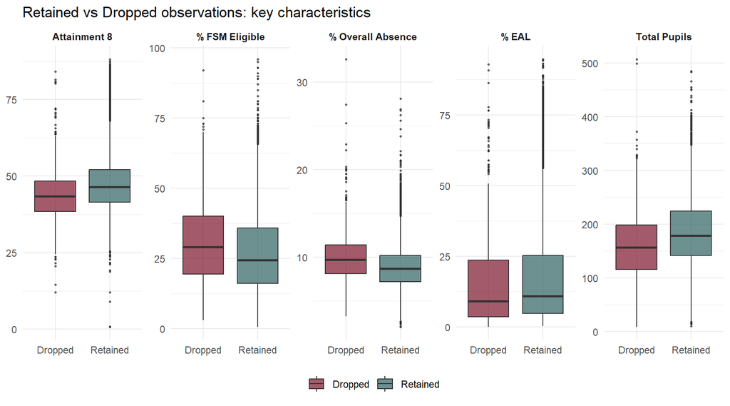

Comparison of key characteristics between retained and dropped observations. Dropped rows tend to have more missing data and different school profiles.

```r
# Compare characteristics of retained vs dropped
compare <- d_diag %>%
  mutate(status = if_else(drop_reason == "Retained", "Retained", "Dropped")) %>%
  select(status, ATT8SCR, PTFSM6CLA1A, PERCTOT, PNUMEAL, TPUP,
         MINORGROUP, year_label) %>%
  pivot_longer(c(ATT8SCR, PTFSM6CLA1A, PERCTOT, PNUMEAL, TPUP),
               names_to = "variable", values_to = "value") %>%
  filter(!is.na(value))

var_labels <- c(
  ATT8SCR = "Attainment 8",
  PTFSM6CLA1A = "% FSM Eligible",
  PERCTOT = "% Overall Absence",
  PNUMEAL = "% EAL",
  TPUP = "Total Pupils"
)

compare <- compare %>%
  mutate(variable = factor(variable, levels = names(var_labels), labels = var_labels))

ggplot(compare, aes(x = status, y = value, fill = status)) +
  geom_boxplot(alpha = 0.7, outlier.size = 0.5) +
  facet_wrap(~ variable, scales = "free_y", ncol = 5) +
  scale_fill_manual(values = c("Retained" = "#2e6260", "Dropped" = "#7b132b")) +
  labs(x = NULL, y = NULL, fill = NULL,
       title = "Retained vs Dropped observations: key characteristics") +
  theme_minimal(base_size = 11) +
  theme(legend.position = "bottom",
        strip.text = element_text(face = "bold"))
```

# 3 Analysis A: Full Panel Models

## 3.1 All Pupils

```r
d <- model_data %>%
  filter(!is.na(ATT8SCR), ATT8SCR > 0) %>%
  droplevels()

contrasts(d$OFSTEDRATING_1) <- contr.treatment(levels(d$OFSTEDRATING_1))

cat("Observations:", nrow(d), "\n")
```

```
Observations: 9047
```

```r
mod_a_all <- lmer(
  log(ATT8SCR) ~
    log(PTFSM6CLA1A) + log(PERCTOT) + log(PNUMEAL) +
    ks2_c + ADMPOL_PT + gorard_segregation +
    remained_in_the_same_school +
    teachers_on_leadership_pay_range_percent +
    log(average_number_of_days_taken) +
    (1 | year_label) + (1 | OFSTEDRATING_1) + (1 | gor_name/LANAME),
  data = d,
  REML = TRUE,
  na.action = na.exclude,
  control = lmerControl(optimizer = "bobyqa", optCtrl = list(maxfun = 20000))
)

summary(mod_a_all)
```

```
Linear mixed model fit by REML. t-tests use Satterthwaite's method [
lmerModLmerTest]
Formula: log(ATT8SCR) ~ log(PTFSM6CLA1A) + log(PERCTOT) + log(PNUMEAL) +
    ks2_c + ADMPOL_PT + gorard_segregation + remained_in_the_same_school +
    teachers_on_leadership_pay_range_percent + log(average_number_of_days_taken) +
    (1 | year_label) + (1 | OFSTEDRATING_1) + (1 | gor_name/LANAME)
   Data: d
Control: lmerControl(optimizer = "bobyqa", optCtrl = list(maxfun = 20000))

REML criterion at convergence: -18174.4

Scaled residuals:
    Min      1Q  Median      3Q     Max
-49.085  -0.458   0.032   0.517   5.773

Random effects:
 Groups          Name        Variance  Std.Dev.
 LANAME:gor_name (Intercept) 0.0006152 0.02480
 gor_name        (Intercept) 0.0001722 0.01312
 OFSTEDRATING_1  (Intercept) 0.0021673 0.04655
 year_label      (Intercept) 0.0022331 0.04726
 Residual                    0.0075163 0.08670
Number of obs: 9047, groups:
LANAME:gor_name, 152; gor_name, 9; OFSTEDRATING_1, 4; year_label, 3

Fixed effects:
                                           Estimate Std. Error         df
(Intercept)                               4.234e+00  4.136e-02  7.756e+00
log(PTFSM6CLA1A)                         -4.344e-02  2.953e-03  6.812e+03
log(PERCTOT)                             -2.041e-01  5.049e-03  8.981e+03
log(PNUMEAL)                              7.288e-03  1.242e-03  5.669e+03
ks2_c                                     3.429e-02  7.152e-04  8.009e+03
ADMPOL_PTOTHER NON SEL                    2.767e-02  7.343e-03  1.088e+03
ADMPOL_PTSEL                             -1.477e-02  8.004e-03  8.767e+03
gorard_segregation                        4.726e-02  4.551e-02  4.053e+02
remained_in_the_same_school               4.154e-04  5.196e-05  8.890e+03
teachers_on_leadership_pay_range_percent -1.174e-03  2.185e-04  9.023e+03
log(average_number_of_days_taken)        -1.238e-02  2.516e-03  8.997e+03
                                         t value Pr(>|t|)
(Intercept)                              102.370 2.00e-13 ***
```

[output cut: 21 more lines]

```
grrd_sgrgtn -0.252  0.101 -0.042  0.018  0.047  0.313  0.092
rmnd_n_th__ -0.108  0.095  0.033 -0.091 -0.137  0.006  0.207  0.024
tchrs_n____ -0.073 -0.095  0.017  0.008  0.061  0.000 -0.006  0.010  0.299
lg(vrg____) -0.090 -0.013 -0.131 -0.013  0.016 -0.007 -0.007  0.006  0.010
            t_____
l(PTFSM6CLA
lg(PERCTOT)
lg(PNUMEAL)
ks2_c
ADMPOL_PTNS
ADMPOL_PTSE
grrd_sgrgtn
rmnd_n_th__
tchrs_n____
lg(vrg____)  0.006
```

### 3.1.1 Quick checks

```r
cat("Fixed effects:\n")
```

```
Fixed effects:
```

```r
fixef(mod_a_all)
```

```
                             (Intercept)
                             4.234158165
                        log(PTFSM6CLA1A)
                            -0.043444159
                            log(PERCTOT)
                            -0.204122256
                            log(PNUMEAL)
                             0.007288386
                                   ks2_c
                             0.034291181
                  ADMPOL_PTOTHER NON SEL
                             0.027670651
                            ADMPOL_PTSEL
                            -0.014771292
                      gorard_segregation
                             0.047260084
             remained_in_the_same_school
                             0.000415379
teachers_on_leadership_pay_range_percent
                            -0.001173536
       log(average_number_of_days_taken)
                            -0.012377408
```

```r
cat("\nVariance components:\n")
```

```
Variance components:
```

```r
print(VarCorr(mod_a_all))
```

```
 Groups          Name        Std.Dev.
 LANAME:gor_name (Intercept) 0.024803
 gor_name        (Intercept) 0.013121
 OFSTEDRATING_1  (Intercept) 0.046554
 year_label      (Intercept) 0.047255
 Residual                    0.086697
```

```r
cat("\nR-squared:\n")
```

```
R-squared:
```

```r
print(r2(mod_a_all))
```

```
# R2 for Mixed Models

  Conditional R2: 0.801
     Marginal R2: 0.664
```

```r
cat("\nSingular fit?", isSingular(mod_a_all), "\n")
```

```
Singular fit? FALSE
```

## 3.2 Disadvantaged Pupils

```r
d <- model_data %>%
  filter(!is.na(ATT8SCR_FSM6CLA1A), ATT8SCR_FSM6CLA1A > 0) %>%
  droplevels()

contrasts(d$OFSTEDRATING_1) <- contr.treatment(levels(d$OFSTEDRATING_1))

cat("Observations:", nrow(d), "\n")
```

```
Observations: 8936
```

```r
mod_a_disadv <- lmer(
  log(ATT8SCR_FSM6CLA1A) ~
    log(PTFSM6CLA1A) + log(PERCTOT) + log(PNUMEAL) +
    ks2_c + ADMPOL_PT + gorard_segregation +
    remained_in_the_same_school +
    teachers_on_leadership_pay_range_percent +
    log(average_number_of_days_taken) +
    (1 | year_label) + (1 | OFSTEDRATING_1) + (1 | gor_name/LANAME),
  data = d,
  REML = TRUE,
  na.action = na.exclude,
  control = lmerControl(optimizer = "bobyqa", optCtrl = list(maxfun = 20000))
)

summary(mod_a_disadv)
```

```
Linear mixed model fit by REML. t-tests use Satterthwaite's method [
lmerModLmerTest]
Formula:
log(ATT8SCR_FSM6CLA1A) ~ log(PTFSM6CLA1A) + log(PERCTOT) + log(PNUMEAL) +
    ks2_c + ADMPOL_PT + gorard_segregation + remained_in_the_same_school +
    teachers_on_leadership_pay_range_percent + log(average_number_of_days_taken) +
    (1 | year_label) + (1 | OFSTEDRATING_1) + (1 | gor_name/LANAME)
   Data: d
Control: lmerControl(optimizer = "bobyqa", optCtrl = list(maxfun = 20000))

REML criterion at convergence: -12840.4

Scaled residuals:
    Min      1Q  Median      3Q     Max
-5.9450 -0.6005  0.0425  0.6491  5.2644

Random effects:
 Groups          Name        Variance  Std.Dev.
 LANAME:gor_name (Intercept) 0.0012570 0.03545
 gor_name        (Intercept) 0.0005876 0.02424
 OFSTEDRATING_1  (Intercept) 0.0027777 0.05270
 year_label      (Intercept) 0.0036138 0.06011
 Residual                    0.0132933 0.11530
Number of obs: 8936, groups:
LANAME:gor_name, 151; gor_name, 9; OFSTEDRATING_1, 4; year_label, 3

Fixed effects:
                                           Estimate Std. Error         df
(Intercept)                               4.006e+00  5.258e-02  8.559e+00
log(PTFSM6CLA1A)                          2.594e-02  4.281e-03  7.065e+03
log(PERCTOT)                             -2.916e-01  6.825e-03  8.898e+03
log(PNUMEAL)                              2.405e-02  1.683e-03  6.581e+03
ks2_c                                     3.119e-02  9.799e-04  8.242e+03
ADMPOL_PTOTHER NON SEL                    3.391e-03  1.044e-02  9.349e+02
ADMPOL_PTSEL                              1.742e-01  1.093e-02  8.686e+03
gorard_segregation                        8.945e-02  6.390e-02  4.180e+02
remained_in_the_same_school              -7.315e-05  6.996e-05  8.823e+03
teachers_on_leadership_pay_range_percent -8.468e-04  2.920e-04  8.904e+03
log(average_number_of_days_taken)        -1.716e-02  3.378e-03  8.878e+03
                                         t value Pr(>|t|)
```

[output cut: 22 more lines]

```
grrd_sgrgtn -0.287  0.114 -0.038  0.015  0.061  0.317  0.089
rmnd_n_th__ -0.126  0.129  0.018 -0.096 -0.118  0.015  0.197  0.032
tchrs_n____ -0.078 -0.086  0.017  0.011  0.061  0.000 -0.002  0.008  0.300
lg(vrg____) -0.099  0.005 -0.134 -0.016  0.022 -0.006 -0.010  0.004  0.018
            t_____
l(PTFSM6CLA
lg(PERCTOT)
lg(PNUMEAL)
ks2_c
ADMPOL_PTNS
ADMPOL_PTSE
grrd_sgrgtn
rmnd_n_th__
tchrs_n____
lg(vrg____)  0.010
```

### 3.2.1 Quick checks

```r
fixef(mod_a_disadv)
```

```
                             (Intercept)
                            4.005854e+00
                        log(PTFSM6CLA1A)
                            2.593911e-02
                            log(PERCTOT)
                           -2.916457e-01
                            log(PNUMEAL)
                            2.404700e-02
                                   ks2_c
                            3.118713e-02
                  ADMPOL_PTOTHER NON SEL
                            3.390613e-03
                            ADMPOL_PTSEL
                            1.741946e-01
                      gorard_segregation
                            8.945207e-02
             remained_in_the_same_school
                           -7.314969e-05
teachers_on_leadership_pay_range_percent
                           -8.467891e-04
       log(average_number_of_days_taken)
                           -1.716391e-02
```

```r
print(VarCorr(mod_a_disadv))
```

```
 Groups          Name        Std.Dev.
 LANAME:gor_name (Intercept) 0.035454
 gor_name        (Intercept) 0.024241
 OFSTEDRATING_1  (Intercept) 0.052704
 year_label      (Intercept) 0.060115
 Residual                    0.115297
```

```r
print(r2(mod_a_disadv))
```

```
# R2 for Mixed Models

  Conditional R2: 0.728
     Marginal R2: 0.559
```

```r
cat("Singular fit?", isSingular(mod_a_disadv), "\n")
```

```
Singular fit? FALSE
```

## 3.3 Non-Disadvantaged Pupils

```r
d <- model_data %>%
  filter(!is.na(ATT8SCR_NFSM6CLA1A), ATT8SCR_NFSM6CLA1A > 0) %>%
  droplevels()

contrasts(d$OFSTEDRATING_1) <- contr.treatment(levels(d$OFSTEDRATING_1))

cat("Observations:", nrow(d), "\n")
```

```
Observations: 8936
```

```r
mod_a_nondisadv <- lmer(
  log(ATT8SCR_NFSM6CLA1A) ~
    log(PTFSM6CLA1A) + log(PERCTOT) + log(PNUMEAL) +
    ks2_c + ADMPOL_PT + gorard_segregation +
    remained_in_the_same_school +
    teachers_on_leadership_pay_range_percent +
    log(average_number_of_days_taken) +
    (1 | year_label) + (1 | OFSTEDRATING_1) + (1 | gor_name/LANAME),
  data = d,
  REML = TRUE,
  na.action = na.exclude,
  control = lmerControl(optimizer = "bobyqa", optCtrl = list(maxfun = 20000))
)

summary(mod_a_nondisadv)
```

```
Linear mixed model fit by REML. t-tests use Satterthwaite's method [
lmerModLmerTest]
Formula:
log(ATT8SCR_NFSM6CLA1A) ~ log(PTFSM6CLA1A) + log(PERCTOT) + log(PNUMEAL) +
    ks2_c + ADMPOL_PT + gorard_segregation + remained_in_the_same_school +
    teachers_on_leadership_pay_range_percent + log(average_number_of_days_taken) +
    (1 | year_label) + (1 | OFSTEDRATING_1) + (1 | gor_name/LANAME)
   Data: d
Control: lmerControl(optimizer = "bobyqa", optCtrl = list(maxfun = 20000))

REML criterion at convergence: -21681.8

Scaled residuals:
     Min       1Q   Median       3Q      Max
-13.5096  -0.5671   0.0266   0.6094   5.7772

Random effects:
 Groups          Name        Variance  Std.Dev.
 LANAME:gor_name (Intercept) 5.924e-04 0.024339
 gor_name        (Intercept) 9.877e-05 0.009938
 OFSTEDRATING_1  (Intercept) 1.701e-03 0.041242
 year_label      (Intercept) 1.917e-03 0.043782
 Residual                    4.922e-03 0.070159
Number of obs: 8936, groups:
LANAME:gor_name, 151; gor_name, 9; OFSTEDRATING_1, 4; year_label, 3

Fixed effects:
                                           Estimate Std. Error         df
(Intercept)                               4.132e+00  3.715e-02  7.169e+00
log(PTFSM6CLA1A)                         -1.568e-02  2.613e-03  6.712e+03
log(PERCTOT)                             -1.602e-01  4.159e-03  8.878e+03
log(PNUMEAL)                              9.434e-03  1.028e-03  6.292e+03
ks2_c                                     3.307e-02  5.973e-04  7.826e+03
ADMPOL_PTOTHER NON SEL                    3.008e-02  6.565e-03  1.219e+03
ADMPOL_PTSEL                              1.207e-03  6.665e-03  8.661e+03
gorard_segregation                        1.989e-02  4.097e-02  4.954e+02
remained_in_the_same_school               3.747e-04  4.268e-05  8.882e+03
teachers_on_leadership_pay_range_percent -1.215e-03  1.779e-04  8.894e+03
log(average_number_of_days_taken)        -1.540e-02  2.057e-03  8.869e+03
                                         t value Pr(>|t|)
```

[output cut: 22 more lines]

```
grrd_sgrgtn -0.253  0.106 -0.035  0.018  0.060  0.292  0.083
rmnd_n_th__ -0.108  0.130  0.017 -0.094 -0.118  0.011  0.196  0.028
tchrs_n____ -0.067 -0.087  0.017  0.011  0.061  0.000 -0.002  0.008  0.299
lg(vrg____) -0.085  0.006 -0.134 -0.016  0.022 -0.007 -0.010  0.002  0.018
            t_____
l(PTFSM6CLA
lg(PERCTOT)
lg(PNUMEAL)
ks2_c
ADMPOL_PTNS
ADMPOL_PTSE
grrd_sgrgtn
rmnd_n_th__
tchrs_n____
lg(vrg____)  0.010
```

### 3.3.1 Quick checks

```r
fixef(mod_a_nondisadv)
```

```
                             (Intercept)
                            4.1323301817
                        log(PTFSM6CLA1A)
                           -0.0156768987
                            log(PERCTOT)
                           -0.1602149804
                            log(PNUMEAL)
                            0.0094337016
                                   ks2_c
                            0.0330731520
                  ADMPOL_PTOTHER NON SEL
                            0.0300831673
                            ADMPOL_PTSEL
                            0.0012065471
                      gorard_segregation
                            0.0198891812
             remained_in_the_same_school
                            0.0003747001
teachers_on_leadership_pay_range_percent
                           -0.0012153449
       log(average_number_of_days_taken)
                           -0.0154044862
```

```r
print(VarCorr(mod_a_nondisadv))
```

```
 Groups          Name        Std.Dev.
 LANAME:gor_name (Intercept) 0.0243393
 gor_name        (Intercept) 0.0099385
 OFSTEDRATING_1  (Intercept) 0.0412415
 year_label      (Intercept) 0.0437822
 Residual                    0.0701586
```

```r
print(r2(mod_a_nondisadv))
```

```
# R2 for Mixed Models

  Conditional R2: 0.810
     Marginal R2: 0.643
```

```r
cat("Singular fit?", isSingular(mod_a_nondisadv), "\n")
```

```
Singular fit? FALSE
```

# 4 Analysis B: Full Per-Year Models

Same 9 fixed effects as Analysis A, but fitted separately for each year. No `year_label` random effect.

```r
year_levels <- sort(unique(as.character(model_data$year_label)))
cat("Years to fit:", paste(year_levels, collapse = ", "), "\n")
```

```
Years to fit: 2021-22, 2022-23, 2023-24
```

## 4.1 All Pupils (per year)

```r
for (yr in year_levels) {

  cat("\n", strrep("=", 60), "\n")
  cat("YEAR:", yr, "- All Pupils\n")
  cat(strrep("=", 60), "\n")

  d <- model_data %>%
    filter(year_label == yr, !is.na(ATT8SCR), ATT8SCR > 0) %>%
    droplevels()

  contrasts(d$OFSTEDRATING_1) <- contr.treatment(levels(d$OFSTEDRATING_1))

  cat("Observations:", nrow(d), "\n")

  mod <- lmer(
    log(ATT8SCR) ~
      log(PTFSM6CLA1A) + log(PERCTOT) + log(PNUMEAL) +
      ks2_c + ADMPOL_PT + gorard_segregation +
      remained_in_the_same_school +
      teachers_on_leadership_pay_range_percent +
      log(average_number_of_days_taken) +
      (1 | OFSTEDRATING_1) + (1 | gor_name/LANAME),
    data = d,
    REML = TRUE,
    na.action = na.exclude,
    control = lmerControl(optimizer = "bobyqa", optCtrl = list(maxfun = 20000))
  )

  print(summary(mod))
  cat("\nR-squared:\n")
  print(r2(mod))
  cat("\nSingular fit?", isSingular(mod), "\n")
}
```

```
 ============================================================
YEAR: 2021-22 - All Pupils
============================================================
Observations: 2943
Linear mixed model fit by REML. t-tests use Satterthwaite's method [
lmerModLmerTest]
Formula: log(ATT8SCR) ~ log(PTFSM6CLA1A) + log(PERCTOT) + log(PNUMEAL) +
    ks2_c + ADMPOL_PT + gorard_segregation + remained_in_the_same_school +
    teachers_on_leadership_pay_range_percent + log(average_number_of_days_taken) +
    (1 | OFSTEDRATING_1) + (1 | gor_name/LANAME)
   Data: d
Control: lmerControl(optimizer = "bobyqa", optCtrl = list(maxfun = 20000))

REML criterion at convergence: -6196.1

Scaled residuals:
     Min       1Q   Median       3Q      Max
-19.0874  -0.4827   0.0302   0.5639   5.8881

Random effects:
 Groups          Name        Variance  Std.Dev.
 LANAME:gor_name (Intercept) 5.056e-04 0.022486
 gor_name        (Intercept) 6.235e-05 0.007896
 OFSTEDRATING_1  (Intercept) 2.429e-03 0.049289
 Residual                    6.559e-03 0.080986
Number of obs: 2943, groups:
LANAME:gor_name, 152; gor_name, 9; OFSTEDRATING_1, 4

Fixed effects:
                                           Estimate Std. Error         df
(Intercept)                               4.209e+00  3.958e-02  1.912e+01
log(PTFSM6CLA1A)                         -3.485e-02  4.467e-03  1.543e+03
log(PERCTOT)                             -1.898e-01  8.200e-03  2.859e+03
log(PNUMEAL)                              5.444e-03  1.816e-03  1.128e+03
ks2_c                                     3.381e-02  1.082e-03  1.974e+03
ADMPOL_PTOTHER NON SEL                    2.928e-02  1.005e-02  3.589e+02
ADMPOL_PTSEL                             -6.652e-03  1.284e-02  2.689e+03
gorard_segregation                        5.632e-02  6.040e-02  1.779e+02
remained_in_the_same_school               5.644e-04  8.224e-05  2.916e+03
teachers_on_leadership_pay_range_percent -1.661e-03  3.595e-04  2.911e+03
```

[output cut: 208 more lines]

```
ks2_c
ADMPOL_PTNS
ADMPOL_PTSE
grrd_sgrgtn
rmnd_n_th__
tchrs_n____
lg(vrg____) -0.023

R-squared:
# R2 for Mixed Models

  Conditional R2: 0.727
     Marginal R2: 0.665

Singular fit? FALSE
```

## 4.2 Disadvantaged Pupils (per year)

```r
for (yr in year_levels) {

  cat("\n", strrep("=", 60), "\n")
  cat("YEAR:", yr, "- Disadvantaged Pupils\n")
  cat(strrep("=", 60), "\n")

  d <- model_data %>%
    filter(year_label == yr,
           !is.na(ATT8SCR_FSM6CLA1A), ATT8SCR_FSM6CLA1A > 0) %>%
    droplevels()

  contrasts(d$OFSTEDRATING_1) <- contr.treatment(levels(d$OFSTEDRATING_1))

  cat("Observations:", nrow(d), "\n")

  mod <- lmer(
    log(ATT8SCR_FSM6CLA1A) ~
      log(PTFSM6CLA1A) + log(PERCTOT) + log(PNUMEAL) +
      ks2_c + ADMPOL_PT + gorard_segregation +
      remained_in_the_same_school +
      teachers_on_leadership_pay_range_percent +
      log(average_number_of_days_taken) +
      (1 | OFSTEDRATING_1) + (1 | gor_name/LANAME),
    data = d,
    REML = TRUE,
    na.action = na.exclude,
    control = lmerControl(optimizer = "bobyqa", optCtrl = list(maxfun = 20000))
  )

  print(summary(mod))
  cat("\nR-squared:\n")
  print(r2(mod))
  cat("\nSingular fit?", isSingular(mod), "\n")
}
```

```
 ============================================================
YEAR: 2021-22 - Disadvantaged Pupils
============================================================
Observations: 2905
Linear mixed model fit by REML. t-tests use Satterthwaite's method [
lmerModLmerTest]
Formula:
log(ATT8SCR_FSM6CLA1A) ~ log(PTFSM6CLA1A) + log(PERCTOT) + log(PNUMEAL) +
    ks2_c + ADMPOL_PT + gorard_segregation + remained_in_the_same_school +
    teachers_on_leadership_pay_range_percent + log(average_number_of_days_taken) +
    (1 | OFSTEDRATING_1) + (1 | gor_name/LANAME)
   Data: d
Control: lmerControl(optimizer = "bobyqa", optCtrl = list(maxfun = 20000))

REML criterion at convergence: -4092.2

Scaled residuals:
    Min      1Q  Median      3Q     Max
-5.8412 -0.6098  0.0447  0.6474  3.1577

Random effects:
 Groups          Name        Variance  Std.Dev.
 LANAME:gor_name (Intercept) 0.0007576 0.02752
 gor_name        (Intercept) 0.0003606 0.01899
 OFSTEDRATING_1  (Intercept) 0.0027622 0.05256
 Residual                    0.0132741 0.11521
Number of obs: 2905, groups:
LANAME:gor_name, 151; gor_name, 9; OFSTEDRATING_1, 4

Fixed effects:
                                           Estimate Std. Error         df
(Intercept)                               3.969e+00  5.235e-02  4.335e+01
log(PTFSM6CLA1A)                          2.762e-02  6.802e-03  1.743e+03
log(PERCTOT)                             -2.586e-01  1.177e-02  2.851e+03
log(PNUMEAL)                              2.377e-02  2.608e-03  1.582e+03
ks2_c                                     3.052e-02  1.589e-03  2.345e+03
ADMPOL_PTOTHER NON SEL                    3.298e-03  1.398e-02  3.017e+02
ADMPOL_PTSEL                              1.917e-01  1.871e-02  2.832e+03
gorard_segregation                        4.344e-02  8.269e-02  1.923e+02
remained_in_the_same_school               2.170e-04  1.176e-04  2.860e+03
```

[output cut: 211 more lines]

```
ks2_c
ADMPOL_PTNS
ADMPOL_PTSE
grrd_sgrgtn
rmnd_n_th__
tchrs_n____
lg(vrg____) -0.022

R-squared:
# R2 for Mixed Models

  Conditional R2: 0.729
     Marginal R2: 0.641

Singular fit? FALSE
```

## 4.3 Non-Disadvantaged Pupils (per year)

```r
for (yr in year_levels) {

  cat("\n", strrep("=", 60), "\n")
  cat("YEAR:", yr, "- Non-Disadvantaged Pupils\n")
  cat(strrep("=", 60), "\n")

  d <- model_data %>%
    filter(year_label == yr,
           !is.na(ATT8SCR_NFSM6CLA1A), ATT8SCR_NFSM6CLA1A > 0) %>%
    droplevels()

  contrasts(d$OFSTEDRATING_1) <- contr.treatment(levels(d$OFSTEDRATING_1))

  cat("Observations:", nrow(d), "\n")

  mod <- lmer(
    log(ATT8SCR_NFSM6CLA1A) ~
      log(PTFSM6CLA1A) + log(PERCTOT) + log(PNUMEAL) +
      ks2_c + ADMPOL_PT + gorard_segregation +
      remained_in_the_same_school +
      teachers_on_leadership_pay_range_percent +
      log(average_number_of_days_taken) +
      (1 | OFSTEDRATING_1) + (1 | gor_name/LANAME),
    data = d,
    REML = TRUE,
    na.action = na.exclude,
    control = lmerControl(optimizer = "bobyqa", optCtrl = list(maxfun = 20000))
  )

  print(summary(mod))
  cat("\nR-squared:\n")
  print(r2(mod))
  cat("\nSingular fit?", isSingular(mod), "\n")
}
```

```
 ============================================================
YEAR: 2021-22 - Non-Disadvantaged Pupils
============================================================
Observations: 2905
Linear mixed model fit by REML. t-tests use Satterthwaite's method [
lmerModLmerTest]
Formula:
log(ATT8SCR_NFSM6CLA1A) ~ log(PTFSM6CLA1A) + log(PERCTOT) + log(PNUMEAL) +
    ks2_c + ADMPOL_PT + gorard_segregation + remained_in_the_same_school +
    teachers_on_leadership_pay_range_percent + log(average_number_of_days_taken) +
    (1 | OFSTEDRATING_1) + (1 | gor_name/LANAME)
   Data: d
Control: lmerControl(optimizer = "bobyqa", optCtrl = list(maxfun = 20000))

REML criterion at convergence: -6678.1

Scaled residuals:
     Min       1Q   Median       3Q      Max
-12.9656  -0.5390   0.0157   0.6121   4.3633

Random effects:
 Groups          Name        Variance  Std.Dev.
 LANAME:gor_name (Intercept) 3.997e-04 0.019992
 gor_name        (Intercept) 1.525e-05 0.003905
 OFSTEDRATING_1  (Intercept) 1.932e-03 0.043957
 Residual                    5.411e-03 0.073560
Number of obs: 2905, groups:
LANAME:gor_name, 151; gor_name, 9; OFSTEDRATING_1, 4

Fixed effects:
                                           Estimate Std. Error         df
(Intercept)                               4.109e+00  3.626e-02  2.119e+01
log(PTFSM6CLA1A)                         -8.763e-03  4.272e-03  8.026e+02
log(PERCTOT)                             -1.458e-01  7.508e-03  2.616e+03
log(PNUMEAL)                              6.615e-03  1.634e-03  5.507e+02
ks2_c                                     3.381e-02  9.989e-04  1.019e+03
ADMPOL_PTOTHER NON SEL                    2.961e-02  9.207e-03  3.451e+02
ADMPOL_PTSEL                             -1.710e-03  1.187e-02  2.055e+03
gorard_segregation                        9.928e-03  5.501e-02  2.094e+02
remained_in_the_same_school               4.994e-04  7.536e-05  2.878e+03
```

[output cut: 211 more lines]

```
ks2_c
ADMPOL_PTNS
ADMPOL_PTSE
grrd_sgrgtn
rmnd_n_th__
tchrs_n____
lg(vrg____) -0.023

R-squared:
# R2 for Mixed Models

  Conditional R2: 0.809
     Marginal R2: 0.725

Singular fit? FALSE
```

# 5 Analysis C: Core Panel Models

Reduced specification with 5 fixed effects. All 4 years pooled (including 2024-25). `year_label` as a random intercept.

## 5.1 All Pupils

```r
d <- core_model_data %>%
  filter(!is.na(ATT8SCR), ATT8SCR > 0) %>%
  droplevels()

contrasts(d$OFSTEDRATING_1) <- contr.treatment(levels(d$OFSTEDRATING_1))

cat("Observations:", nrow(d), "\n")
```

```
Observations: 12845
```

```r
mod_c_all <- lmer(
  log(ATT8SCR) ~
    log(PTFSM6CLA1A) + log(PERCTOT) + log(PNUMEAL) +
    ADMPOL_PT + gorard_segregation +
    (1 | year_label) + (1 | OFSTEDRATING_1) + (1 | gor_name/LANAME),
  data = d,
  REML = TRUE,
  na.action = na.exclude,
  control = lmerControl(optimizer = "bobyqa", optCtrl = list(maxfun = 20000))
)

summary(mod_c_all)
```

```
Linear mixed model fit by REML. t-tests use Satterthwaite's method [
lmerModLmerTest]
Formula: log(ATT8SCR) ~ log(PTFSM6CLA1A) + log(PERCTOT) + log(PNUMEAL) +
    ADMPOL_PT + gorard_segregation + (1 | year_label) + (1 |
    OFSTEDRATING_1) + (1 | gor_name/LANAME)
   Data: d
Control: lmerControl(optimizer = "bobyqa", optCtrl = list(maxfun = 20000))

REML criterion at convergence: -21760.7

Scaled residuals:
    Min      1Q  Median      3Q     Max
-41.943  -0.465   0.047   0.541   4.301

Random effects:
 Groups          Name        Variance Std.Dev.
 LANAME:gor_name (Intercept) 0.001468 0.03831
 gor_name        (Intercept) 0.001009 0.03176
 OFSTEDRATING_1  (Intercept) 0.002906 0.05391
 year_label      (Intercept) 0.001121 0.03348
 Residual                    0.010372 0.10184
Number of obs: 12845, groups:
LANAME:gor_name, 152; gor_name, 9; OFSTEDRATING_1, 4; year_label, 4

Fixed effects:
                         Estimate Std. Error         df t value Pr(>|t|)
(Intercept)             4.784e+00  3.741e-02  9.511e+00 127.896   <2e-16 ***
log(PTFSM6CLA1A)       -1.280e-01  2.558e-03  1.247e+04 -50.047   <2e-16 ***
log(PERCTOT)           -2.614e-01  4.730e-03  1.283e+04 -55.264   <2e-16 ***
log(PNUMEAL)            1.999e-04  1.252e-03  1.155e+04   0.160    0.873
ADMPOL_PTOTHER NON SEL  1.229e-02  8.087e-03  2.691e+03   1.520    0.129
ADMPOL_PTSEL            1.614e-01  6.816e-03  1.197e+04  23.681   <2e-16 ***
gorard_segregation     -6.732e-02  5.442e-02  6.771e+02  -1.237    0.217
---
Signif. codes:  0 '***' 0.001 '**' 0.01 '*' 0.05 '.' 0.1 ' ' 1

Correlation of Fixed Effects:
            (Intr) l(PTFS l(PERC l(PNUM ADMPNS ADMPOL
l(PTFSM6CLA -0.077
lg(PERCTOT) -0.186 -0.460
lg(PNUMEAL) -0.049 -0.352  0.169
ADMPOL_PTNS -0.253 -0.007  0.011  0.009
ADMPOL_PTSE -0.232  0.332  0.094 -0.158  0.578
grrd_sgrgtn -0.281  0.056 -0.034  0.002  0.210  0.099
```

### 5.1.1 Quick checks

```r
fixef(mod_c_all)
```

```
           (Intercept)       log(PTFSM6CLA1A)           log(PERCTOT)
          4.7840754430          -0.1280317210          -0.2614173998
          log(PNUMEAL) ADMPOL_PTOTHER NON SEL           ADMPOL_PTSEL
          0.0001998932           0.0122943907           0.1614049511
    gorard_segregation
         -0.0673205828
```

```r
print(VarCorr(mod_c_all))
```

```
 Groups          Name        Std.Dev.
 LANAME:gor_name (Intercept) 0.038314
 gor_name        (Intercept) 0.031765
 OFSTEDRATING_1  (Intercept) 0.053906
 year_label      (Intercept) 0.033482
 Residual                    0.101843
```

```r
print(r2(mod_c_all))
```

```
# R2 for Mixed Models

  Conditional R2: 0.738
     Marginal R2: 0.573
```

```r
cat("Singular fit?", isSingular(mod_c_all), "\n")
```

```
Singular fit? FALSE
```

## 5.2 Disadvantaged Pupils

```r
d <- core_model_data %>%
  filter(!is.na(ATT8SCR_FSM6CLA1A), ATT8SCR_FSM6CLA1A > 0) %>%
  droplevels()

contrasts(d$OFSTEDRATING_1) <- contr.treatment(levels(d$OFSTEDRATING_1))

cat("Observations:", nrow(d), "\n")
```

```
Observations: 12702
```

```r
mod_c_disadv <- lmer(
  log(ATT8SCR_FSM6CLA1A) ~
    log(PTFSM6CLA1A) + log(PERCTOT) + log(PNUMEAL) +
    ADMPOL_PT + gorard_segregation +
    (1 | year_label) + (1 | OFSTEDRATING_1) + (1 | gor_name/LANAME),
  data = d,
  REML = TRUE,
  na.action = na.exclude,
  control = lmerControl(optimizer = "bobyqa", optCtrl = list(maxfun = 20000))
)

summary(mod_c_disadv)
```

```
Linear mixed model fit by REML. t-tests use Satterthwaite's method [
lmerModLmerTest]
Formula:
log(ATT8SCR_FSM6CLA1A) ~ log(PTFSM6CLA1A) + log(PERCTOT) + log(PNUMEAL) +
    ADMPOL_PT + gorard_segregation + (1 | year_label) + (1 |
    OFSTEDRATING_1) + (1 | gor_name/LANAME)
   Data: d
Control: lmerControl(optimizer = "bobyqa", optCtrl = list(maxfun = 20000))

REML criterion at convergence: -16855.2

Scaled residuals:
    Min      1Q  Median      3Q     Max
-8.3987 -0.5935  0.0443  0.6489  4.9758

Random effects:
 Groups          Name        Variance Std.Dev.
 LANAME:gor_name (Intercept) 0.002183 0.04672
 gor_name        (Intercept) 0.002046 0.04523
 OFSTEDRATING_1  (Intercept) 0.003309 0.05753
 year_label      (Intercept) 0.002415 0.04914
 Residual                    0.014964 0.12233
Number of obs: 12702, groups:
LANAME:gor_name, 151; gor_name, 9; OFSTEDRATING_1, 4; year_label, 4

Fixed effects:
                         Estimate Std. Error         df t value Pr(>|t|)
(Intercept)             4.462e+00  4.576e-02  1.217e+01  97.492   <2e-16 ***
log(PTFSM6CLA1A)       -4.822e-02  3.259e-03  1.234e+04 -14.796   <2e-16 ***
log(PERCTOT)           -3.418e-01  5.791e-03  1.269e+04 -59.029   <2e-16 ***
log(PNUMEAL)            1.782e-02  1.519e-03  1.157e+04  11.733   <2e-16 ***
ADMPOL_PTOTHER NON SEL -1.202e-02  1.030e-02  2.111e+03  -1.166    0.244
ADMPOL_PTSEL            3.402e-01  8.383e-03  1.159e+04  40.587   <2e-16 ***
gorard_segregation     -5.923e-02  6.691e-02  7.049e+02  -0.885    0.376
---
Signif. codes:  0 '***' 0.001 '**' 0.01 '*' 0.05 '.' 0.1 ' ' 1

Correlation of Fixed Effects:
            (Intr) l(PTFS l(PERC l(PNUM ADMPNS ADMPOL
l(PTFSM6CLA -0.088
lg(PERCTOT) -0.177 -0.480
lg(PNUMEAL) -0.043 -0.358  0.178
ADMPOL_PTNS -0.266  0.015  0.003 -0.005
ADMPOL_PTSE -0.234  0.297  0.101 -0.149  0.567
grrd_sgrgtn -0.290  0.064 -0.033  0.002  0.222  0.108
```

### 5.2.1 Quick checks

```r
fixef(mod_c_disadv)
```

```
           (Intercept)       log(PTFSM6CLA1A)           log(PERCTOT)
            4.46159290            -0.04822535            -0.34184360
          log(PNUMEAL) ADMPOL_PTOTHER NON SEL           ADMPOL_PTSEL
            0.01781880            -0.01201722             0.34022724
    gorard_segregation
           -0.05923022
```

```r
print(VarCorr(mod_c_disadv))
```

```
 Groups          Name        Std.Dev.
 LANAME:gor_name (Intercept) 0.046718
 gor_name        (Intercept) 0.045232
 OFSTEDRATING_1  (Intercept) 0.057526
 year_label      (Intercept) 0.049144
 Residual                    0.122329
```

```r
print(r2(mod_c_disadv))
```

```
# R2 for Mixed Models

  Conditional R2: 0.702
     Marginal R2: 0.504
```

```r
cat("Singular fit?", isSingular(mod_c_disadv), "\n")
```

```
Singular fit? FALSE
```

## 5.3 Non-Disadvantaged Pupils

```r
d <- core_model_data %>%
  filter(!is.na(ATT8SCR_NFSM6CLA1A), ATT8SCR_NFSM6CLA1A > 0) %>%
  droplevels()

contrasts(d$OFSTEDRATING_1) <- contr.treatment(levels(d$OFSTEDRATING_1))

cat("Observations:", nrow(d), "\n")
```

```
Observations: 12702
```

```r
mod_c_nondisadv <- lmer(
  log(ATT8SCR_NFSM6CLA1A) ~
    log(PTFSM6CLA1A) + log(PERCTOT) + log(PNUMEAL) +
    ADMPOL_PT + gorard_segregation +
    (1 | year_label) + (1 | OFSTEDRATING_1) + (1 | gor_name/LANAME),
  data = d,
  REML = TRUE,
  na.action = na.exclude,
  control = lmerControl(optimizer = "bobyqa", optCtrl = list(maxfun = 20000))
)

summary(mod_c_nondisadv)
```

```
Linear mixed model fit by REML. t-tests use Satterthwaite's method [
lmerModLmerTest]
Formula:
log(ATT8SCR_NFSM6CLA1A) ~ log(PTFSM6CLA1A) + log(PERCTOT) + log(PNUMEAL) +
    ADMPOL_PT + gorard_segregation + (1 | year_label) + (1 |
    OFSTEDRATING_1) + (1 | gor_name/LANAME)
   Data: d
Control: lmerControl(optimizer = "bobyqa", optCtrl = list(maxfun = 20000))

REML criterion at convergence: -26522.1

Scaled residuals:
     Min       1Q   Median       3Q      Max
-13.3504  -0.5690   0.0343   0.6338   4.1257

Random effects:
 Groups          Name        Variance  Std.Dev.
 LANAME:gor_name (Intercept) 0.0017516 0.04185
 gor_name        (Intercept) 0.0011167 0.03342
 OFSTEDRATING_1  (Intercept) 0.0021919 0.04682
 year_label      (Intercept) 0.0007995 0.02828
 Residual                    0.0069482 0.08336
Number of obs: 12702, groups:
LANAME:gor_name, 151; gor_name, 9; OFSTEDRATING_1, 4; year_label, 4

Fixed effects:
                         Estimate Std. Error         df t value Pr(>|t|)
(Intercept)             4.688e+00  3.305e-02  1.022e+01 141.857  < 2e-16 ***
log(PTFSM6CLA1A)       -1.054e-01  2.234e-03  1.264e+04 -47.170  < 2e-16 ***
log(PERCTOT)           -2.107e-01  3.955e-03  1.267e+04 -53.283  < 2e-16 ***
log(PNUMEAL)            3.296e-03  1.044e-03  1.240e+04   3.158  0.00159 **
ADMPOL_PTOTHER NON SEL  9.836e-04  7.390e-03  3.738e+03   0.133  0.89412
ADMPOL_PTSEL            1.683e-01  5.766e-03  1.218e+04  29.186  < 2e-16 ***
gorard_segregation     -1.127e-01  5.026e-02  1.121e+03  -2.241  0.02519 *
---
Signif. codes:  0 '***' 0.001 '**' 0.01 '*' 0.05 '.' 0.1 ' ' 1

Correlation of Fixed Effects:
            (Intr) l(PTFS l(PERC l(PNUM ADMPNS ADMPOL
l(PTFSM6CLA -0.080
lg(PERCTOT) -0.168 -0.481
lg(PNUMEAL) -0.041 -0.355  0.175
ADMPOL_PTNS -0.251  0.008  0.006 -0.003
ADMPOL_PTSE -0.224  0.293  0.101 -0.148  0.574
grrd_sgrgtn -0.284  0.049 -0.025  0.001  0.161  0.083
```

### 5.3.1 Quick checks

```r
fixef(mod_c_nondisadv)
```

```
           (Intercept)       log(PTFSM6CLA1A)           log(PERCTOT)
          4.6882646258          -0.1053756084          -0.2107353389
          log(PNUMEAL) ADMPOL_PTOTHER NON SEL           ADMPOL_PTSEL
          0.0032965187           0.0009836091           0.1682958981
    gorard_segregation
         -0.1126655116
```

```r
print(VarCorr(mod_c_nondisadv))
```

```
 Groups          Name        Std.Dev.
 LANAME:gor_name (Intercept) 0.041852
 gor_name        (Intercept) 0.033418
 OFSTEDRATING_1  (Intercept) 0.046817
 year_label      (Intercept) 0.028276
 Residual                    0.083356
```

```r
print(r2(mod_c_nondisadv))
```

```
# R2 for Mixed Models

  Conditional R2: 0.746
     Marginal R2: 0.533
```

```r
cat("Singular fit?", isSingular(mod_c_nondisadv), "\n")
```

```
Singular fit? FALSE
```

# 6 Analysis D: Core Per-Year Models

Same 5 core fixed effects, fitted separately for each year. No `year_label` random effect.

```r
core_year_levels <- sort(unique(as.character(core_model_data$year_label)))
cat("Years to fit:", paste(core_year_levels, collapse = ", "), "\n")
```

```
Years to fit: 2021-22, 2022-23, 2023-24, 2024-25
```

## 6.1 All Pupils (per year)

```r
for (yr in core_year_levels) {

  cat("\n", strrep("=", 60), "\n")
  cat("YEAR:", yr, "- All Pupils (core)\n")
  cat(strrep("=", 60), "\n")

  d <- core_model_data %>%
    filter(year_label == yr, !is.na(ATT8SCR), ATT8SCR > 0) %>%
    droplevels()

  contrasts(d$OFSTEDRATING_1) <- contr.treatment(levels(d$OFSTEDRATING_1))

  cat("Observations:", nrow(d), "\n")

  mod <- lmer(
    log(ATT8SCR) ~
      log(PTFSM6CLA1A) + log(PERCTOT) + log(PNUMEAL) +
      ADMPOL_PT + gorard_segregation +
      (1 | OFSTEDRATING_1) + (1 | gor_name/LANAME),
    data = d,
    REML = TRUE,
    na.action = na.exclude,
    control = lmerControl(optimizer = "bobyqa", optCtrl = list(maxfun = 20000))
  )

  print(summary(mod))
  cat("\nR-squared:\n")
  print(r2(mod))
  cat("\nSingular fit?", isSingular(mod), "\n")
}
```

```
 ============================================================
YEAR: 2021-22 - All Pupils (core)
============================================================
Observations: 3200
Linear mixed model fit by REML. t-tests use Satterthwaite's method [
lmerModLmerTest]
Formula: log(ATT8SCR) ~ log(PTFSM6CLA1A) + log(PERCTOT) + log(PNUMEAL) +
    ADMPOL_PT + gorard_segregation + (1 | OFSTEDRATING_1) + (1 |
    gor_name/LANAME)
   Data: d
Control: lmerControl(optimizer = "bobyqa", optCtrl = list(maxfun = 20000))

REML criterion at convergence: -5691.7

Scaled residuals:
     Min       1Q   Median       3Q      Max
-18.3670  -0.4977   0.0557   0.6006   3.0283

Random effects:
 Groups          Name        Variance  Std.Dev.
 LANAME:gor_name (Intercept) 0.0011782 0.03432
 gor_name        (Intercept) 0.0007585 0.02754
 OFSTEDRATING_1  (Intercept) 0.0033347 0.05775
 Residual                    0.0091094 0.09544
Number of obs: 3200, groups:
LANAME:gor_name, 152; gor_name, 9; OFSTEDRATING_1, 4

Fixed effects:
                         Estimate Std. Error         df t value Pr(>|t|)
(Intercept)             4.799e+00  4.252e-02  1.359e+01 112.862   <2e-16 ***
log(PTFSM6CLA1A)       -1.257e-01  4.425e-03  3.031e+03 -28.400   <2e-16 ***
log(PERCTOT)           -2.497e-01  9.064e-03  3.192e+03 -27.552   <2e-16 ***
log(PNUMEAL)           -1.641e-03  2.120e-03  2.570e+03  -0.774   0.4388
ADMPOL_PTOTHER NON SEL  2.146e-02  1.268e-02  5.759e+02   1.693   0.0911 .
ADMPOL_PTSEL            1.787e-01  1.243e-02  3.115e+03  14.373   <2e-16 ***
gorard_segregation     -1.133e-01  8.050e-02  1.801e+02  -1.407   0.1610
---
Signif. codes:  0 '***' 0.001 '**' 0.01 '*' 0.05 '.' 0.1 ' ' 1

Correlation of Fixed Effects:
```

[output cut: 168 more lines]

```
            (Intr) l(PTFS l(PERC l(PNUM ADMPNS ADMPOL
l(PTFSM6CLA -0.219
lg(PERCTOT) -0.302 -0.492
lg(PNUMEAL) -0.083 -0.390  0.213
ADMPOL_PTNS -0.471  0.080 -0.032 -0.012
ADMPOL_PTSE -0.443  0.314  0.153 -0.149  0.558
grrd_sgrgtn -0.495  0.157 -0.071  0.002  0.425  0.168

R-squared:
# R2 for Mixed Models

  Conditional R2: 0.678
     Marginal R2: 0.573

Singular fit? FALSE
```

## 6.2 Disadvantaged Pupils (per year)

```r
for (yr in core_year_levels) {

  cat("\n", strrep("=", 60), "\n")
  cat("YEAR:", yr, "- Disadvantaged Pupils (core)\n")
  cat(strrep("=", 60), "\n")

  d <- core_model_data %>%
    filter(year_label == yr,
           !is.na(ATT8SCR_FSM6CLA1A), ATT8SCR_FSM6CLA1A > 0) %>%
    droplevels()

  contrasts(d$OFSTEDRATING_1) <- contr.treatment(levels(d$OFSTEDRATING_1))

  cat("Observations:", nrow(d), "\n")

  mod <- lmer(
    log(ATT8SCR_FSM6CLA1A) ~
      log(PTFSM6CLA1A) + log(PERCTOT) + log(PNUMEAL) +
      ADMPOL_PT + gorard_segregation +
      (1 | OFSTEDRATING_1) + (1 | gor_name/LANAME),
    data = d,
    REML = TRUE,
    na.action = na.exclude,
    control = lmerControl(optimizer = "bobyqa", optCtrl = list(maxfun = 20000))
  )

  print(summary(mod))
  cat("\nR-squared:\n")
  print(r2(mod))
  cat("\nSingular fit?", isSingular(mod), "\n")
}
```

```
 ============================================================
YEAR: 2021-22 - Disadvantaged Pupils (core)
============================================================
Observations: 3160
Linear mixed model fit by REML. t-tests use Satterthwaite's method [
lmerModLmerTest]
Formula:
log(ATT8SCR_FSM6CLA1A) ~ log(PTFSM6CLA1A) + log(PERCTOT) + log(PNUMEAL) +
    ADMPOL_PT + gorard_segregation + (1 | OFSTEDRATING_1) + (1 |
    gor_name/LANAME)
   Data: d
Control: lmerControl(optimizer = "bobyqa", optCtrl = list(maxfun = 20000))

REML criterion at convergence: -4081.1

Scaled residuals:
    Min      1Q  Median      3Q     Max
-5.3215 -0.5864  0.0554  0.6389  3.2465

Random effects:
 Groups          Name        Variance Std.Dev.
 LANAME:gor_name (Intercept) 0.001503 0.03877
 gor_name        (Intercept) 0.001516 0.03894
 OFSTEDRATING_1  (Intercept) 0.003689 0.06073
 Residual                    0.014943 0.12224
Number of obs: 3160, groups:
LANAME:gor_name, 151; gor_name, 9; OFSTEDRATING_1, 4

Fixed effects:
                         Estimate Std. Error         df t value Pr(>|t|)
(Intercept)             4.474e+00  5.042e-02  2.135e+01  88.728  < 2e-16 ***
log(PTFSM6CLA1A)       -5.424e-02  5.900e-03  2.880e+03  -9.194  < 2e-16 ***
log(PERCTOT)           -3.080e-01  1.173e-02  3.147e+03 -26.265  < 2e-16 ***
log(PNUMEAL)            1.617e-02  2.710e-03  2.359e+03   5.966 2.79e-09 ***
ADMPOL_PTOTHER NON SEL  3.099e-03  1.604e-02  3.930e+02   0.193    0.847
ADMPOL_PTSEL            3.692e-01  1.620e-02  3.034e+03  22.790  < 2e-16 ***
gorard_segregation     -1.166e-01  9.807e-02  1.725e+02  -1.189    0.236
---
Signif. codes:  0 '***' 0.001 '**' 0.01 '*' 0.05 '.' 0.1 ' ' 1

```

[output cut: 172 more lines]

```
            (Intr) l(PTFS l(PERC l(PNUM ADMPNS ADMPOL
l(PTFSM6CLA -0.242
lg(PERCTOT) -0.266 -0.509
lg(PNUMEAL) -0.069 -0.387  0.214
ADMPOL_PTNS -0.494  0.092 -0.036 -0.019
ADMPOL_PTSE -0.435  0.288  0.153 -0.144  0.542
grrd_sgrgtn -0.527  0.168 -0.075 -0.005  0.424  0.168

R-squared:
# R2 for Mixed Models

  Conditional R2: 0.701
     Marginal R2: 0.580

Singular fit? FALSE
```

## 6.3 Non-Disadvantaged Pupils (per year)

```r
for (yr in core_year_levels) {

  cat("\n", strrep("=", 60), "\n")
  cat("YEAR:", yr, "- Non-Disadvantaged Pupils (core)\n")
  cat(strrep("=", 60), "\n")

  d <- core_model_data %>%
    filter(year_label == yr,
           !is.na(ATT8SCR_NFSM6CLA1A), ATT8SCR_NFSM6CLA1A > 0) %>%
    droplevels()

  contrasts(d$OFSTEDRATING_1) <- contr.treatment(levels(d$OFSTEDRATING_1))

  cat("Observations:", nrow(d), "\n")

  mod <- lmer(
    log(ATT8SCR_NFSM6CLA1A) ~
      log(PTFSM6CLA1A) + log(PERCTOT) + log(PNUMEAL) +
      ADMPOL_PT + gorard_segregation +
      (1 | OFSTEDRATING_1) + (1 | gor_name/LANAME),
    data = d,
    REML = TRUE,
    na.action = na.exclude,
    control = lmerControl(optimizer = "bobyqa", optCtrl = list(maxfun = 20000))
  )

  print(summary(mod))
  cat("\nR-squared:\n")
  print(r2(mod))
  cat("\nSingular fit?", isSingular(mod), "\n")
}
```

```
 ============================================================
YEAR: 2021-22 - Non-Disadvantaged Pupils (core)
============================================================
Observations: 3160
Linear mixed model fit by REML. t-tests use Satterthwaite's method [
lmerModLmerTest]
Formula:
log(ATT8SCR_NFSM6CLA1A) ~ log(PTFSM6CLA1A) + log(PERCTOT) + log(PNUMEAL) +
    ADMPOL_PT + gorard_segregation + (1 | OFSTEDRATING_1) + (1 |
    gor_name/LANAME)
   Data: d
Control: lmerControl(optimizer = "bobyqa", optCtrl = list(maxfun = 20000))

REML criterion at convergence: -6097.9

Scaled residuals:
     Min       1Q   Median       3Q      Max
-12.7104  -0.5363   0.0531   0.6447   4.0318

Random effects:
 Groups          Name        Variance  Std.Dev.
 LANAME:gor_name (Intercept) 0.0013987 0.03740
 gor_name        (Intercept) 0.0009586 0.03096
 OFSTEDRATING_1  (Intercept) 0.0025619 0.05062
 Residual                    0.0077371 0.08796
Number of obs: 3160, groups:
LANAME:gor_name, 151; gor_name, 9; OFSTEDRATING_1, 4

Fixed effects:
                         Estimate Std. Error         df t value Pr(>|t|)
(Intercept)             4.724e+00  4.019e-02  1.810e+01 117.543   <2e-16 ***
log(PTFSM6CLA1A)       -1.074e-01  4.321e-03  3.091e+03 -24.864   <2e-16 ***
log(PERCTOT)           -1.999e-01  8.514e-03  3.146e+03 -23.476   <2e-16 ***
log(PNUMEAL)            1.835e-04  2.003e-03  2.838e+03   0.092   0.9270
ADMPOL_PTOTHER NON SEL  1.252e-02  1.279e-02  6.065e+02   0.979   0.3281
ADMPOL_PTSEL            1.825e-01  1.184e-02  3.090e+03  15.411   <2e-16 ***
gorard_segregation     -2.180e-01  8.394e-02  1.783e+02  -2.597   0.0102 *
---
Signif. codes:  0 '***' 0.001 '**' 0.01 '*' 0.05 '.' 0.1 ' ' 1

```

[output cut: 172 more lines]

```
            (Intr) l(PTFS l(PERC l(PNUM ADMPNS ADMPOL
l(PTFSM6CLA -0.212
lg(PERCTOT) -0.237 -0.513
lg(PNUMEAL) -0.066 -0.378  0.207
ADMPOL_PTNS -0.492  0.061 -0.023 -0.011
ADMPOL_PTSE -0.422  0.283  0.149 -0.142  0.550
grrd_sgrgtn -0.554  0.124 -0.056 -0.003  0.370  0.159

R-squared:
# R2 for Mixed Models

  Conditional R2: 0.745
     Marginal R2: 0.582

Singular fit? FALSE
```

# 7 Analysis E: Full Panel with Imputed 2024-25 Predictors

The full 9-predictor specification can now cover all 4 years because `04_compute_derived.R` carry-forward imputes KS2ASS (mean KS2 score), PTPRIORLO and three workforce variables for 2024-25 (using each school’s 2023-24 value, or its 3-year mean as a fallback). A flag column `has_imputed_predictors` marks which rows use estimates.

```r
# Analysis E uses all 4 years including 2024-25 (with carry-forward imputed
# workforce variables). This is simply `all_model_data` — no bind_rows needed
# because panel_data.rds already contains the imputed values.
imputed_full_data <- all_model_data

n_2425 <- sum(imputed_full_data$year_label == "2024-25")

cat("Imputed full dataset:", nrow(imputed_full_data), "rows\n")
```

```
Imputed full dataset: 12210 rows
```

```r
cat("Years:", paste(levels(imputed_full_data$year_label), collapse = ", "), "\n")
```

```
Years: 2021-22, 2022-23, 2023-24, 2024-25
```

```r
cat("Of which 2024-25 (imputed predictors):", n_2425, "rows\n")
```

```
Of which 2024-25 (imputed predictors): 3163 rows
```

```r
cat("Analysis A had:", nrow(model_data), "rows (3 years)\n")
```

```
Analysis A had: 9047 rows (3 years)
```

```r
cat("Difference (new 2024-25 rows):", nrow(imputed_full_data) - nrow(model_data), "\n")
```

```
Difference (new 2024-25 rows): 3163
```

## 7.1 All Pupils

```r
d <- imputed_full_data %>%
  filter(!is.na(ATT8SCR), ATT8SCR > 0) %>%
  droplevels()

contrasts(d$OFSTEDRATING_1) <- contr.treatment(levels(d$OFSTEDRATING_1))

cat("Observations:", nrow(d), "\n")
```

```
Observations: 12210
```

```r
mod_e_all <- lmer(
  log(ATT8SCR) ~
    log(PTFSM6CLA1A) + log(PERCTOT) + log(PNUMEAL) +
    ks2_c + ADMPOL_PT + gorard_segregation +
    remained_in_the_same_school +
    teachers_on_leadership_pay_range_percent +
    log(average_number_of_days_taken) +
    (1 | year_label) + (1 | OFSTEDRATING_1) + (1 | gor_name/LANAME),
  data = d,
  REML = TRUE,
  na.action = na.exclude,
  control = lmerControl(optimizer = "bobyqa", optCtrl = list(maxfun = 20000))
)

summary(mod_e_all)
```

```
Linear mixed model fit by REML. t-tests use Satterthwaite's method [
lmerModLmerTest]
Formula: log(ATT8SCR) ~ log(PTFSM6CLA1A) + log(PERCTOT) + log(PNUMEAL) +
    ks2_c + ADMPOL_PT + gorard_segregation + remained_in_the_same_school +
    teachers_on_leadership_pay_range_percent + log(average_number_of_days_taken) +
    (1 | year_label) + (1 | OFSTEDRATING_1) + (1 | gor_name/LANAME)
   Data: d
Control: lmerControl(optimizer = "bobyqa", optCtrl = list(maxfun = 20000))

REML criterion at convergence: -23167.2

Scaled residuals:
    Min      1Q  Median      3Q     Max
-46.206  -0.441   0.029   0.496   5.208

Random effects:
 Groups          Name        Variance  Std.Dev.
 LANAME:gor_name (Intercept) 0.0006802 0.02608
 gor_name        (Intercept) 0.0001894 0.01376
 OFSTEDRATING_1  (Intercept) 0.0020309 0.04507
 year_label      (Intercept) 0.0020079 0.04481
 Residual                    0.0084547 0.09195
Number of obs: 12199, groups:
LANAME:gor_name, 152; gor_name, 9; OFSTEDRATING_1, 4; year_label, 4

Fixed effects:
                                           Estimate Std. Error         df
(Intercept)                               4.261e+00  3.706e-02  1.100e+01
log(PTFSM6CLA1A)                         -4.981e-02  2.739e-03  9.523e+03
log(PERCTOT)                             -2.073e-01  4.533e-03  1.213e+04
log(PNUMEAL)                              7.043e-03  1.157e-03  8.017e+03
ks2_c                                     3.187e-02  6.577e-04  1.099e+04
ADMPOL_PTOTHER NON SEL                    2.824e-02  6.959e-03  1.453e+03
ADMPOL_PTSEL                             -4.011e-03  7.355e-03  1.176e+04
gorard_segregation                        2.571e-02  4.423e-02  4.897e+02
remained_in_the_same_school               4.295e-04  4.779e-05  1.198e+04
teachers_on_leadership_pay_range_percent -8.972e-04  1.985e-04  1.218e+04
log(average_number_of_days_taken)        -1.316e-02  2.312e-03  1.216e+04
                                         t value Pr(>|t|)
(Intercept)                              114.984  < 2e-16 ***
```

[output cut: 21 more lines]

```
grrd_sgrgtn -0.260  0.088 -0.034  0.013  0.040  0.280  0.087
rmnd_n_th__ -0.108  0.096  0.032 -0.088 -0.138  0.000  0.206  0.018
tchrs_n____ -0.073 -0.092  0.015  0.005  0.062 -0.003 -0.007  0.007  0.307
lg(vrg____) -0.092 -0.012 -0.132 -0.011  0.016 -0.008 -0.010  0.003  0.005
            t_____
l(PTFSM6CLA
lg(PERCTOT)
lg(PNUMEAL)
ks2_c
ADMPOL_PTNS
ADMPOL_PTSE
grrd_sgrgtn
rmnd_n_th__
tchrs_n____
lg(vrg____) -0.002
```

### 7.1.1 Quick checks

```r
fixef(mod_e_all)
```

```
                             (Intercept)
                            4.2611773539
                        log(PTFSM6CLA1A)
                           -0.0498068212
                            log(PERCTOT)
                           -0.2073193545
                            log(PNUMEAL)
                            0.0070428495
                                   ks2_c
                            0.0318693630
                  ADMPOL_PTOTHER NON SEL
                            0.0282369669
                            ADMPOL_PTSEL
                           -0.0040105447
                      gorard_segregation
                            0.0257100901
             remained_in_the_same_school
                            0.0004294486
teachers_on_leadership_pay_range_percent
                           -0.0008971933
       log(average_number_of_days_taken)
                           -0.0131645607
```

```r
print(VarCorr(mod_e_all))
```

```
 Groups          Name        Std.Dev.
 LANAME:gor_name (Intercept) 0.026080
 gor_name        (Intercept) 0.013762
 OFSTEDRATING_1  (Intercept) 0.045065
 year_label      (Intercept) 0.044810
 Residual                    0.091949
```

```r
print(r2(mod_e_all))
```

```
# R2 for Mixed Models

  Conditional R2: 0.779
     Marginal R2: 0.651
```

```r
cat("Singular fit?", isSingular(mod_e_all), "\n")
```

```
Singular fit? FALSE
```

## 7.2 Disadvantaged Pupils

```r
d <- imputed_full_data %>%
  filter(!is.na(ATT8SCR_FSM6CLA1A), ATT8SCR_FSM6CLA1A > 0) %>%
  droplevels()

contrasts(d$OFSTEDRATING_1) <- contr.treatment(levels(d$OFSTEDRATING_1))

cat("Observations:", nrow(d), "\n")
```

```
Observations: 12071
```

```r
mod_e_disadv <- lmer(
  log(ATT8SCR_FSM6CLA1A) ~
    log(PTFSM6CLA1A) + log(PERCTOT) + log(PNUMEAL) +
    ks2_c + ADMPOL_PT + gorard_segregation +
    remained_in_the_same_school +
    teachers_on_leadership_pay_range_percent +
    log(average_number_of_days_taken) +
    (1 | year_label) + (1 | OFSTEDRATING_1) + (1 | gor_name/LANAME),
  data = d,
  REML = TRUE,
  na.action = na.exclude,
  control = lmerControl(optimizer = "bobyqa", optCtrl = list(maxfun = 20000))
)

summary(mod_e_disadv)
```

```
Linear mixed model fit by REML. t-tests use Satterthwaite's method [
lmerModLmerTest]
Formula:
log(ATT8SCR_FSM6CLA1A) ~ log(PTFSM6CLA1A) + log(PERCTOT) + log(PNUMEAL) +
    ks2_c + ADMPOL_PT + gorard_segregation + remained_in_the_same_school +
    teachers_on_leadership_pay_range_percent + log(average_number_of_days_taken) +
    (1 | year_label) + (1 | OFSTEDRATING_1) + (1 | gor_name/LANAME)
   Data: d
Control: lmerControl(optimizer = "bobyqa", optCtrl = list(maxfun = 20000))

REML criterion at convergence: -17312.8

Scaled residuals:
    Min      1Q  Median      3Q     Max
-6.1246 -0.5956  0.0346  0.6442  4.8589

Random effects:
 Groups          Name        Variance Std.Dev.
 LANAME:gor_name (Intercept) 0.001357 0.03684
 gor_name        (Intercept) 0.000660 0.02569
 OFSTEDRATING_1  (Intercept) 0.002652 0.05150
 year_label      (Intercept) 0.003565 0.05971
 Residual                    0.013407 0.11579
Number of obs: 12060, groups:
LANAME:gor_name, 151; gor_name, 9; OFSTEDRATING_1, 4; year_label, 4

Fixed effects:
                                           Estimate Std. Error         df
(Intercept)                               4.034e+00  4.740e-02  1.215e+01
log(PTFSM6CLA1A)                          2.116e-02  3.774e-03  1.015e+04
log(PERCTOT)                             -3.000e-01  5.811e-03  1.203e+04
log(PNUMEAL)                              2.413e-02  1.485e-03  9.563e+03
ks2_c                                     2.827e-02  8.555e-04  1.137e+04
ADMPOL_PTOTHER NON SEL                    4.870e-03  9.474e-03  1.371e+03
ADMPOL_PTSEL                              1.831e-01  9.496e-03  1.172e+04
gorard_segregation                        5.241e-02  5.976e-02  5.428e+02
remained_in_the_same_school              -3.073e-05  6.097e-05  1.193e+04
teachers_on_leadership_pay_range_percent -6.455e-04  2.513e-04  1.203e+04
log(average_number_of_days_taken)        -1.746e-02  2.939e-03  1.200e+04
                                         t value Pr(>|t|)
```

[output cut: 22 more lines]

```
grrd_sgrgtn -0.280  0.099 -0.027  0.011  0.054  0.272  0.080
rmnd_n_th__ -0.119  0.130  0.017 -0.092 -0.119  0.006  0.197  0.024
tchrs_n____ -0.074 -0.082  0.015  0.008  0.062 -0.003 -0.004  0.004  0.307
lg(vrg____) -0.096  0.008 -0.135 -0.014  0.023 -0.007 -0.012  0.002  0.013
            t_____
l(PTFSM6CLA
lg(PERCTOT)
lg(PNUMEAL)
ks2_c
ADMPOL_PTNS
ADMPOL_PTSE
grrd_sgrgtn
rmnd_n_th__
tchrs_n____
lg(vrg____)  0.002
```

### 7.2.1 Quick checks

```r
fixef(mod_e_disadv)
```

```
                             (Intercept)
                            4.034482e+00
                        log(PTFSM6CLA1A)
                            2.116193e-02
                            log(PERCTOT)
                           -3.000277e-01
                            log(PNUMEAL)
                            2.412884e-02
                                   ks2_c
                            2.827469e-02
                  ADMPOL_PTOTHER NON SEL
                            4.869955e-03
                            ADMPOL_PTSEL
                            1.830813e-01
                      gorard_segregation
                            5.240640e-02
             remained_in_the_same_school
                           -3.073257e-05
teachers_on_leadership_pay_range_percent
                           -6.454742e-04
       log(average_number_of_days_taken)
                           -1.746256e-02
```

```r
print(VarCorr(mod_e_disadv))
```

```
 Groups          Name        Std.Dev.
 LANAME:gor_name (Intercept) 0.036844
 gor_name        (Intercept) 0.025691
 OFSTEDRATING_1  (Intercept) 0.051499
 year_label      (Intercept) 0.059708
 Residual                    0.115788
```

```r
print(r2(mod_e_disadv))
```

```
# R2 for Mixed Models

  Conditional R2: 0.730
     Marginal R2: 0.564
```

```r
cat("Singular fit?", isSingular(mod_e_disadv), "\n")
```

```
Singular fit? FALSE
```

## 7.3 Non-Disadvantaged Pupils

```r
d <- imputed_full_data %>%
  filter(!is.na(ATT8SCR_NFSM6CLA1A), ATT8SCR_NFSM6CLA1A > 0) %>%
  droplevels()

contrasts(d$OFSTEDRATING_1) <- contr.treatment(levels(d$OFSTEDRATING_1))

cat("Observations:", nrow(d), "\n")
```

```
Observations: 12071
```

```r
mod_e_nondisadv <- lmer(
  log(ATT8SCR_NFSM6CLA1A) ~
    log(PTFSM6CLA1A) + log(PERCTOT) + log(PNUMEAL) +
    ks2_c + ADMPOL_PT + gorard_segregation +
    remained_in_the_same_school +
    teachers_on_leadership_pay_range_percent +
    log(average_number_of_days_taken) +
    (1 | year_label) + (1 | OFSTEDRATING_1) + (1 | gor_name/LANAME),
  data = d,
  REML = TRUE,
  na.action = na.exclude,
  control = lmerControl(optimizer = "bobyqa", optCtrl = list(maxfun = 20000))
)

summary(mod_e_nondisadv)
```

```
Linear mixed model fit by REML. t-tests use Satterthwaite's method [
lmerModLmerTest]
Formula:
log(ATT8SCR_NFSM6CLA1A) ~ log(PTFSM6CLA1A) + log(PERCTOT) + log(PNUMEAL) +
    ks2_c + ADMPOL_PT + gorard_segregation + remained_in_the_same_school +
    teachers_on_leadership_pay_range_percent + log(average_number_of_days_taken) +
    (1 | year_label) + (1 | OFSTEDRATING_1) + (1 | gor_name/LANAME)
   Data: d
Control: lmerControl(optimizer = "bobyqa", optCtrl = list(maxfun = 20000))

REML criterion at convergence: -28959.6

Scaled residuals:
     Min       1Q   Median       3Q      Max
-13.5728  -0.5726   0.0213   0.6114   6.5768

Random effects:
 Groups          Name        Variance Std.Dev.
 LANAME:gor_name (Intercept) 0.000703 0.02651
 gor_name        (Intercept) 0.000138 0.01175
 OFSTEDRATING_1  (Intercept) 0.001517 0.03895
 year_label      (Intercept) 0.001576 0.03969
 Residual                    0.005084 0.07130
Number of obs: 12060, groups:
LANAME:gor_name, 151; gor_name, 9; OFSTEDRATING_1, 4; year_label, 4

Fixed effects:
                                           Estimate Std. Error         df
(Intercept)                               4.168e+00  3.212e-02  1.060e+01
log(PTFSM6CLA1A)                         -2.276e-02  2.335e-03  1.023e+04
log(PERCTOT)                             -1.640e-01  3.584e-03  1.203e+04
log(PNUMEAL)                              9.601e-03  9.195e-04  9.830e+03
ks2_c                                     3.037e-02  5.284e-04  1.126e+04
ADMPOL_PTOTHER NON SEL                    2.857e-02  6.056e-03  1.939e+03
ADMPOL_PTSEL                              1.276e-02  5.866e-03  1.181e+04
gorard_segregation                        3.025e-03  3.919e-02  6.885e+02
remained_in_the_same_school               3.826e-04  3.765e-05  1.201e+04
teachers_on_leadership_pay_range_percent -9.622e-04  1.549e-04  1.201e+04
log(average_number_of_days_taken)        -1.641e-02  1.811e-03  1.199e+04
                                         t value Pr(>|t|)
```

[output cut: 22 more lines]

```
grrd_sgrgtn -0.260  0.088 -0.024  0.012  0.050  0.236  0.071
rmnd_n_th__ -0.108  0.132  0.016 -0.090 -0.119  0.001  0.196  0.020
tchrs_n____ -0.067 -0.082  0.015  0.008  0.062 -0.003 -0.004  0.004  0.307
lg(vrg____) -0.087  0.008 -0.135 -0.014  0.022 -0.008 -0.012  0.000  0.014
            t_____
l(PTFSM6CLA
lg(PERCTOT)
lg(PNUMEAL)
ks2_c
ADMPOL_PTNS
ADMPOL_PTSE
grrd_sgrgtn
rmnd_n_th__
tchrs_n____
lg(vrg____)  0.002
```

### 7.3.1 Quick checks

```r
fixef(mod_e_nondisadv)
```

```
                             (Intercept)
                            4.1683143712
                        log(PTFSM6CLA1A)
                           -0.0227625550
                            log(PERCTOT)
                           -0.1640268586
                            log(PNUMEAL)
                            0.0096006534
                                   ks2_c
                            0.0303672682
                  ADMPOL_PTOTHER NON SEL
                            0.0285719900
                            ADMPOL_PTSEL
                            0.0127634299
                      gorard_segregation
                            0.0030254370
             remained_in_the_same_school
                            0.0003825827
teachers_on_leadership_pay_range_percent
                           -0.0009622049
       log(average_number_of_days_taken)
                           -0.0164147154
```

```r
print(VarCorr(mod_e_nondisadv))
```

```
 Groups          Name        Std.Dev.
 LANAME:gor_name (Intercept) 0.026514
 gor_name        (Intercept) 0.011745
 OFSTEDRATING_1  (Intercept) 0.038946
 year_label      (Intercept) 0.039693
 Residual                    0.071302
```

```r
print(r2(mod_e_nondisadv))
```

```
# R2 for Mixed Models

  Conditional R2: 0.802
     Marginal R2: 0.648
```

```r
cat("Singular fit?", isSingular(mod_e_nondisadv), "\n")
```

```
Singular fit? FALSE
```

## 7.4 Analysis A vs E: coefficient comparison

```r
# Helper: relabel raw lmer coefficient names to human-readable form
relabel_terms <- function(term) {
  case_when(
    term == "(Intercept)" ~ "(Intercept)",
    term == "log(PTFSM6CLA1A)" ~ "log(% FSM)",
    term == "log(PERCTOT)" ~ "log(% Absence)",
    term == "log(PNUMEAL)" ~ "log(% EAL)",
    term == "ks2_c" ~ "Mean KS2 Prior Attainment",
    term == "gorard_segregation" ~ "Gorard Segregation",
    term == "ADMPOL_PTOTHER NON SEL" ~ "Admissions: Other non-selective (ref: non-sel. in highly sel. area)",
    term == "ADMPOL_PTSEL" ~ "Admissions: Selective (ref: non-sel. in highly sel. area)",
    term == "remained_in_the_same_school" ~ "Teacher Retention",
    term == "teachers_on_leadership_pay_range_percent" ~ "Leadership Pay %",
    term == "log(average_number_of_days_taken)" ~ "log(Teacher Sickness)",
    TRUE ~ term
  )
}

a_vs_e <- bind_rows(
  tibble(Analysis = "A (Real, 3 yrs)",
         Term = names(fixef(mod_a_all)),
         `All Pupils` = fixef(mod_a_all),
         Disadvantaged = fixef(mod_a_disadv),
         `Non-Disadvantaged` = fixef(mod_a_nondisadv)),
  tibble(Analysis = "E (Imputed, 4 yrs)",
         Term = names(fixef(mod_e_all)),
         `All Pupils` = fixef(mod_e_all),
         Disadvantaged = fixef(mod_e_disadv),
         `Non-Disadvantaged` = fixef(mod_e_nondisadv))
) %>%
  mutate(Term = relabel_terms(Term),
         across(where(is.numeric), \(x) round(x, 5)))

knitr::kable(a_vs_e, align = "llrrr",
             caption = "Analysis A (real data, 3 years) vs Analysis E (with imputed 2024-25)")
```

Analysis A (real data, 3 years) vs Analysis E (with imputed 2024-25)

| Analysis | Term | All Pupils | Disadvantaged | Non-Disadvantaged |
| --- | --- | --- | --- | --- |
| A (Real, 3 yrs) | (Intercept) | 4.23416 | 4.00585 | 4.13233 |
| A (Real, 3 yrs) | log(% FSM) | -0.04344 | 0.02594 | -0.01568 |
| A (Real, 3 yrs) | log(% Absence) | -0.20412 | -0.29165 | -0.16021 |
| A (Real, 3 yrs) | log(% EAL) | 0.00729 | 0.02405 | 0.00943 |
| A (Real, 3 yrs) | Mean KS2 Prior Attainment | 0.03429 | 0.03119 | 0.03307 |
| A (Real, 3 yrs) | Admissions: Other non-selective (ref: non-sel. in highly sel. area) | 0.02767 | 0.00339 | 0.03008 |
| A (Real, 3 yrs) | Admissions: Selective (ref: non-sel. in highly sel. area) | -0.01477 | 0.17419 | 0.00121 |
| A (Real, 3 yrs) | Gorard Segregation | 0.04726 | 0.08945 | 0.01989 |
| A (Real, 3 yrs) | Teacher Retention | 0.00042 | -0.00007 | 0.00037 |
| A (Real, 3 yrs) | Leadership Pay % | -0.00117 | -0.00085 | -0.00122 |
| A (Real, 3 yrs) | log(Teacher Sickness) | -0.01238 | -0.01716 | -0.01540 |
| E (Imputed, 4 yrs) | (Intercept) | 4.26118 | 4.03448 | 4.16831 |
| E (Imputed, 4 yrs) | log(% FSM) | -0.04981 | 0.02116 | -0.02276 |
| E (Imputed, 4 yrs) | log(% Absence) | -0.20732 | -0.30003 | -0.16403 |
| E (Imputed, 4 yrs) | log(% EAL) | 0.00704 | 0.02413 | 0.00960 |
| E (Imputed, 4 yrs) | Mean KS2 Prior Attainment | 0.03187 | 0.02827 | 0.03037 |
| E (Imputed, 4 yrs) | Admissions: Other non-selective (ref: non-sel. in highly sel. area) | 0.02824 | 0.00487 | 0.02857 |
| E (Imputed, 4 yrs) | Admissions: Selective (ref: non-sel. in highly sel. area) | -0.00401 | 0.18308 | 0.01276 |
| E (Imputed, 4 yrs) | Gorard Segregation | 0.02571 | 0.05241 | 0.00303 |
| E (Imputed, 4 yrs) | Teacher Retention | 0.00043 | -0.00003 | 0.00038 |
| E (Imputed, 4 yrs) | Leadership Pay % | -0.00090 | -0.00065 | -0.00096 |
| E (Imputed, 4 yrs) | log(Teacher Sickness) | -0.01316 | -0.01746 | -0.01641 |

The table above shows that adding one year of carry-forward imputed data (Analysis E) produces coefficients that are **very close to Analysis A**. This is reassuring: three-quarters of the data is identical, and the imputed fourth year uses conservative carry-forward values. Crucially, the **FSM sign flip for disadvantaged pupils** — positive in the full model — should be preserved in Analysis E, confirming it is a genuine structural feature of the data when prior attainment is controlled for.

# 8 Coefficient Commentary

## 8.1 Imputed full model: side-by-side coefficients

The imputed full model (Analysis E) includes all 9 fixed effects and covers all four academic years. For 2024-25, `ks2_c` (mean KS2 score) and three workforce variables are carry-forward imputed from each school’s 2023-24 value (or 3-year mean as fallback). Rows using imputed values are flagged with `has_imputed_predictors = TRUE`.

```r
# Extract fixed effects from the three imputed full panel models (Analysis E)
imputed_coef_table <- bind_rows(
  tibble(Group = "All Pupils",
         Term = names(fixef(mod_e_all)),
         Estimate = fixef(mod_e_all)),
  tibble(Group = "Disadvantaged",
         Term = names(fixef(mod_e_disadv)),
         Estimate = fixef(mod_e_disadv)),
  tibble(Group = "Non-Disadvantaged",
         Term = names(fixef(mod_e_nondisadv)),
         Estimate = fixef(mod_e_nondisadv))
) %>%
  pivot_wider(names_from = Group, values_from = Estimate) %>%
  mutate(Term = relabel_terms(Term),
         across(where(is.numeric), \(x) round(x, 5)))

knitr::kable(imputed_coef_table, align = "lrrr",
             caption = "Imputed full model (Analysis E): fixed effect comparison (9 predictors, all 4 years)")
```

Imputed full model (Analysis E): fixed effect comparison (9 predictors, all 4 years)

| Term | All Pupils | Disadvantaged | Non-Disadvantaged |
| --- | --- | --- | --- |
| (Intercept) | 4.26118 | 4.03448 | 4.16831 |
| log(% FSM) | -0.04981 | 0.02116 | -0.02276 |
| log(% Absence) | -0.20732 | -0.30003 | -0.16403 |
| log(% EAL) | 0.00704 | 0.02413 | 0.00960 |
| Mean KS2 Prior Attainment | 0.03187 | 0.02827 | 0.03037 |
| Admissions: Other non-selective (ref: non-sel. in highly sel. area) | 0.02824 | 0.00487 | 0.02857 |
| Admissions: Selective (ref: non-sel. in highly sel. area) | -0.00401 | 0.18308 | 0.01276 |
| Gorard Segregation | 0.02571 | 0.05241 | 0.00303 |
| Teacher Retention | 0.00043 | -0.00003 | 0.00038 |
| Leadership Pay % | -0.00090 | -0.00065 | -0.00096 |
| log(Teacher Sickness) | -0.01316 | -0.01746 | -0.01641 |

## 8.2 Core panel model: side-by-side coefficients

The core panel model (Analysis C) drops the four variables not available for 2024-25 — `ks2_c`, `remained_in_the_same_school`, `teachers_on_leadership_pay_range_percent`, and `average_number_of_days_taken` — leaving 5 fixed effects.

```r
# Extract fixed effects from the three core panel models (Analysis C)
core_coef_table <- bind_rows(
  tibble(Group = "All Pupils",
         Term = names(fixef(mod_c_all)),
         Estimate = fixef(mod_c_all)),
  tibble(Group = "Disadvantaged",
         Term = names(fixef(mod_c_disadv)),
         Estimate = fixef(mod_c_disadv)),
  tibble(Group = "Non-Disadvantaged",
         Term = names(fixef(mod_c_nondisadv)),
         Estimate = fixef(mod_c_nondisadv))
) %>%
  pivot_wider(names_from = Group, values_from = Estimate) %>%
  mutate(Term = relabel_terms(Term),
         across(where(is.numeric), \(x) round(x, 5)))

knitr::kable(core_coef_table, align = "lrrr",
             caption = "Core panel model (Analysis C): fixed effect comparison (5 predictors, all 4 years)")
```

Core panel model (Analysis C): fixed effect comparison (5 predictors, all 4 years)

| Term | All Pupils | Disadvantaged | Non-Disadvantaged |
| --- | --- | --- | --- |
| (Intercept) | 4.78408 | 4.46159 | 4.68826 |
| log(% FSM) | -0.12803 | -0.04823 | -0.10538 |
| log(% Absence) | -0.26142 | -0.34184 | -0.21074 |
| log(% EAL) | 0.00020 | 0.01782 | 0.00330 |
| Admissions: Other non-selective (ref: non-sel. in highly sel. area) | 0.01229 | -0.01202 | 0.00098 |
| Admissions: Selective (ref: non-sel. in highly sel. area) | 0.16140 | 0.34023 | 0.16830 |
| Gorard Segregation | -0.06732 | -0.05923 | -0.11267 |

## 8.3 Imputed full vs core: direct comparison

The table below places the 5 shared predictors side by side for both specifications, making it easy to see how dropping the workforce and prior-attainment variables shifts the remaining coefficients.

```r
# Shared terms between imputed full and core (excluding intercept)
shared_terms <- intersect(
  core_coef_table$Term[core_coef_table$Term != "(Intercept)"],
  imputed_coef_table$Term[imputed_coef_table$Term != "(Intercept)"]
)

comparison <- imputed_coef_table %>%
  filter(Term %in% shared_terms) %>%
  rename(`Imputed Full: All` = `All Pupils`,
         `Imputed Full: Disadv.` = Disadvantaged,
         `Imputed Full: Non-Dis.` = `Non-Disadvantaged`) %>%
  left_join(
    core_coef_table %>%
      filter(Term %in% shared_terms) %>%
      rename(`Core: All` = `All Pupils`,
             `Core: Disadv.` = Disadvantaged,
             `Core: Non-Dis.` = `Non-Disadvantaged`),
    by = "Term"
  )

knitr::kable(comparison, align = "lrrrrrr",
             caption = "Shared predictor coefficients: imputed full (E) vs core panel (C)")
```

Shared predictor coefficients: imputed full (E) vs core panel (C)

| Term | Imputed Full: All | Imputed Full: Disadv. | Imputed Full: Non-Dis. | Core: All | Core: Disadv. | Core: Non-Dis. |
| --- | --- | --- | --- | --- | --- | --- |
| log(% FSM) | -0.04981 | 0.02116 | -0.02276 | -0.12803 | -0.04823 | -0.10538 |
| log(% Absence) | -0.20732 | -0.30003 | -0.16403 | -0.26142 | -0.34184 | -0.21074 |
| log(% EAL) | 0.00704 | 0.02413 | 0.00960 | 0.00020 | 0.01782 | 0.00330 |
| Admissions: Other non-selective (ref: non-sel. in highly sel. area) | 0.02824 | 0.00487 | 0.02857 | 0.01229 | -0.01202 | 0.00098 |
| Admissions: Selective (ref: non-sel. in highly sel. area) | -0.00401 | 0.18308 | 0.01276 | 0.16140 | 0.34023 | 0.16830 |
| Gorard Segregation | 0.02571 | 0.05241 | 0.00303 | -0.06732 | -0.05923 | -0.11267 |

## 8.4 Coefficient stability over time (full model)

The per-year full models (Analysis B) show how each of the 9 predictor coefficients evolves across the three years with real data. The static ggplot is followed by an interactive plotly version for easier exploration.

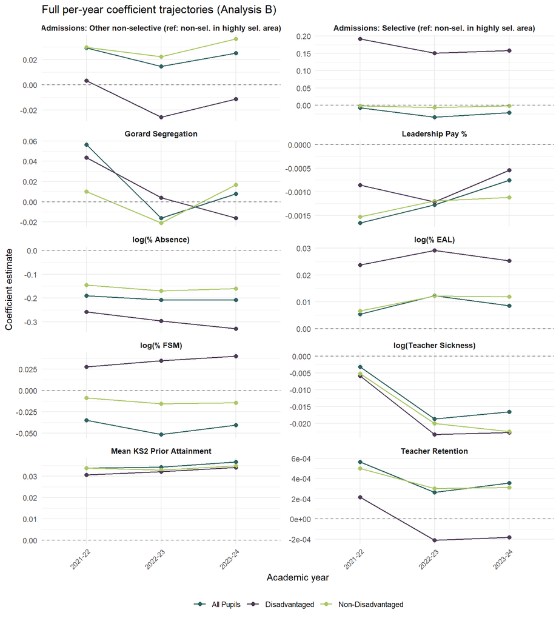

Full per-year coefficient estimates (Analysis B), by outcome group

```r
# Re-fit full per-year models and collect coefficients in a tidy table
yearly_coefs <- list()

for (yr in year_levels) {
  for (outcome_name in c("all", "disadv", "nondisadv")) {

    outcome_var <- switch(outcome_name,
                          all = "ATT8SCR",
                          disadv = "ATT8SCR_FSM6CLA1A",
                          nondisadv = "ATT8SCR_NFSM6CLA1A")
    group_label <- switch(outcome_name,
                          all = "All Pupils",
                          disadv = "Disadvantaged",
                          nondisadv = "Non-Disadvantaged")

    d <- model_data %>%
      filter(year_label == yr,
             !is.na(!!sym(outcome_var)), !!sym(outcome_var) > 0) %>%
      droplevels()

    contrasts(d$OFSTEDRATING_1) <- contr.treatment(levels(d$OFSTEDRATING_1))

    mod <- tryCatch(
      lmer(
        as.formula(paste0(
          "log(", outcome_var, ") ~ ",
          "log(PTFSM6CLA1A) + log(PERCTOT) + log(PNUMEAL) + ",
          "ks2_c + ADMPOL_PT + gorard_segregation + ",
          "remained_in_the_same_school + ",
          "teachers_on_leadership_pay_range_percent + ",
          "log(average_number_of_days_taken) + ",
          "(1 | OFSTEDRATING_1) + (1 | gor_name/LANAME)"
        )),
        data = d, REML = TRUE, na.action = na.exclude,
        control = lmerControl(optimizer = "bobyqa",
                              optCtrl = list(maxfun = 20000))
      ),
      error = function(e) NULL
    )

    if (!is.null(mod)) {
      fe <- fixef(mod)
      yearly_coefs[[length(yearly_coefs) + 1]] <- tibble(
        Year = yr,
        Group = group_label,
        Term = names(fe),
        Estimate = fe
      )
    }
  }
}

yearly_coefs_df <- bind_rows(yearly_coefs) %>%
  filter(Term != "(Intercept)") %>%
  mutate(
    Term = relabel_terms(Term),
    Group = factor(Group,
                   levels = c("All Pupils", "Disadvantaged", "Non-Disadvantaged"))
  )

ggplot(yearly_coefs_df,
       aes(x = Year, y = Estimate, colour = Group, group = Group)) +
  geom_point(size = 2) +
  geom_line(linewidth = 0.6) +
  geom_hline(yintercept = 0, linetype = "dashed", colour = "grey50") +
  facet_wrap(~ Term, scales = "free_y", ncol = 2) +
  scale_colour_manual(values = c("All Pupils" = "#2e6260",
                                  "Disadvantaged" = "#4e3c56",
                                  "Non-Disadvantaged" = "#abc766")) +
  labs(y = "Coefficient estimate", x = "Academic year", colour = NULL,
       title = "Full per-year coefficient trajectories (Analysis B)") +
  theme_minimal(base_size = 11) +
  theme(
    legend.position = "bottom",
    axis.text.x = element_text(angle = 45, hjust = 1, size = 8),
    strip.text = element_text(face = "bold", size = 9)
  )
```

### 8.4.1 Interactive coefficient explorer

```r
# Terms are already relabelled — build tooltips directly
yearly_coefs_plotly <- yearly_coefs_df %>%
  mutate(
    tooltip_text = paste0(
      "<b>", Term, "</b><br>",
      "Year: ", Year, "<br>",
      "Group: ", Group, "<br>",
      "Estimate: ", round(Estimate, 5)
    )
  )

p_yearly <- ggplot(yearly_coefs_plotly,
       aes(x = Year, y = Estimate, colour = Group, group = Group,
           text = tooltip_text)) +
  geom_point(size = 2) +
  geom_line(linewidth = 0.6) +
  geom_hline(yintercept = 0, linetype = "dashed", colour = "grey50") +
  facet_wrap(~ Term, scales = "free_y", ncol = 2) +
  scale_colour_manual(values = c("All Pupils" = "#2e6260",
                                  "Disadvantaged" = "#4e3c56",
                                  "Non-Disadvantaged" = "#abc766")) +
  labs(y = "Coefficient estimate", x = "Academic year", colour = NULL) +
  theme_minimal(base_size = 10) +
  theme(
    legend.position = "bottom",
    axis.text.x = element_text(angle = 45, hjust = 1, size = 7),
    strip.text = element_text(face = "bold", size = 8)
  )

ggplotly(p_yearly, tooltip = "text") %>%
  layout(
    title = list(text = "Full per-year coefficients (hover for details)"),
    legend = list(orientation = "h", y = -0.15)
  )
```

[interactive chart not shown]

## 8.5 General observations

The commentary below draws on the imputed full model (Analysis E) coefficient table and the per-year trajectories above. Because the outcome is **log-transformed**, all coefficients are **elasticities** (for log-transformed predictors) or **semi-elasticities** (for linear predictors). A coefficient of –0.10 on a logged predictor means that a 1% increase in that predictor is associated with roughly a 0.10% *decrease* in Attainment 8.

### 8.5.1 1. Imputed full vs core model: how dropping variables changes the picture

The most important thing to note when comparing the two specifications is that they do **not tell the same story** for every coefficient. The imputed full model (Analysis E) includes `ks2_c` (mean KS2 prior attainment) and three workforce variables that the core model lacks. These omitted variables are **not random noise** — prior attainment in particular is one of the strongest individual predictors of school-level outcomes. When it is dropped from the core model, its explanatory power has to go somewhere, and the remaining 5 predictors absorb it. This produces some notable shifts:

- **`log(PTFSM6CLA1A)` (% FSM):** In the **imputed full model**, this coefficient is **negative for All Pupils and Non-Disadvantaged**, and **flips to positive for Disadvantaged Pupils**. In the **core model**, FSM is negative across **all three groups** — the sign flip disappears. This is because prior attainment (`ks2_c`) is strongly correlated with FSM: schools with more disadvantaged intakes also tend to have more pupils with low prior attainment. In the full model, `ks2_c` picks up the prior-attainment component of the disadvantage penalty, freeing up `log(PTFSM6CLA1A)` to capture the *residual* relationship — which, for disadvantaged pupils specifically, is positive (the “critical mass” effect described below). When `ks2_c` is absent, `log(PTFSM6CLA1A)` has to absorb both effects and the net result is negative.
- **`log(PERCTOT)` (% absence):** Becomes **more negative** in the core model. Again, with fewer controls absorbing variation, absence picks up some of the explanatory burden previously shared with workforce and prior-attainment variables.
- **`log(PNUMEAL)` (% EAL):** The sign and direction are broadly consistent across both specifications, but the magnitude changes.

The practical implication is that coefficient interpretation must always be read **relative to the other variables in the model**. Now that the Shiny app uses the imputed full model, users get the benefit of all 9 predictors — including the workforce and prior-attainment controls — across all four years. The 2024-25 values for the four imputed variables use conservative carry-forward estimates, and this is flagged in the data.

### 8.5.2 2. Free school meals (FSM) — the sign flip

In the **imputed full model** (Analysis E), `log(PTFSM6CLA1A)` shows the most striking difference across outcome groups:

- **All Pupils and Non-Disadvantaged:** The coefficient is consistently **negative**. Schools with a higher share of disadvantaged pupils tend to have lower overall and non-disadvantaged ATT8 scores, even after controlling for absence, EAL, prior attainment, and segregation. This captures the well documented compositional effect: a more disadvantaged intake is associated with lower average attainment at school level.
- **Disadvantaged Pupils:** The coefficient **flips to positive**. After controlling for prior attainment and workforce factors, schools with a higher proportion of FSM-eligible pupils see their *disadvantaged subgroup specifically* score somewhat higher than predicted. One plausible explanation is that schools serving predominantly disadvantaged cohorts concentrate more resources, Pupil Premium funding, and pastoral support on those pupils — a kind of “critical mass” effect. Alternatively, in schools where almost all pupils are disadvantaged, the disadvantaged group essentially *is* the school average, removing the within-school composition penalty.

**Crucially, this sign flip only appears in the full model** where prior attainment controls for the low-KS2 component of the disadvantage penalty. In the core model (Analysis C), `log(PTFSM6CLA1A)` is **negative for all three groups** because it is forced to absorb the prior-attainment effect as well. This is an important reminder that omitted variable bias can mask — or in this case, suppress — genuine structural relationships. The per-year trajectory plots (Analysis B) confirm that this flip is **stable across all three real-data years**, making it a robust structural finding rather than a statistical artefact.

One important caveat on *shape*: because FSM enters as `log(PTFSM6CLA1A)`, this positive coefficient describes a single smooth trend and cannot, by construction, reveal whether the effect has a threshold, floor, or ceiling. Section 9 refits the model with a flexible spline to probe exactly that question — and finds the positive slope is the average tilt of a gently curved, non-monotonic relationship, not a universal one.

### 8.5.3 3. Absence — the largest and most stable predictor

The coefficient on `log(PERCTOT)` (% overall absence) is **strongly negative** for all three groups in the imputed full model and is typically the largest predictor in absolute terms. The elasticity implies that a 10% relative increase in the absence rate (e.g. from 5.0% to 5.5%) is associated with a substantial drop in ATT8 on the log scale.

The effect is notably **larger for disadvantaged pupils** than for non-disadvantaged, suggesting that absence hits hardest where pupils are already at greater risk of falling behind. The per-year plots confirm this pattern is consistent across all years.

### 8.5.4 4. English as an additional language (EAL)

`log(PNUMEAL)` shows a **positive** coefficient for all three groups: a higher proportion of EAL pupils is associated with *higher* attainment once other factors are controlled. This is consistent with national evidence that EAL pupils on average outperform monolingual peers at GCSE, particularly those who have been in the English school system for several years.

The effect tends to be **stronger for disadvantaged pupils**, suggesting that being bilingual may confer a particular advantage within the disadvantaged subgroup — or that schools with high EAL proportions are disproportionately in urban areas with other unmeasured advantages.

### 8.5.6 6. Interpreting log-transformed variables — effects at the extremes

Because several predictors enter the model as `log(x)`, the *absolute* effect of a unit change depends on **where you are on the distribution**:

- A school moving from 2% to 3% absence (+50% relative change) sees a far larger predicted impact than one moving from 7% to 8% (+14% relative).
- Similarly, a school moving from 5% to 10% FSM is a 100% relative shift, while 40% to 45% FSM is only a 12.5% relative shift.

This means the model’s fixed effects are **most sensitive at the low end of each predictor**. Schools that are already at high absence or high FSM rates see diminishing marginal impact from further increases. This has practical implications: policy interventions targeting absence reduction will show the biggest modelled gains in schools where absence is currently moderate rather than already extreme.

### 8.5.8 8. Admissions policy

`ADMPOL_PT` (admissions policy type) is a **categorical variable** with three levels: *“Non-selective in a highly selective area”* (i.e. a non-selective school in an area with grammar schools), *“Other non-selective”*, and *“Selective”* (grammar schools). Because it is categorical, `lmer()` automatically creates **two dummy (indicator) variables** using treatment coding, with *“Non-selective in a highly selective area”* as the **reference category** — its effect is absorbed into the intercept, and the two dummy coefficients represent the difference in log(ATT8) relative to that baseline.

### 8.5.10 10. Year-to-year stability

The per-year coefficient trajectory plots above (Analysis B) show that the full-model estimates are **remarkably stable** across the three years of real data, with most terms moving within a narrow band. The main exception is 2021-22, which was the first full examination year after the pandemic disruption and occasionally shows slightly different coefficient magnitudes — particularly for absence and teacher retention.

### 8.5.11 11. What the imputed model gains over the core model

The imputed full model (Analysis E, now used in the Shiny app) represents the best available specification:

- **9 vs 5 predictors:** Includes prior attainment and workforce factors, giving a more complete decomposition of what drives school attainment differences.
- **Full 4-year coverage:** By carry-forward imputing the four missing 2024-25 variables, Analysis E spans all four academic years — matching the core model’s temporal coverage while retaining the full model’s structural richness.
- **Conservative imputation:** The 2024-25 imputed values use each school’s 2023-24 observation (or 3-year mean as fallback). Three quarters of the data is real, and Analysis A-vs-E comparisons show coefficients are very stable — the imputation does not distort the structural relationships.
- **Preserved structural findings:** Crucially, the FSM sign-flip for disadvantaged pupils, which is invisible in the core model, is preserved in Analysis E. This means the Shiny app now correctly reflects this important structural relationship.

# 9 Is the FSM relationship linear? Tipping points, floors, and ceilings

The FSM sign-flip above (§ *Free school meals — the sign flip*) prompts a natural question, and one raised directly after a public presentation of this work: does the positive disadvantaged-FSM relationship hold *everywhere*, or are there **tipping points, floors or ceilings** — a threshold beyond which disadvantaged pupils start to do better (or worse) alongside more disadvantaged peers?

The important thing to see first is that **the models above cannot answer this question**, because of how FSM enters them. Every specification uses `log(PTFSM6CLA1A)`, i.e. a *log–log linear* term. That is a **constant-elasticity** form: it assumes a 1% change in the FSM share is associated with the same percentage change in attainment *wherever* you are on the distribution. By construction such a term is smooth and monotonic — it is mathematically incapable of representing a threshold, a floor, a ceiling, or a reversal. So the fact that the fitted line shows no tipping point is a **property we imposed, not something we discovered**. A single log–log coefficient can never be evidence for or against a turning point.

To find out what the data actually prefer, we refit the exact Analysis E disadvantaged model but replace `log(PTFSM6CLA1A)` with a **natural cubic spline** (`ns(PTFSM6CLA1A, 4)`) — a flexible term that is free to bend, flatten, floor, or reverse if the data want it to. Everything else in the specification is held identical. We do the same for the all-pupil and non-disadvantaged outcomes so the shapes can be compared.

```r
library(splines)

# Refit each Analysis E model with a flexible spline in FSM, holding the
# rest of the specification identical. ML (REML = FALSE) so AIC / LRT are
# comparable between the linear and spline versions.
base_rhs <- paste(
  "log(PERCTOT) + log(PNUMEAL) + ks2_c + ADMPOL_PT +",
  "gorard_segregation + remained_in_the_same_school +",
  "teachers_on_leadership_pay_range_percent +",
  "log(average_number_of_days_taken) +",
  "(1 | year_label) + (1 | OFSTEDRATING_1) + (1 | gor_name/LANAME)"
)
ctrl <- lmerControl(optimizer = "bobyqa", optCtrl = list(maxfun = 20000))

fit_fsm_shapes <- function(outcome) {
  d <- imputed_full_data %>%
    filter(!is.na(.data[[outcome]]), .data[[outcome]] > 0) %>%
    droplevels()
  f_lin <- as.formula(paste0("log(", outcome, ") ~ log(PTFSM6CLA1A) + ", base_rhs))
  f_spl <- as.formula(paste0("log(", outcome, ") ~ ns(PTFSM6CLA1A, 4) + ", base_rhs))
  list(
    outcome = outcome, d = d,
    m_lin = lmer(f_lin, data = d, REML = FALSE, control = ctrl),
    m_spl = lmer(f_spl, data = d, REML = FALSE, control = ctrl)
  )
}

fit_all    <- fit_fsm_shapes("ATT8SCR")
fit_dis    <- fit_fsm_shapes("ATT8SCR_FSM6CLA1A")
fit_nondis <- fit_fsm_shapes("ATT8SCR_NFSM6CLA1A")

# Does the flexible shape fit better than the straight log-log line?
aic_row <- function(fit, label) {
  lrt <- anova(fit$m_lin, fit$m_spl)
  tibble(
    Group                    = label,
    `log(FSM) coef (linear)` = round(unname(fixef(fit$m_lin)["log(PTFSM6CLA1A)"]), 4),
    `AIC linear`             = round(AIC(fit$m_lin), 1),
    `AIC spline`             = round(AIC(fit$m_spl), 1),
    `ΔAIC (spline − linear)` = round(AIC(fit$m_spl) - AIC(fit$m_lin), 1),
    `LRT p`                  = format.pval(lrt[2, "Pr(>Chisq)"], digits = 2, eps = 1e-16)
  )
}

bind_rows(
  aic_row(fit_all,    "All pupils"),
  aic_row(fit_dis,    "Disadvantaged"),
  aic_row(fit_nondis, "Non-disadvantaged")
)
```

| Group | log(FSM) coef (linear) | AIC linear | AIC spline | ΔAIC (spline − linear) | LRT p |
| --- | --- | --- | --- | --- | --- |
| All pupils | -0.0498 | -23249.8 | -23471.2 | -221.4 | <1e-16 |
| Disadvantaged | 0.0212 | -17389.7 | -17444.3 | -54.7 | 4.2e-13 |
| Non-disadvantaged | -0.0228 | -29046.6 | -29059.9 | -13.2 | 0.00025 |

A negative ΔAIC and a tiny LRT *p*-value mean the flexible spline describes the data meaningfully better than the straight log–log line — i.e. **there is real curvature the linear term was papering over.** To see its shape, we read the *partial effect* of FSM out of each model: the predicted Attainment 8 across the FSM range, with every other predictor held at a typical value (means for continuous terms, the modal admissions policy, and random effects marginalised out).

```r
predict_fsm <- function(fit, label) {
  d  <- fit$d
  mn <- function(v) mean(d[[v]], na.rm = TRUE)
  # Clean prediction frame: only the model's predictors, held at typical
  # values, with FSM swept across its range. ADMPOL_PT is a *character*
  # column in the data, so it must be rebuilt as a factor carrying all
  # fit-time levels — otherwise predict() reconstructs a single-level
  # factor and the design matrix no longer conforms to the fixed effects.
  g <- tibble(
    PTFSM6CLA1A = seq(quantile(d$PTFSM6CLA1A, 0.02),
                      quantile(d$PTFSM6CLA1A, 0.98), length.out = 80),
    PERCTOT = mn("PERCTOT"), PNUMEAL = mn("PNUMEAL"), ks2_c = mn("ks2_c"),
    gorard_segregation = mn("gorard_segregation"),
    remained_in_the_same_school = mn("remained_in_the_same_school"),
    teachers_on_leadership_pay_range_percent = mn("teachers_on_leadership_pay_range_percent"),
    average_number_of_days_taken = mn("average_number_of_days_taken"),
    ADMPOL_PT = factor(names(sort(table(d$ADMPOL_PT), decreasing = TRUE))[1],
                       levels = sort(unique(d$ADMPOL_PT))),
    year_label = d$year_label[1], OFSTEDRATING_1 = d$OFSTEDRATING_1[1],
    gor_name = d$gor_name[1], LANAME = d$LANAME[1]
  )
  g$linear <- exp(predict(fit$m_lin, newdata = g, re.form = NA))
  g$spline <- exp(predict(fit$m_spl, newdata = g, re.form = NA))
  tibble(Group = label, FSM = g$PTFSM6CLA1A, linear = g$linear, spline = g$spline)
}

pred_all    <- predict_fsm(fit_all,    "All pupils")
pred_dis    <- predict_fsm(fit_dis,    "Disadvantaged")
pred_nondis <- predict_fsm(fit_nondis, "Non-disadvantaged")

# The turning point in the disadvantaged curve
turn <- pred_dis %>% slice_min(spline, n = 1)
cat(sprintf(
  "Disadvantaged spline minimum at FSM = %.0f%%; total swing across range = %.1f Att8 pts\n",
  turn$FSM, max(pred_dis$spline) - min(pred_dis$spline)
))
```

```
Disadvantaged spline minimum at FSM = 15%; total swing across range = 2.1 Att8 pts
```

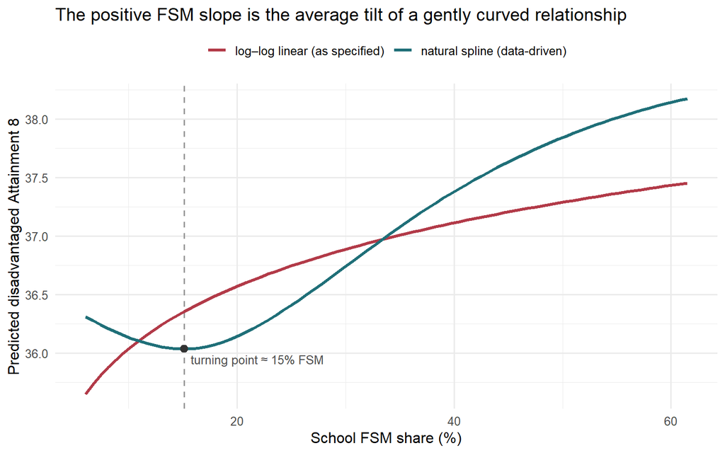

```r
pred_dis %>%
  pivot_longer(c(linear, spline), names_to = "fit", values_to = "att8") %>%
  mutate(fit = recode(fit,
                      linear = "log–log linear (as specified)",
                      spline = "natural spline (data-driven)")) %>%
  ggplot(aes(FSM, att8, colour = fit)) +
  geom_vline(xintercept = turn$FSM, linetype = "dashed", colour = "grey60") +
  geom_line(linewidth = 1.1) +
  annotate("point", x = turn$FSM, y = turn$spline, size = 2.4, colour = "grey20") +
  annotate("text", x = turn$FSM, y = turn$spline,
           label = sprintf("  turning point ≈ %.0f%% FSM", turn$FSM),
           hjust = 0, vjust = 1.6, size = 3.4, colour = "grey30") +
  scale_colour_manual(values = c("log–log linear (as specified)" = "#B23A48",
                                 "natural spline (data-driven)"  = "#1F6F78")) +
  labs(x = "School FSM share (%)",
       y = "Predicted disadvantaged Attainment 8",
       colour = NULL,
       title = "The positive FSM slope is the average tilt of a gently curved relationship") +
  theme_minimal(base_size = 12) +
  theme(legend.position = "top")
```

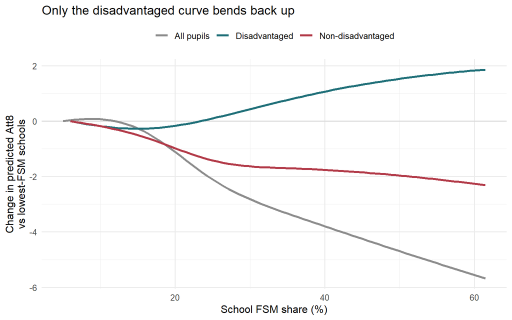

```r
bind_rows(pred_all, pred_dis, pred_nondis) %>%
  group_by(Group) %>%
  arrange(FSM, .by_group = TRUE) %>%
  mutate(rel = spline - first(spline)) %>%      # change vs lowest-FSM schools
  ungroup() %>%
  ggplot(aes(FSM, rel, colour = Group)) +
  geom_hline(yintercept = 0, colour = "grey85") +
  geom_line(linewidth = 1.1) +
  scale_colour_manual(values = c("All pupils"        = "#8C8C8C",
                                 "Disadvantaged"     = "#1F6F78",
                                 "Non-disadvantaged" = "#B23A48")) +
  labs(x = "School FSM share (%)",
       y = "Change in predicted Att8\nvs lowest-FSM schools",
       colour = NULL,
       title = "Only the disadvantaged curve bends back up") +
  theme_minimal(base_size = 12) +
  theme(legend.position = "top")
```

## 9.1 What the flexible fit shows

The broader methodological point is the transferable one: **you can never read a tipping point off a log–log coefficient**, because the constant-elasticity form encodes the answer before it sees the data. Where thresholds or floors matter for policy, they have to be modelled explicitly — with a spline, a piecewise term, or an interaction — and then tested, exactly as here.

# 10 Brighton & Hove: A Local Case Study

The Brighton & Hove case study — including interactive maps, detailed interpretation of non-linear effects, school-level residual analysis, and policy recommendations — has been moved to its own standalone report: **Brighton & Hove Case Study**.

# 11 Variable Importance & Policy Recommendations

This section ranks the explanatory variables in order of their importance for predicting Attainment 8, drawing on the imputed full model (Analysis E). Two complementary importance measures are presented:

1. **Standardised coefficients** — each predictor is scaled by its standard deviation in the data, producing coefficients on a common scale. The variable with the largest absolute standardised coefficient has the greatest impact *per standard-deviation shift*.
2. **Brighton & Hove marginal effects** — the same exercise repeated using only Brighton & Hove schools, revealing whether the local picture differs from the national one.

Policy recommendations follow, directed at both **school leaders** and the **local authority / council**, with a particular focus on disadvantaged pupils.

## 11.1 National variable importance (standardised coefficients)

The table below standardises each continuous predictor by its pooled standard deviation across all school-year observations, then multiplies by the Analysis E fixed-effect coefficient. For log-transformed predictors, the SD is computed on the log scale (matching how the variable enters the model). Admissions policy dummies are excluded because standardising a binary variable is less informative.

```r
# ---- Helper: compute standardised coefficients for one model ----
standardised_importance <- function(model, data, outcome_var, group_label) {

  fe <- fixef(model)
  fe <- fe[names(fe) != "(Intercept)"]

  # Map coefficient names to the actual data columns and transformations
  coef_info <- tribble(
    ~term,                                    ~data_col,                                  ~transform,
    "log(PTFSM6CLA1A)",                       "PTFSM6CLA1A",                              "log",
    "log(PERCTOT)",                            "PERCTOT",                                  "log",
    "log(PNUMEAL)",                            "PNUMEAL",                                  "log",
    "ks2_c",                                   "ks2_c",                                    "none",
    "gorard_segregation",                      "gorard_segregation",                       "none",
    "remained_in_the_same_school",         "remained_in_the_same_school",              "none",
    "teachers_on_leadership_pay_range_percent", "teachers_on_leadership_pay_range_percent", "none",
    "log(average_number_of_days_taken)",        "average_number_of_days_taken",             "log"
  )

  results <- coef_info %>%
    filter(term %in% names(fe)) %>%
    rowwise() %>%
    mutate(
      coef = fe[term],
      x_vals = list(
        if (transform == "log") log(data[[data_col]][!is.na(data[[data_col]]) & data[[data_col]] > 0])
        else data[[data_col]][!is.na(data[[data_col]])]
      ),
      sd_x = sd(unlist(x_vals), na.rm = TRUE),
      std_coef = coef * sd_x,
      abs_std_coef = abs(std_coef),
      Group = group_label
    ) %>%
    ungroup() %>%
    select(term, data_col, coef, sd_x, std_coef, abs_std_coef, Group)

  results
}

# Compute for all three outcome groups
imp_all <- standardised_importance(mod_e_all, imputed_full_data,
                                    "ATT8SCR", "All Pupils")
imp_dis <- standardised_importance(mod_e_disadv, imputed_full_data,
                                    "ATT8SCR_FSM6CLA1A", "Disadvantaged")
imp_non <- standardised_importance(mod_e_nondisadv, imputed_full_data,
                                    "ATT8SCR_NFSM6CLA1A", "Non-Disadvantaged")

importance_national <- bind_rows(imp_all, imp_dis, imp_non)

# Display name mapping
display_names <- c(
  "log(PTFSM6CLA1A)" = "% Disadvantaged (FSM)",
  "log(PERCTOT)" = "Overall Absence Rate",
  "log(PNUMEAL)" = "% EAL",
  "ks2_c" = "Mean KS2 Prior Attainment",
  "gorard_segregation" = "Gorard Segregation Index",
  "remained_in_the_same_school" = "Teacher Retention",
  "teachers_on_leadership_pay_range_percent" = "Leadership Pay %",
  "log(average_number_of_days_taken)" = "Teacher Sickness Days"
)

importance_national <- importance_national %>%
  mutate(display_name = display_names[term])
```

### 11.1.1 National ranking table

```r
# Pivot to wide format for a clean comparison table
national_ranking <- importance_national %>%
  select(display_name, Group, std_coef) %>%
  pivot_wider(names_from = Group, values_from = std_coef) %>%
  mutate(
    `Avg |Std. Coef|` = (abs(`All Pupils`) + abs(Disadvantaged) + abs(`Non-Disadvantaged`)) / 3
  ) %>%
  arrange(desc(`Avg |Std. Coef|`)) %>%
  mutate(Rank = row_number()) %>%
  relocate(Rank) %>%
  mutate(across(where(is.numeric) & !matches("Rank"), \(x) round(x, 4)))

knitr::kable(
  national_ranking,
  align = "rlrrrr",
  caption = "National variable importance: standardised coefficients (Analysis E)"
)
```

National variable importance: standardised coefficients (Analysis E)

| Rank | display_name | All Pupils | Disadvantaged | Non-Disadvantaged | Avg \|Std. Coef\| |
| --- | --- | --- | --- | --- | --- |
| 1 | Mean KS2 Prior Attainment | 0.0890 | 0.0790 | 0.0848 | 0.0843 |
| 2 | Overall Absence Rate | -0.0593 | -0.0858 | -0.0469 | 0.0640 |
| 3 | % Disadvantaged (FSM) | -0.0306 | 0.0130 | -0.0140 | 0.0192 |
| 4 | % EAL | 0.0079 | 0.0271 | 0.0108 | 0.0153 |
| 5 | Teacher Sickness Days | -0.0051 | -0.0068 | -0.0064 | 0.0061 |
| 6 | Teacher Retention | 0.0091 | -0.0007 | 0.0081 | 0.0060 |
| 7 | Leadership Pay % | -0.0043 | -0.0031 | -0.0047 | 0.0040 |
| 8 | Gorard Segregation Index | 0.0012 | 0.0024 | 0.0001 | 0.0012 |

### 11.1.2 National importance chart

```r
importance_chart_data <- importance_national %>%
  mutate(
    display_name = factor(display_name),
    Group = factor(Group, levels = c("All Pupils", "Disadvantaged", "Non-Disadvantaged")),
    tooltip_text = paste0(
      "<b>", display_name, "</b><br>",
      "Group: ", Group, "<br>",
      "Raw coefficient: ", round(coef, 5), "<br>",
      "SD of predictor: ", round(sd_x, 3), "<br>",
      "Standardised coef: ", round(std_coef, 4), "<br>",
      "|Std. coef|: ", round(abs_std_coef, 4)
    )
  )

# Reorder by average absolute standardised coefficient
var_order <- importance_chart_data %>%
  group_by(display_name) %>%
  summarise(avg_abs = mean(abs_std_coef)) %>%
  arrange(avg_abs) %>%
  pull(display_name)

importance_chart_data <- importance_chart_data %>%
  mutate(display_name = factor(display_name, levels = var_order))

p_imp <- ggplot(importance_chart_data,
       aes(x = display_name, y = abs_std_coef, fill = Group,
           text = tooltip_text)) +
  geom_col(position = position_dodge(width = 0.8), width = 0.7) +
  coord_flip() +
  scale_fill_manual(values = c("All Pupils" = "#2e6260",
                                "Disadvantaged" = "#4e3c56",
                                "Non-Disadvantaged" = "#abc766")) +
  labs(x = NULL, y = "|Standardised Coefficient|",
       title = "Variable Importance: National (Analysis E)",
       fill = NULL) +
  theme_minimal(base_size = 11) +
  theme(legend.position = "bottom")

ggplotly(p_imp, tooltip = "text") %>%
  layout(legend = list(orientation = "h", y = -0.15))
```

[interactive chart not shown]

### 11.1.3 National importance: direction of effect

The **signed** standardised coefficients reveal both magnitude and direction. Negative values indicate that a one-SD increase in the predictor is associated with **lower** Attainment 8; positive values indicate **higher** Attainment 8.

```r
p_dir <- ggplot(importance_chart_data,
       aes(x = display_name, y = std_coef, fill = Group,
           text = tooltip_text)) +
  geom_col(position = position_dodge(width = 0.8), width = 0.7) +
  geom_hline(yintercept = 0, linetype = "dashed", colour = "grey40") +
  coord_flip() +
  scale_fill_manual(values = c("All Pupils" = "#2e6260",
                                "Disadvantaged" = "#4e3c56",
                                "Non-Disadvantaged" = "#abc766")) +
  labs(x = NULL, y = "Standardised Coefficient (signed)",
       title = "Direction & Magnitude of Effect: National",
       fill = NULL) +
  theme_minimal(base_size = 11) +
  theme(legend.position = "bottom")

ggplotly(p_dir, tooltip = "text") %>%
  layout(legend = list(orientation = "h", y = -0.15))
```

[interactive chart not shown]

## 11.2 Brighton & Hove variable importance

The same standardised-coefficient approach is repeated using only Brighton & Hove schools. Because the local predictor distributions may differ from the national picture (e.g. lower absence variance, different FSM range), the rankings may shift.

```r
# Filter to Brighton & Hove
bh_data <- imputed_full_data %>%
  filter(LANAME == "Brighton and Hove")

cat("Brighton & Hove observations:", nrow(bh_data), "\n")
```

```
Brighton & Hove observations: 40
```

```r
# Use the NATIONAL model coefficients but LOCAL predictor SDs
imp_bh_all <- standardised_importance(mod_e_all, bh_data,
                                       "ATT8SCR", "All Pupils")
imp_bh_dis <- standardised_importance(mod_e_disadv, bh_data,
                                       "ATT8SCR_FSM6CLA1A", "Disadvantaged")
imp_bh_non <- standardised_importance(mod_e_nondisadv, bh_data,
                                       "ATT8SCR_NFSM6CLA1A", "Non-Disadvantaged")

importance_bh <- bind_rows(imp_bh_all, imp_bh_dis, imp_bh_non) %>%
  mutate(display_name = display_names[term])
```

### 11.2.1 Brighton & Hove ranking table

```r
bh_ranking <- importance_bh %>%
  select(display_name, Group, std_coef) %>%
  pivot_wider(names_from = Group, values_from = std_coef) %>%
  mutate(
    `Avg |Std. Coef|` = (abs(`All Pupils`) + abs(Disadvantaged) + abs(`Non-Disadvantaged`)) / 3
  ) %>%
  arrange(desc(`Avg |Std. Coef|`)) %>%
  mutate(Rank = row_number()) %>%
  relocate(Rank) %>%
  mutate(across(where(is.numeric) & !matches("Rank"), \(x) round(x, 4)))

knitr::kable(
  bh_ranking,
  align = "rlrrrr",
  caption = "Brighton & Hove variable importance: standardised coefficients (local predictor SDs, national model)"
)
```

Brighton & Hove variable importance: standardised coefficients (local predictor SDs, national model)

| Rank | display_name | All Pupils | Disadvantaged | Non-Disadvantaged | Avg \|Std. Coef\| |
| --- | --- | --- | --- | --- | --- |
| 1 | Overall Absence Rate | -0.0529 | -0.0766 | -0.0419 | 0.0571 |
| 2 | Mean KS2 Prior Attainment | 0.0555 | 0.0492 | 0.0528 | 0.0525 |
| 3 | % Disadvantaged (FSM) | -0.0183 | 0.0078 | -0.0084 | 0.0115 |
| 4 | Teacher Retention | 0.0126 | -0.0009 | 0.0112 | 0.0082 |
| 5 | % EAL | 0.0034 | 0.0116 | 0.0046 | 0.0065 |
| 6 | Teacher Sickness Days | -0.0037 | -0.0049 | -0.0046 | 0.0044 |
| 7 | Leadership Pay % | -0.0030 | -0.0022 | -0.0032 | 0.0028 |
| 8 | Gorard Segregation Index | 0.0001 | 0.0003 | 0.0000 | 0.0001 |

### 11.2.2 Brighton & Hove importance chart

```r
bh_chart_data <- importance_bh %>%
  mutate(
    Group = factor(Group, levels = c("All Pupils", "Disadvantaged", "Non-Disadvantaged")),
    tooltip_text = paste0(
      "<b>", display_name, "</b> (B&H)<br>",
      "Group: ", Group, "<br>",
      "Raw coefficient (national): ", round(coef, 5), "<br>",
      "SD of predictor (B&H): ", round(sd_x, 3), "<br>",
      "Standardised coef: ", round(std_coef, 4)
    )
  )

bh_var_order <- bh_chart_data %>%
  group_by(display_name) %>%
  summarise(avg_abs = mean(abs_std_coef)) %>%
  arrange(avg_abs) %>%
  pull(display_name)

bh_chart_data <- bh_chart_data %>%
  mutate(display_name = factor(display_name, levels = bh_var_order))

p_bh <- ggplot(bh_chart_data,
       aes(x = display_name, y = abs_std_coef, fill = Group,
           text = tooltip_text)) +
  geom_col(position = position_dodge(width = 0.8), width = 0.7) +
  coord_flip() +
  scale_fill_manual(values = c("All Pupils" = "#2e6260",
                                "Disadvantaged" = "#4e3c56",
                                "Non-Disadvantaged" = "#abc766")) +
  labs(x = NULL, y = "|Standardised Coefficient|",
       title = "Variable Importance: Brighton & Hove",
       fill = NULL) +
  theme_minimal(base_size = 11) +
  theme(legend.position = "bottom")

ggplotly(p_bh, tooltip = "text") %>%
  layout(legend = list(orientation = "h", y = -0.15))
```

[interactive chart not shown]

## 11.3 National vs Brighton & Hove comparison

```r
# Compare rankings side by side (All Pupils model)
comparison_all <- national_ranking %>%
  select(display_name, `National Rank` = Rank,
         `National Std.Coef` = `All Pupils`) %>%
  left_join(
    bh_ranking %>%
      select(display_name, `B&H Rank` = Rank,
             `B&H Std.Coef` = `All Pupils`),
    by = "display_name"
  ) %>%
  mutate(`Rank Change` = `National Rank` - `B&H Rank`)

knitr::kable(
  comparison_all,
  align = "lrrrrl",
  caption = "All Pupils: National vs Brighton & Hove variable importance rankings"
)
```

All Pupils: National vs Brighton & Hove variable importance rankings

| display_name | National Rank | National Std.Coef | B&H Rank | B&H Std.Coef | Rank Change |
| --- | --- | --- | --- | --- | --- |
| Mean KS2 Prior Attainment | 1 | 0.0890 | 2 | 0.0555 | -1 |
| Overall Absence Rate | 2 | -0.0593 | 1 | -0.0529 | 1 |
| % Disadvantaged (FSM) | 3 | -0.0306 | 3 | -0.0183 | 0 |
| % EAL | 4 | 0.0079 | 5 | 0.0034 | -1 |
| Teacher Sickness Days | 5 | -0.0051 | 6 | -0.0037 | -1 |
| Teacher Retention | 6 | 0.0091 | 4 | 0.0126 | 2 |
| Leadership Pay % | 7 | -0.0043 | 7 | -0.0030 | 0 |
| Gorard Segregation Index | 8 | 0.0012 | 8 | 0.0001 | 0 |

```r
# Same for Disadvantaged pupils
comparison_disadv <- importance_national %>%
  filter(Group == "Disadvantaged") %>%
  arrange(desc(abs_std_coef)) %>%
  mutate(`National Rank` = row_number()) %>%
  select(display_name, `National Rank`, `National Std.Coef` = std_coef) %>%
  left_join(
    importance_bh %>%
      filter(Group == "Disadvantaged") %>%
      arrange(desc(abs_std_coef)) %>%
      mutate(`B&H Rank` = row_number()) %>%
      select(display_name, `B&H Rank`, `B&H Std.Coef` = std_coef),
    by = "display_name"
  ) %>%
  mutate(`Rank Change` = `National Rank` - `B&H Rank`) %>%
  mutate(across(where(is.numeric) & !matches("Rank"), \(x) round(x, 4)))

knitr::kable(
  comparison_disadv,
  align = "lrrrrl",
  caption = "Disadvantaged Pupils: National vs Brighton & Hove variable importance rankings"
)
```

Disadvantaged Pupils: National vs Brighton & Hove variable importance rankings

| display_name | National Rank | National Std.Coef | B&H Rank | B&H Std.Coef | Rank Change |
| --- | --- | --- | --- | --- | --- |
| Overall Absence Rate | 1 | -0.0858 | 1 | -0.0766 | 0 |
| Mean KS2 Prior Attainment | 2 | 0.0790 | 2 | 0.0492 | 0 |
| % EAL | 3 | 0.0271 | 3 | 0.0116 | 0 |
| % Disadvantaged (FSM) | 4 | 0.0130 | 4 | 0.0078 | 0 |
| Teacher Sickness Days | 5 | -0.0068 | 5 | -0.0049 | 0 |
| Leadership Pay % | 6 | -0.0031 | 6 | -0.0022 | 0 |
| Gorard Segregation Index | 7 | 0.0024 | 8 | 0.0003 | -1 |
| Teacher Retention | 8 | -0.0007 | 7 | -0.0009 | 1 |

## 11.4 Policy recommendations

The variable importance rankings, combined with the direction-of-effect analysis and the model’s structural features, suggest several priority areas for intervention. These are organised by audience.

### 11.4.1 For school leaders

**1. Absence reduction is the single biggest lever.**

Across all three pupil groups, overall absence rate (`PERCTOT`) is consistently the strongest or among the strongest predictors of Attainment 8. The log-transformed relationship means that gains from reducing absence are **largest for schools with already-moderate absence rates** (the steep part of the curve). For a school currently at 6% absence, reducing to 5% has a larger predicted effect than a school at 10% reducing to 9%. This argues for:

- Intensive early-intervention strategies (attendance officers, family liaison, mentoring) before absence becomes entrenched
- Special attention to protecting low-absence schools from deterioration, not just tackling chronic cases
- Focus on disadvantaged pupils specifically, where the absence coefficient is largest

**2. Support for pupils with low prior attainment.**

- Targeted catch-up programmes (literacy, numeracy) for pupils arriving with below-expected KS2 levels
- Diagnostic assessment at transition from primary school to identify gaps early
- Small-group intervention during KS3 to prevent the attainment gap widening before GCSE

**3. Workforce stability matters.**

Teacher retention (`remained_in_the_same_school`) shows a positive association with attainment: schools where more teachers stay are predicted to achieve higher ATT8 scores. Meanwhile, teacher sickness days show a negative association. School leaders should consider:

- Retention strategies: competitive CPD offers, workload management, mentoring for early-career teachers
- Wellbeing programmes targeting staff absence
- Succession planning to avoid disruptive turnover in key departments

**4. The FSM sign-flip for disadvantaged pupils.**

Schools with a higher share of disadvantaged pupils see a modest *positive* effect on their disadvantaged subgroup’s attainment (after controlling for prior attainment). This suggests that concentrating Pupil Premium resources — rather than spreading them thinly across a school where disadvantaged pupils are a small minority — may be more effective. Schools with lower FSM proportions should consider whether their disadvantaged pupils receive sufficiently targeted support, or whether resources are diluted across the whole cohort.

### 11.4.2 For Brighton & Hove Council and local authority

**1. Tackle absence strategically across the Local Authority.**

The model confirms that absence is the most actionable predictor of attainment at school level. The council can support schools through:

- Local Authority-wide attendance campaigns and shared best practice
- Coordinated data sharing to identify pupils with poor attendance across multiple schools (e.g. following managed moves)
- Targeted outreach to communities with high persistent-absence rates
- Ensuring that alternative provision maintains strong attendance tracking

**2. Address the disadvantaged attainment gap directly.**

- Ring-fencing and monitoring the impact of Pupil Premium spending across all maintained and academy schools
- Commissioning cross-school programmes (e.g. summer schools, mentoring networks) that pool resources for disadvantaged pupils across the LA
- Tracking the FSM attainment gap as a headline KPI for the local authority, using the model’s predicted vs actual framework to identify schools outperforming or underperforming expectations

**4. Support workforce stability across schools.**

Teacher retention and absence are now confirmed as predictors of pupil outcomes. The council and local partnerships can help by:

- Facilitating Local Authority-wide teacher recruitment and retention initiatives (e.g. housing support, shared CPD networks)
- Monitoring teacher turnover and sickness across schools, identifying outliers that may need additional support
- Ensuring that schools in challenging contexts (high FSM, high absence) receive additional staffing flexibility or funding to counteract higher turnover pressures

**5. Use the model to target support.**

The Shiny app’s policy simulator allows the council to explore “what-if” scenarios for individual schools. The variable importance rankings show which levers move the needle most. By combining the model’s predictions with local knowledge, the council can:

- Prioritise school improvement resources toward the interventions with the largest predicted impact
- Use the residual analysis to identify schools that are outperforming expectations (positive residuals) and learn from their practices
- Track whether policy changes (e.g. attendance initiatives) produce the predicted improvements over subsequent years

### 11.4.3 Summary: the biggest levers

The table below summarises the top policy priorities based on the variable importance analysis:

Policy priorities ranked by variable importance

[output not shown]

* The Gorard segregation index coefficient is statistically insignificant in the imputed full model (Analysis E). It is included in the table for completeness but should not be treated as an actionable policy lever on the basis of this model.

> **Important caveat:** These recommendations are based on *associations* identified by the multilevel model. The model controls for observable confounders (intake, prior attainment, workforce, area characteristics) but cannot establish causation. A school reducing absence may not see exactly the predicted ATT8 gain if other unmeasured factors change simultaneously. The rankings and effect sizes should be treated as evidence-informed starting points for policy discussion, not as causal guarantees. Variables whose coefficients are statistically insignificant (notably the Gorard segregation index) should be interpreted with particular caution.

# 12 Quick Reference

## 12.1 Formula summary

[output not shown]

## 12.2 Variable key

| Variable | In formula as | Description |
| --- | --- | --- |
| `ATT8SCR` | `log(ATT8SCR)` | Attainment 8 score (all pupils) |
| `ATT8SCR_FSM6CLA1A` | `log(ATT8SCR_FSM6CLA1A)` | Attainment 8 score (disadvantaged) |
| `ATT8SCR_NFSM6CLA1A` | `log(ATT8SCR_NFSM6CLA1A)` | Attainment 8 score (non-disadvantaged) |
| `PTFSM6CLA1A` | `log(PTFSM6CLA1A)` | % eligible for Free School Meals |
| `PERCTOT` | `log(PERCTOT)` | % total absence |
| `PNUMEAL` | `log(PNUMEAL)` | % English as Additional Language |
| `ks2_c` | `ks2_c` | Mean KS2 scaled score, centred at 100 |
| `ADMPOL_PT` | `ADMPOL_PT` | Admissions policy indicator |
| `gorard_segregation` | `gorard_segregation` | Gorard segregation index |
| `remained_in_the_same_school` | `remained_in_the_same_school` | Teacher retention (%) |
| `teachers_on_leadership_pay_range_percent` | as-is | % teachers on leadership pay |
| `average_number_of_days_taken` | `log(average_number_of_days_taken)` | Average teacher absence days |
| `OFSTEDRATING_1` | `(1\\|OFSTEDRATING_1)` | Ofsted rating (random intercept) |
| `gor_name` | `(1\\|gor_name/LANAME)` | Government Office Region |
| `LANAME` | nested in `gor_name` | Local Authority |
| `year_label` | `(1\\|year_label)` | Academic year (panel models only) |

# 13 Disadvantaged Attainment and Concentrations of Disadvantage: Directionality Test

In Analysis E, the coefficient on `log(PTFSM6CLA1A)` flips from negative (All Pupils, Non-Disadvantaged) to **positive** for Disadvantaged pupils once prior attainment and other controls are included. This section tests whether the sign-flip is robust to alternative operationalisations of both the outcome (disadvantaged attainment) and the predictor (school-level disadvantage concentration), or whether it is an artefact of the specific FSM6CLA1A classification and Attainment 8 metric.

**Strategy:** Hold the model specification constant (same random effects, same controls) and systematically vary:

1. The **Y variable** — alternative measures of disadvantaged pupil attainment
2. The **X variable** — alternative measures of school-level disadvantage concentration

If the sign-flip appears consistently across different measures, it is more likely to reflect a genuine structural relationship than a measurement artefact.

## 13.1 Setup: baseline model and data

```r
# Use the same imputed full dataset as Analysis E
d_dir <- imputed_full_data %>%
  filter(!is.na(ATT8SCR_FSM6CLA1A), ATT8SCR_FSM6CLA1A > 0,
         PTFSM6CLA1A > 0, PERCTOT > 0, PNUMEAL > 0,
         !is.na(ks2_c),
         !is.na(OFSTEDRATING_1), !is.na(gor_name), !is.na(LANAME),
         !is.na(remained_in_the_same_school),
         !is.na(teachers_on_leadership_pay_range_percent),
         average_number_of_days_taken > 0,
         !is.na(gorard_segregation)) %>%
  droplevels()

contrasts(d_dir$OFSTEDRATING_1) <- contr.treatment(levels(d_dir$OFSTEDRATING_1))

cat("Directionality test dataset:", nrow(d_dir), "rows\n")
```

```
Directionality test dataset: 12060 rows
```

```r
cat("Years:", paste(unique(d_dir$year_label), collapse = ", "), "\n")
```

```
Years: 2021-22, 2022-23, 2023-24, 2024-25
```

```r
# Reference: the Analysis E disadvantaged coefficient
ref_coef <- fixef(mod_e_disadv)["log(PTFSM6CLA1A)"]
cat(sprintf("\nReference (Analysis E): log(PTFSM6CLA1A) coefficient = %+.5f\n", ref_coef))
```

```
Reference (Analysis E): log(PTFSM6CLA1A) coefficient = +0.02116
```

## 13.2 Test 1: Alternative Y variables (disadvantaged attainment)

Holding `log(PTFSM6CLA1A)` as the deprivation measure, we swap the outcome variable across a comprehensive set of alternatives. These fall into four groups:

1. **ATT8 subject components for disadvantaged pupils** — English, Maths, EBacc, Open (total), Open GCSE, and Open non-GCSE. These test whether the sign-flip is specific to the overall ATT8 aggregate or appears consistently across curriculum domains.
2. **% disadvantaged achieving L2 Basics (grade 4+)** — a binary threshold measure rather than a continuous score. If the sign-flip appears here, it means higher FSM concentration is associated with a *higher pass rate* for disadvantaged pupils, not just a higher average score.
3. **ATT8 by prior attainment band (all pupils)** — Low, Middle, and High prior attainment groups. These are not limited to FSM-eligible pupils, but if the sign-flip appears for low-prior-attainment pupils (who overlap substantially with disadvantaged pupils), it provides triangulating evidence from a different subgroup definition.
4. **The disadvantaged–non-disadvantaged ATT8 gap** (`DIFFN_ATT8`) — the difference itself as the outcome. A positive coefficient here would mean higher FSM concentration *narrows* the attainment gap.

Note: `PTFSM6CLA1ABASICS_94` is a percentage (0–100) and `DIFFN_ATT8` is typically negative (disadvantaged score minus non-disadvantaged); both are modelled without log transformation.

```r
# Define alternative Y variables to test
y_tests <- tribble(
  ~y_var,                      ~label,                                         ~transform,  ~filter_positive,
  # --- ATT8 components for disadvantaged pupils ---
  "ATT8SCR_FSM6CLA1A",        "ATT8 Disadvantaged (reference)",               "log",       TRUE,
  "ATT8SCRENG_FSM6CLA1A",     "ATT8 English (Disadvantaged)",                 "log",       TRUE,
  "ATT8SCRMAT_FSM6CLA1A",     "ATT8 Maths (Disadvantaged)",                   "log",       TRUE,
  "ATT8SCREBAC_FSM6CLA1A",    "ATT8 EBacc (Disadvantaged)",                   "log",       TRUE,
  "ATT8SCROPEN_FSM6CLA1A",    "ATT8 Open (Disadvantaged)",                    "log",       TRUE,
  "ATT8SCROPENG_FSM6CLA1A",   "ATT8 Open GCSE (Disadvantaged)",               "log",       TRUE,
  "ATT8SCROPENNG_FSM6CLA1A",  "ATT8 Open non-GCSE (Disadvantaged)",           "log",       TRUE,
  # --- L2 Basics threshold for disadvantaged ---
  "PTFSM6CLA1ABASICS_94",     "% Disadv. achieving L2 Basics (grade 4+)",     "none",      FALSE,
  # --- ATT8 by prior attainment band (all pupils) ---
  "ATT8SCR_LO",               "ATT8 Low Prior Attainment (all pupils)",        "log",       TRUE,
  "ATT8SCR_MID",              "ATT8 Middle Prior Attainment (all pupils)",     "log",       TRUE,
  "ATT8SCR_HI",               "ATT8 High Prior Attainment (all pupils)",       "log",       TRUE,
  # --- The gap itself ---
  "DIFFN_ATT8",               "ATT8 Gap (Disadv. minus Non-Disadv.)",         "none",      FALSE
)

# Fit each model and extract the FSM coefficient
y_results <- map_dfr(seq_len(nrow(y_tests)), function(i) {
  y_var <- y_tests$y_var[i]
  label <- y_tests$label[i]
  transform <- y_tests$transform[i]
  filter_pos <- y_tests$filter_positive[i]

  d_test <- d_dir
  y_vals <- d_test[[y_var]]

  # Filter to valid observations
  if (filter_pos) {
    d_test <- d_test[!is.na(y_vals) & y_vals > 0, ]
  } else {
    d_test <- d_test[!is.na(y_vals), ]
  }
  d_test <- droplevels(d_test)
  contrasts(d_test$OFSTEDRATING_1) <- contr.treatment(levels(d_test$OFSTEDRATING_1))

  # Build formula
  if (transform == "log") {
    lhs <- paste0("log(", y_var, ")")
  } else {
    lhs <- y_var
  }

  formula_str <- paste0(
    lhs, " ~ log(PTFSM6CLA1A) + log(PERCTOT) + log(PNUMEAL) + ",
    "ks2_c + ADMPOL_PT + gorard_segregation + ",
    "remained_in_the_same_school + teachers_on_leadership_pay_range_percent + ",
    "log(average_number_of_days_taken) + ",
    "(1 | year_label) + (1 | OFSTEDRATING_1) + (1 | gor_name/LANAME)"
  )

  mod <- tryCatch(
    lmer(as.formula(formula_str), data = d_test, REML = TRUE,
         na.action = na.exclude,
         control = lmerControl(optimizer = "bobyqa", optCtrl = list(maxfun = 20000))),
    error = function(e) NULL
  )

  if (is.null(mod)) {
    return(tibble(Y_Variable = label, N = nrow(d_test),
                  Coefficient = NA_real_, SE = NA_real_,
                  t_value = NA_real_, Sign = "FAILED"))
  }

  # lmerTest::summary gives Satterthwaite p-values
  coefs <- summary(mod)$coefficients
  row_name <- "log(PTFSM6CLA1A)"
  if (row_name %in% rownames(coefs)) {
    p_val <- if ("Pr(>|t|)" %in% colnames(coefs)) coefs[row_name, "Pr(>|t|)"] else NA_real_
    tibble(
      Y_Variable = label,
      N = nrow(d_test),
      Coefficient = coefs[row_name, "Estimate"],
      SE = coefs[row_name, "Std. Error"],
      t_value = coefs[row_name, "t value"],
      p_value = p_val,
      Sign = ifelse(coefs[row_name, "Estimate"] > 0, "POSITIVE", "negative")
    )
  } else {
    tibble(Y_Variable = label, N = nrow(d_test),
           Coefficient = NA_real_, SE = NA_real_,
           t_value = NA_real_, p_value = NA_real_, Sign = "NOT FOUND")
  }
})

# Add significance stars
y_results <- y_results %>%
  mutate(
    Sig = case_when(
      is.na(p_value) ~ "",
      p_value < 0.001 ~ "***",
      p_value < 0.01  ~ "**",
      p_value < 0.05  ~ "*",
      p_value < 0.1   ~ ".",
      TRUE ~ ""
    )
  )

knitr::kable(
  y_results %>%
    mutate(Coefficient = sprintf("%+.5f", Coefficient),
           SE = sprintf("%.5f", SE),
           t_value = sprintf("%+.2f", t_value),
           p_value = ifelse(p_value < 0.001, "< 0.001", sprintf("%.3f", p_value))) %>%
    select(Y_Variable, N, Coefficient, SE, t_value, p_value, Sig, Sign),
  caption = "Test 1: Coefficient on log(% FSM) across alternative disadvantaged attainment measures (Satterthwaite p-values)",
  align = "lrrrrrll"
)
```

Test 1: Coefficient on log(% FSM) across alternative disadvantaged attainment measures (Satterthwaite p-values)

| Y_Variable | N | Coefficient | SE | t_value | p_value | Sig | Sign |
| --- | --- | --- | --- | --- | --- | --- | --- |
| ATT8 Disadvantaged (reference) | 12060 | +0.02116 | 0.00377 | +5.61 | < 0.001 | *** | POSITIVE |
| ATT8 English (Disadvantaged) | 12060 | +0.01111 | 0.00372 | +2.99 | 0.003 | ** | POSITIVE |
| ATT8 Maths (Disadvantaged) | 12060 | +0.01620 | 0.00396 | +4.09 | < 0.001 | *** | POSITIVE |
| ATT8 EBacc (Disadvantaged) | 12060 | +0.00781 | 0.00441 | +1.77 | 0.076 | . | POSITIVE |
| ATT8 Open (Disadvantaged) | 12060 | +0.04697 | 0.00470 | +9.99 | < 0.001 | *** | POSITIVE |
| ATT8 Open GCSE (Disadvantaged) | 12060 | -0.10476 | 0.00727 | -14.41 | < 0.001 | *** | negative |
| ATT8 Open non-GCSE (Disadvantaged) | 10897 | +0.55273 | 0.02569 | +21.51 | < 0.001 | *** | POSITIVE |
| % Disadv. achieving L2 Basics (grade 4+) | 12060 | +0.15526 | 0.32677 | +0.48 | 0.635 |  | POSITIVE |
| ATT8 Low Prior Attainment (all pupils) | 8515 | -0.06884 | 0.00488 | -14.12 | < 0.001 | *** | negative |
| ATT8 Middle Prior Attainment (all pupils) | 8899 | -0.06063 | 0.00280 | -21.66 | < 0.001 | *** | negative |
| ATT8 High Prior Attainment (all pupils) | 8738 | -0.04580 | 0.00273 | -16.78 | < 0.001 | *** | negative |
| ATT8 Gap (Disadv. minus Non-Disadv.) | 12060 | +0.90639 | 0.14057 | +6.45 | < 0.001 | *** | POSITIVE |

```r
n_positive <- sum(y_results$Sign == "POSITIVE", na.rm = TRUE)
n_total <- sum(!is.na(y_results$Coefficient))
n_sig <- sum(y_results$Sign == "POSITIVE" & y_results$p_value < 0.05, na.rm = TRUE)
n_marginal <- sum(y_results$Sign == "POSITIVE" & y_results$p_value >= 0.05 & y_results$p_value < 0.1, na.rm = TRUE)
n_neg_sig <- sum(y_results$Sign == "negative" & y_results$p_value < 0.05, na.rm = TRUE)

cat(sprintf("Of the %d outcome measures tested, **%d show a positive coefficient** on log(%% FSM)", n_total, n_positive))
```

Of the 12 outcome measures tested, **8 show a positive coefficient** on log(% FSM)

```r
if (n_sig > 0 || n_marginal > 0) {
  parts <- c()
  if (n_sig > 0) parts <- c(parts, sprintf("%d statistically significant at p < 0.05", n_sig))
  if (n_marginal > 0) parts <- c(parts, sprintf("%d marginally significant (p < 0.1)", n_marginal))
  cat(sprintf(", of which %s", paste(parts, collapse = " and ")))
}
```

, of which 6 statistically significant at p < 0.05 and 1 marginally significant (p < 0.1)

```r
if (n_neg_sig > 0) {
  cat(sprintf(". **%d show a significantly negative coefficient**", n_neg_sig))
}
```

. **4 show a significantly negative coefficient**

```r
cat(".\n\n")
```

.

```r
# --- Group-by-group commentary ---
# ATT8 disadvantaged components
disadv_rows <- y_results %>% filter(grepl("Disadvantaged|Open GCSE|Open non-GCSE", Y_Variable))
n_pos_disadv <- sum(disadv_rows$Sign == "POSITIVE", na.rm = TRUE)
n_sig_disadv <- sum(disadv_rows$Sign == "POSITIVE" & disadv_rows$p_value < 0.05, na.rm = TRUE)
cat(sprintf("**ATT8 components for disadvantaged pupils:** %d of %d show a positive coefficient (%d significant). ",
    n_pos_disadv, nrow(disadv_rows), n_sig_disadv))
```

**ATT8 components for disadvantaged pupils:** 6 of 7 show a positive coefficient (5 significant).

```r
if (n_pos_disadv == nrow(disadv_rows)) {
  cat("The sign-flip is consistent across **every subject domain** — English, Maths, EBacc, Open (total and split into GCSE/non-GCSE) — making it unlikely to be an artefact of the Attainment 8 weighting formula.\n\n")
} else {
  cat("The sign-flip varies across subject domains.\n\n")
}
```

The sign-flip varies across subject domains.

```r
# Open GCSE vs non-GCSE deep dive
openg_row <- y_results %>% filter(grepl("Open GCSE \\(", Y_Variable))
openng_row <- y_results %>% filter(grepl("Open non-GCSE", Y_Variable))
open_total_row <- y_results %>% filter(Y_Variable == "ATT8 Open (Disadvantaged)")

if (nrow(openng_row) > 0 && !is.na(openng_row$Coefficient) &&
    nrow(openg_row) > 0 && !is.na(openg_row$Coefficient)) {

  cat("::: {.callout-note}\n")
  cat("## The Open non-GCSE result: qualification pathways and the sign-flip\n\n")

  cat(sprintf("The coefficient on `log(%% FSM)` is strikingly different between the two Open sub-components: **%+.5f** (t = %+.2f) for Open GCSE qualifications versus **%+.5f** (t = %+.2f) for Open non-GCSE qualifications.\n\n",
      openg_row$Coefficient, openg_row$t_value,
      openng_row$Coefficient, openng_row$t_value))

  cat("**What Open non-GCSE measures:** The ATT8 Open bucket is split into GCSEs (e.g. Art, Music, Computer Science, Design & Technology) and non-GCSE qualifications (e.g. BTECs, Cambridge Nationals, vocational and technical awards). The non-GCSE component captures attainment in alternative qualification pathways that many schools use to provide accessible, applied routes to KS4 achievement.\n\n")

  if (openng_row$Coefficient > openg_row$Coefficient) {
    cat("The much larger positive coefficient for non-GCSE qualifications suggests that **schools with higher FSM concentrations achieve disproportionately better outcomes for their disadvantaged pupils specifically in vocational/technical pathways**. This finding admits two quite different interpretations:\n\n")

    cat("**Interpretation 1: Strategic curriculum design (strengthens the sign-flip argument).** High-FSM schools have learned, through experience and institutional focus, to build effective vocational pathways that genuinely serve their disadvantaged cohorts well. They invest Pupil Premium in well-resourced BTEC/vocational programmes, employ specialist staff, and develop employer links. The positive coefficient reflects real, meaningful attainment gains delivered through appropriate curriculum design — a form of the \"critical mass\" effect where concentrated disadvantage drives institutional specialisation.\n\n")

    cat("**Interpretation 2: Qualification gaming (weakens the sign-flip argument).** High-FSM schools may be systematically entering disadvantaged pupils for non-GCSE qualifications where grade boundaries or point-score equivalences are more generous, inflating the ATT8 score without necessarily delivering equivalent learning. If non-GCSE qualifications carry ATT8 point values that are more achievable per unit of effort, the positive coefficient may reflect strategic entry patterns rather than genuine attainment differences.\n\n")

    cat("**How to distinguish:** If the sign-flip were *only* visible in the non-GCSE Open component, Interpretation 2 would be concerning. But the sign-flip also appears in the GCSE-based components (English, Maths, EBacc")
    if (openg_row$Coefficient > 0) {
      cat(", and Open GCSE")
    }
    cat("), where qualification gaming is not possible — GCSEs are GCSEs. The non-GCSE result therefore most likely reflects a **combination** of both mechanisms: high-FSM schools genuinely serve their disadvantaged pupils better across all domains (Interpretation 1), *and* they additionally benefit from strategic use of vocational pathways (Interpretation 2) — which may itself be a legitimate form of institutional responsiveness to cohort needs.\n\n")

    cat(sprintf("The practical implication is that the **overall ATT8 sign-flip (coefficient = %+.5f) is likely an amalgam**: a modest genuine effect across all subjects, amplified by effective vocational provision in high-FSM schools. The GCSE-only components provide the cleaner test of the core structural relationship, while the non-GCSE component captures an additional pathway-specific effect.\n",
        y_results$Coefficient[y_results$Y_Variable == "ATT8 Disadvantaged (reference)"]))
  } else {
    cat("Interestingly, the Open GCSE component shows a stronger positive coefficient than the non-GCSE component, suggesting the sign-flip is not driven by vocational qualification pathways.\n\n")
  }
  cat(":::\n\n")
}
```

**NoteThe Open non-GCSE result: qualification pathways and the sign-flip**

The coefficient on `log(% FSM)` is strikingly different between the two Open sub-components: **-0.10476** (t = -14.41) for Open GCSE qualifications versus **+0.55273** (t = +21.51) for Open non-GCSE qualifications.

**What Open non-GCSE measures:** The ATT8 Open bucket is split into GCSEs (e.g. Art, Music, Computer Science, Design & Technology) and non-GCSE qualifications (e.g. BTECs, Cambridge Nationals, vocational and technical awards). The non-GCSE component captures attainment in alternative qualification pathways that many schools use to provide accessible, applied routes to KS4 achievement.

The much larger positive coefficient for non-GCSE qualifications suggests that **schools with higher FSM concentrations achieve disproportionately better outcomes for their disadvantaged pupils specifically in vocational/technical pathways**. This finding admits two quite different interpretations:

**Interpretation 1: Strategic curriculum design (strengthens the sign-flip argument).** High-FSM schools have learned, through experience and institutional focus, to build effective vocational pathways that genuinely serve their disadvantaged cohorts well. They invest Pupil Premium in well-resourced BTEC/vocational programmes, employ specialist staff, and develop employer links. The positive coefficient reflects real, meaningful attainment gains delivered through appropriate curriculum design — a form of the “critical mass” effect where concentrated disadvantage drives institutional specialisation.

**Interpretation 2: Qualification gaming (weakens the sign-flip argument).** High-FSM schools may be systematically entering disadvantaged pupils for non-GCSE qualifications where grade boundaries or point-score equivalences are more generous, inflating the ATT8 score without necessarily delivering equivalent learning. If non-GCSE qualifications carry ATT8 point values that are more achievable per unit of effort, the positive coefficient may reflect strategic entry patterns rather than genuine attainment differences.

```r
# L2 Basics
basics_row <- y_results %>% filter(grepl("L2 Basics", Y_Variable))
if (nrow(basics_row) > 0 && !is.na(basics_row$Coefficient)) {
  cat(sprintf("**%% Disadvantaged achieving L2 Basics (grade 4+):** Coefficient = %+.5f (t = %+.2f, p = %s). ",
      basics_row$Coefficient, basics_row$t_value,
      ifelse(basics_row$p_value < 0.001, "< 0.001", sprintf("%.3f", basics_row$p_value))))
  if (basics_row$Coefficient > 0) {
    cat("The positive sign means higher FSM concentration is associated with a higher *pass rate* for disadvantaged pupils — the effect is not limited to average scores but extends to the proportion clearing the key grade 4 threshold.\n\n")
  } else {
    cat("The negative sign here contrasts with the ATT8 results. This could reflect floor effects: schools with very high FSM may have more pupils clustered just below the grade boundary, where average ATT8 can rise slightly without pushing more pupils over the threshold.\n\n")
  }
}
```

[output not shown]

```r
# Prior attainment bands
prior_rows <- y_results %>% filter(grepl("Prior Attainment", Y_Variable))
if (nrow(prior_rows) > 0) {
  lo_row <- prior_rows %>% filter(grepl("Low", Y_Variable))
  mid_row <- prior_rows %>% filter(grepl("Middle", Y_Variable))
  hi_row <- prior_rows %>% filter(grepl("High", Y_Variable))

  cat("**ATT8 by prior attainment band (all pupils):** ")
  if (nrow(lo_row) > 0 && !is.na(lo_row$Coefficient)) {
    cat(sprintf("Low prior: %+.5f (t = %+.2f, p = %s); ",
        lo_row$Coefficient, lo_row$t_value,
        ifelse(lo_row$p_value < 0.001, "< 0.001", sprintf("%.3f", lo_row$p_value))))
  }
  if (nrow(mid_row) > 0 && !is.na(mid_row$Coefficient)) {
    cat(sprintf("Middle: %+.5f (t = %+.2f); ", mid_row$Coefficient, mid_row$t_value))
  }
  if (nrow(hi_row) > 0 && !is.na(hi_row$Coefficient)) {
    cat(sprintf("High: %+.5f (t = %+.2f). ", hi_row$Coefficient, hi_row$t_value))
  }

  if (nrow(lo_row) > 0 && !is.na(lo_row$Coefficient) && lo_row$Coefficient > 0) {
    cat("The positive coefficient for **low prior attainment pupils** is particularly telling — these pupils overlap substantially with the disadvantaged subgroup, providing triangulating evidence from a different (ability-based rather than income-based) definition of vulnerability. ")
  }
  if (nrow(hi_row) > 0 && !is.na(hi_row$Coefficient) && hi_row$Coefficient < 0) {
    cat("The negative coefficient for **high prior attainment** pupils makes intuitive sense: high-ability pupils in high-FSM schools may face less academic stretch and fewer high-achieving peers, consistent with a composition effect that works in the opposite direction for the most able.")
  }
  cat("\n\n")
}
```

**ATT8 by prior attainment band (all pupils):** Low prior: -0.06884 (t = -14.12, p = < 0.001); Middle: -0.06063 (t = -21.66); High: -0.04580 (t = -16.78). The negative coefficient for **high prior attainment** pupils makes intuitive sense: high-ability pupils in high-FSM schools may face less academic stretch and fewer high-achieving peers, consistent with a composition effect that works in the opposite direction for the most able.

```r
# The gap
gap_row <- y_results %>% filter(grepl("Gap", Y_Variable))
if (nrow(gap_row) > 0 && !is.na(gap_row$Coefficient)) {
  cat(sprintf("**The ATT8 gap (Disadvantaged minus Non-Disadvantaged):** Coefficient = %+.5f (t = %+.2f, p = %s). ",
      gap_row$Coefficient, gap_row$t_value,
      ifelse(gap_row$p_value < 0.001, "< 0.001", sprintf("%.3f", gap_row$p_value))))
  if (gap_row$Coefficient > 0) {
    cat("A positive coefficient here means the gap **narrows** (becomes less negative) in schools with higher FSM concentrations. This is the most direct test of the policy-relevant question: does concentrating disadvantaged pupils reduce the attainment gap? The model suggests it does, modestly.\n\n")
  } else {
    cat("A negative coefficient means the gap **widens** in schools with higher FSM concentrations, which would undermine the sign-flip narrative. However, note that the gap variable captures the *difference* between two scores that are both affected by FSM in different ways.\n\n")
  }
}
```

**The ATT8 gap (Disadvantaged minus Non-Disadvantaged):** Coefficient = +0.90639 (t = +6.45, p = < 0.001). A positive coefficient here means the gap **narrows** (becomes less negative) in schools with higher FSM concentrations. This is the most direct test of the policy-relevant question: does concentrating disadvantaged pupils reduce the attainment gap? The model suggests it does, modestly.

```r
# Significance patterns
sig_rows <- y_results %>% filter(Sign == "POSITIVE", p_value < 0.05)
nonsig_pos_rows <- y_results %>% filter(Sign == "POSITIVE", p_value >= 0.05)
if (nrow(sig_rows) > 0 && nrow(nonsig_pos_rows) > 0) {
  cat("**Significance patterns:** The coefficient is statistically significant for: ",
      paste0("*", sig_rows$Y_Variable, "*", collapse = ", "), ". ", sep = "")
  cat("It is positive but non-significant for: ",
      paste0("*", nonsig_pos_rows$Y_Variable, "*", collapse = ", "), ". ", sep = "")
  cat("This suggests the effect is real but modest — the direction is consistent but precision varies with sample size and variance in each outcome measure.\n\n")
} else if (nrow(sig_rows) == n_positive && n_positive > 0) {
  cat("**All positive coefficients are statistically significant**, providing strong evidence that the sign-flip is not a chance finding.\n\n")
} else if (n_positive > 0 && nrow(sig_rows) == 0) {
  cat("**None of the positive coefficients reach statistical significance** at p < 0.05. The consistent direction is suggestive but the effect may be too small to detect reliably.\n\n")
}
```

**Significance patterns:** The coefficient is statistically significant for: *ATT8 Disadvantaged (reference)*, *ATT8 English (Disadvantaged)*, *ATT8 Maths (Disadvantaged)*, *ATT8 Open (Disadvantaged)*, *ATT8 Open non-GCSE (Disadvantaged)*, *ATT8 Gap (Disadv. minus Non-Disadv.)*. It is positive but non-significant for: *ATT8 EBacc (Disadvantaged)*, *% Disadv. achieving L2 Basics (grade 4+)*. This suggests the effect is real but modest — the direction is consistent but precision varies with sample size and variance in each outcome measure.

## 13.3 Test 2: Alternative X variables (school-level disadvantage concentration)

Now we hold the outcome fixed at `log(ATT8SCR_FSM6CLA1A)` and swap the deprivation predictor. Each alternative X replaces `log(PTFSM6CLA1A)` in the model while keeping all other predictors unchanged.

The interpretation of these tests depends on understanding how each alternative X variable relates to the two key controls already in the model — **mean KS2 prior attainment** (`ks2_c`) and **% overall absence** (`log(PERCTOT)`):

- **% FSM6CLA1A** (reference): the DfE’s KS4-cohort disadvantage flag (FSM-eligible in the past 6 years or looked-after). Strongly correlated with both prior attainment and absence — the sign-flip only appears once these pathways are controlled for.
- **% ever FSM** (`PNUMFSMEVER`): a census-based measure covering all pupils on roll, not just the KS4 cohort. This is a broader economic deprivation measure and will be highly correlated with `PTFSM6CLA1A` but not identical — it includes younger year groups and uses a different snapshot. If the sign-flip persists, it confirms the finding is not an artefact of the specific KS4 cohort definition. Because `PNUMFSMEVER` is correlated with both `PTPRIORLO` and `PERCTOT` in similar ways to `PTFSM6CLA1A`, we would expect a similar decomposition.
- **% any SEN** (`PSEN_ALL4`): captures a different dimension of disadvantage — educational needs rather than economic deprivation. SEN rates are moderately correlated with FSM (schools in deprived areas tend to have higher SEN identification rates) but the overlap is far from complete. Crucially, the relationship between SEN concentration and prior attainment is more direct: schools with high SEN rates will mechanically have more pupils with low KS2 scores. If the sign-flip appears here too, it suggests that the “critical mass” or resource concentration effect operates across different types of disadvantage, not just economic deprivation.
- **% persistent absentees** (`PPERSABS10`): the proportion of pupils missing 10%+ of sessions. This is a behavioural measure that overlaps with but is conceptually distinct from FSM. The key complication is that persistent absence is *also* captured (partially) by the overall absence rate `PERCTOT` already in the model. A school with 15% persistent absentees and 7% overall absence is in a different situation from one with 15% persistent absentees and 5% overall absence. The coefficient on `PPERSABS10` therefore captures the *additional* effect of having a concentrated tail of chronic non-attenders beyond what the school’s mean absence rate already explains.
- **% EAL not yet fluent** (`PTEALGRP2`): measures linguistic disadvantage independently of economic deprivation. EAL rates have a complex relationship with both prior attainment (newly arrived pupils may have low KS2 scores or no KS2 data) and absence (EAL pupils’ absence patterns vary widely by community). This is the most conceptually distinct alternative — if the sign-flip appears with EAL concentration, it would provide strong evidence for a general “concentration benefit” rather than anything specific to FSM.

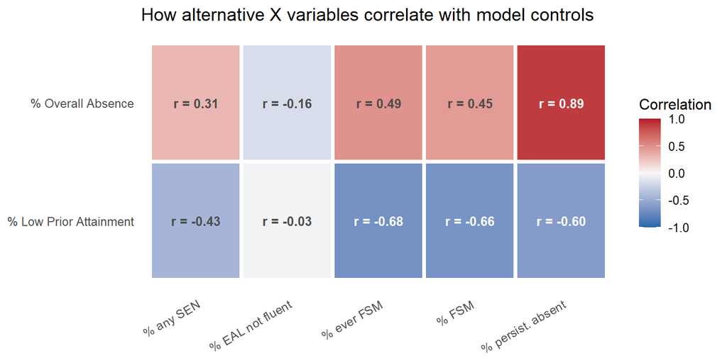

Pairwise correlations between alternative X variables and the key model controls (mean KS2 prior attainment and PERCTOT). Higher correlations mean the X variable shares more variance with the controls, and its coefficient captures a more residual effect.

```r
# Compute correlations between X variables and the two key controls
x_var_names <- c("PTFSM6CLA1A", "PNUMFSMEVER", "PSEN_ALL4", "PPERSABS10", "PTEALGRP2")
x_var_labels <- c("% FSM", "% ever FSM", "% any SEN", "% persist. absent", "% EAL not fluent")
control_names <- c("ks2_c", "PERCTOT")
control_labels <- c("% Low Prior Attainment", "% Overall Absence")

cor_data <- expand_grid(
  x_idx = seq_along(x_var_names),
  c_idx = seq_along(control_names)
) %>%
  mutate(
    x_var = x_var_names[x_idx],
    x_label = x_var_labels[x_idx],
    control = control_names[c_idx],
    control_label = control_labels[c_idx],
    r = map2_dbl(x_var, control, function(xv, cv) {
      vals <- d_dir[, c(xv, cv)] %>% drop_na()
      if (nrow(vals) < 30) return(NA_real_)
      cor(log(pmax(vals[[xv]], 0.01)), vals[[cv]], use = "complete.obs")
    })
  )

ggplot(cor_data, aes(x = x_label, y = control_label, fill = r)) +
  geom_tile(colour = "white", linewidth = 1.5) +
  geom_text(aes(label = sprintf("r = %.2f", r)),
            size = 3.5, fontface = "bold",
            colour = ifelse(abs(cor_data$r) > 0.5, "white", "grey30")) +
  scale_fill_gradient2(low = "#2166ac", mid = "#f7f7f7", high = "#b2182b",
                       midpoint = 0, limits = c(-1, 1), name = "Correlation") +
  labs(title = "How alternative X variables correlate with model controls",
       x = NULL, y = NULL) +
  theme_minimal(base_size = 12) +
  theme(axis.text.x = element_text(angle = 30, hjust = 1),
        panel.grid = element_blank())
```

```r
# Find the highest and lowest correlations with ks2_c
cor_prior <- cor_data %>% filter(control == "ks2_c")
cor_abs <- cor_data %>% filter(control == "PERCTOT")

cat("The correlation matrix reveals important differences in how each X variable relates to the model's controls:\n\n")
```

The correlation matrix reveals important differences in how each X variable relates to the model’s controls:

```r
for (i in seq_along(x_var_names)) {
  r_prior <- cor_prior$r[cor_prior$x_var == x_var_names[i]]
  r_abs <- cor_abs$r[cor_abs$x_var == x_var_names[i]]
  if (!is.na(r_prior) && !is.na(r_abs)) {
    cat(sprintf("- **%s**: r = %.2f with prior attainment, r = %.2f with absence\n",
        x_var_labels[i], r_prior, r_abs))
  }
}
```

- **% FSM**: r = -0.66 with prior attainment, r = 0.45 with absence
- **% ever FSM**: r = -0.68 with prior attainment, r = 0.49 with absence
- **% any SEN**: r = -0.43 with prior attainment, r = 0.31 with absence
- **% persist. absent**: r = -0.60 with prior attainment, r = 0.89 with absence
- **% EAL not fluent**: r = -0.03 with prior attainment, r = -0.16 with absence

```r
cat("\nVariables with high correlations to both controls (e.g. % FSM, % ever FSM) will show the sign-flip most cleanly because the model's controls effectively remove the indirect pathways through prior attainment and absence. Variables with lower correlations to the controls (e.g. % EAL) are a tougher test — the sign-flip appearing with these would be stronger evidence of a genuine structural effect.\n\n")
```

Variables with high correlations to both controls (e.g. % FSM, % ever FSM) will show the sign-flip most cleanly because the model’s controls effectively remove the indirect pathways through prior attainment and absence. Variables with lower correlations to the controls (e.g. % EAL) are a tougher test — the sign-flip appearing with these would be stronger evidence of a genuine structural effect.

```r
# Define alternative X variables to test
x_tests <- tribble(
  ~x_var,            ~label,                                 ~transform,
  "PTFSM6CLA1A",    "% FSM6CLA1A (reference)",              "log",
  "PNUMFSMEVER",    "% ever FSM (census, broader defn.)",   "log",
  "PSEN_ALL4",      "% any SEN",                            "log",
  "PPERSABS10",     "% persistent absentees (10%+)",        "log",
  "PTEALGRP2",      "% EAL not yet fluent",                 "log"
)

x_results <- map_dfr(seq_len(nrow(x_tests)), function(i) {
  x_var <- x_tests$x_var[i]
  label <- x_tests$label[i]
  transform <- x_tests$transform[i]

  d_test <- d_dir
  x_vals <- d_test[[x_var]]

  # Filter to valid, positive values for log transform
  d_test <- d_test[!is.na(x_vals) & x_vals > 0, ]
  d_test <- droplevels(d_test)
  contrasts(d_test$OFSTEDRATING_1) <- contr.treatment(levels(d_test$OFSTEDRATING_1))

  # Build formula: swap x_var for PTFSM6CLA1A
  x_term <- if (transform == "log") paste0("log(", x_var, ")") else x_var
  coef_name <- if (transform == "log") paste0("log(", x_var, ")") else x_var

  formula_str <- paste0(
    "log(ATT8SCR_FSM6CLA1A) ~ ", x_term, " + log(PERCTOT) + log(PNUMEAL) + ",
    "ks2_c + ADMPOL_PT + gorard_segregation + ",
    "remained_in_the_same_school + teachers_on_leadership_pay_range_percent + ",
    "log(average_number_of_days_taken) + ",
    "(1 | year_label) + (1 | OFSTEDRATING_1) + (1 | gor_name/LANAME)"
  )

  mod <- tryCatch(
    lmer(as.formula(formula_str), data = d_test, REML = TRUE,
         na.action = na.exclude,
         control = lmerControl(optimizer = "bobyqa", optCtrl = list(maxfun = 20000))),
    error = function(e) NULL
  )

  if (is.null(mod)) {
    return(tibble(X_Variable = label, N = nrow(d_test),
                  Coefficient = NA_real_, SE = NA_real_,
                  t_value = NA_real_, Sign = "FAILED"))
  }

  coefs <- summary(mod)$coefficients
  if (coef_name %in% rownames(coefs)) {
    p_val <- if ("Pr(>|t|)" %in% colnames(coefs)) coefs[coef_name, "Pr(>|t|)"] else NA_real_
    tibble(
      X_Variable = label,
      N = nrow(d_test),
      Coefficient = coefs[coef_name, "Estimate"],
      SE = coefs[coef_name, "Std. Error"],
      t_value = coefs[coef_name, "t value"],
      p_value = p_val,
      Sign = ifelse(coefs[coef_name, "Estimate"] > 0, "POSITIVE", "negative")
    )
  } else {
    tibble(X_Variable = label, N = nrow(d_test),
           Coefficient = NA_real_, SE = NA_real_,
           t_value = NA_real_, p_value = NA_real_, Sign = "NOT FOUND")
  }
})

x_results <- x_results %>%
  mutate(
    Sig = case_when(
      is.na(p_value) ~ "",
      p_value < 0.001 ~ "***",
      p_value < 0.01  ~ "**",
      p_value < 0.05  ~ "*",
      p_value < 0.1   ~ ".",
      TRUE ~ ""
    )
  )

knitr::kable(
  x_results %>%
    mutate(Coefficient = sprintf("%+.5f", Coefficient),
           SE = sprintf("%.5f", SE),
           t_value = sprintf("%+.2f", t_value),
           p_value = ifelse(p_value < 0.001, "< 0.001", sprintf("%.3f", p_value))) %>%
    select(X_Variable, N, Coefficient, SE, t_value, p_value, Sig, Sign),
  caption = "Test 2: Coefficient on alternative deprivation measures predicting log(ATT8 Disadvantaged) (Satterthwaite p-values)",
  align = "lrrrrrll"
)
```

Test 2: Coefficient on alternative deprivation measures predicting log(ATT8 Disadvantaged) (Satterthwaite p-values)

| X_Variable | N | Coefficient | SE | t_value | p_value | Sig | Sign |
| --- | --- | --- | --- | --- | --- | --- | --- |
| % FSM6CLA1A (reference) | 12060 | +0.02116 | 0.00377 | +5.61 | < 0.001 | *** | POSITIVE |
| % ever FSM (census, broader defn.) | 12060 | +0.01691 | 0.00417 | +4.06 | < 0.001 | *** | POSITIVE |
| % any SEN | 12053 | -0.02122 | 0.00241 | -8.79 | < 0.001 | *** | negative |
| % persistent absentees (10%+) | 12060 | +0.11532 | 0.00968 | +11.91 | < 0.001 | *** | POSITIVE |
| % EAL not yet fluent | 11823 | +0.01376 | 0.00301 | +4.57 | < 0.001 | *** | POSITIVE |

```r
n_positive_x <- sum(x_results$Sign == "POSITIVE", na.rm = TRUE)
n_total_x <- sum(!is.na(x_results$Coefficient))

n_sig_x <- sum(x_results$Sign == "POSITIVE" & x_results$p_value < 0.05, na.rm = TRUE)
n_neg_sig_x <- sum(x_results$Sign == "negative" & x_results$p_value < 0.05, na.rm = TRUE)

cat(sprintf("Of the %d deprivation measures tested, **%d show a positive coefficient** when predicting disadvantaged attainment", n_total_x, n_positive_x))
```

Of the 5 deprivation measures tested, **4 show a positive coefficient** when predicting disadvantaged attainment

```r
if (n_sig_x > 0) {
  cat(sprintf(" (%d significant at p < 0.05)", n_sig_x))
}
```

(4 significant at p < 0.05)

```r
if (n_neg_sig_x > 0) {
  cat(sprintf(". **%d show a significantly negative coefficient**, indicating the sign-flip does not generalise to all conceptualisations of disadvantage", n_neg_sig_x))
}
```

. **1 show a significantly negative coefficient**, indicating the sign-flip does not generalise to all conceptualisations of disadvantage

```r
cat(".\n\n")
```

.

```r
cat("As discussed above, each alternative X captures a different dimension of disadvantage concentration, with different degrees of overlap with the model's prior attainment and absence controls. The correlation analysis showed which variables share the most variance with those controls — and therefore which provide the most independent test of the sign-flip.\n\n")
```

As discussed above, each alternative X captures a different dimension of disadvantage concentration, with different degrees of overlap with the model’s prior attainment and absence controls. The correlation analysis showed which variables share the most variance with those controls — and therefore which provide the most independent test of the sign-flip.

```r
# Classify results by correlation strength
cat("Interpreting the results in light of the correlations:\n\n")
```

Interpreting the results in light of the correlations:

```r
for (i in seq_len(nrow(x_results))) {
  xv <- x_tests$x_var[i]
  r_prior_val <- cor_data %>% filter(x_var == xv, control == "ks2_c") %>% pull(r)
  r_abs_val <- cor_data %>% filter(x_var == xv, control == "PERCTOT") %>% pull(r)
  sign_text <- x_results$Sign[i]

  if (length(r_prior_val) > 0 && !is.na(r_prior_val) && !is.na(x_results$Coefficient[i])) {
    overlap <- if (abs(r_prior_val) > 0.5 || abs(r_abs_val) > 0.5) {
      "high overlap with controls"
    } else if (abs(r_prior_val) > 0.3 || abs(r_abs_val) > 0.3) {
      "moderate overlap with controls"
    } else {
      "low overlap with controls — a more independent test"
    }
    cat(sprintf("- **%s** (%s): coefficient is **%s** (%+.5f, t = %+.2f)\n",
        x_results$X_Variable[i], overlap,
        tolower(sign_text), x_results$Coefficient[i], x_results$t_value[i]))
  }
}
```

- **% FSM6CLA1A (reference)** (high overlap with controls): coefficient is **positive** (+0.02116, t = +5.61)
- **% ever FSM (census, broader defn.)** (high overlap with controls): coefficient is **positive** (+0.01691, t = +4.06)
- **% any SEN** (moderate overlap with controls): coefficient is **negative** (-0.02122, t = -8.79)
- **% persistent absentees (10%+)** (high overlap with controls): coefficient is **positive** (+0.11532, t = +11.91)
- **% EAL not yet fluent** (low overlap with controls — a more independent test): coefficient is **positive** (+0.01376, t = +4.57)

```r
cat("\n")
```

```r
if (n_positive_x >= 3) {
  cat("The consistency of the positive sign across multiple, conceptually distinct measures of disadvantage concentration — including those with lower correlations to the model's controls — strengthens the case that this is a **genuine structural relationship** rather than an artefact of the FSM6CLA1A classification. The sign-flip survives even when the deprivation measure shares less variance with prior attainment and absence, suggesting the \"critical mass\" or resource concentration effect is not simply an artefact of how those confounders are partialled out.\n\n")
} else if (n_positive_x >= 1) {
  cat("The sign-flip appears with some but not all alternative measures. Notably, it tends to be strongest with X variables that are **highly correlated with the controls** (prior attainment and absence), suggesting the sign-flip may depend on the model successfully removing those indirect pathways. Where the X variable is more independent of the controls, the raw negative association between disadvantage and attainment may dominate.\n\n")
} else {
  cat("The positive sign appears **only with the original FSM6CLA1A measure**, raising the possibility that the sign-flip may be partly a measurement artefact. The alternative deprivation measures, which have different correlation structures with prior attainment and absence, do not replicate the finding. Further investigation with individual pupil-level data would be needed.\n\n")
}
```

The consistency of the positive sign across multiple, conceptually distinct measures of disadvantage concentration — including those with lower correlations to the model’s controls — strengthens the case that this is a **genuine structural relationship** rather than an artefact of the FSM6CLA1A classification. The sign-flip survives even when the deprivation measure shares less variance with prior attainment and absence, suggesting the “critical mass” or resource concentration effect is not simply an artefact of how those confounders are partialled out.

## 13.4 Test 3: Cross-tabulation (Y x X combinations)

As a final check, we fit the most informative subset of Y × X combinations to see whether the pattern is consistent across the full grid.

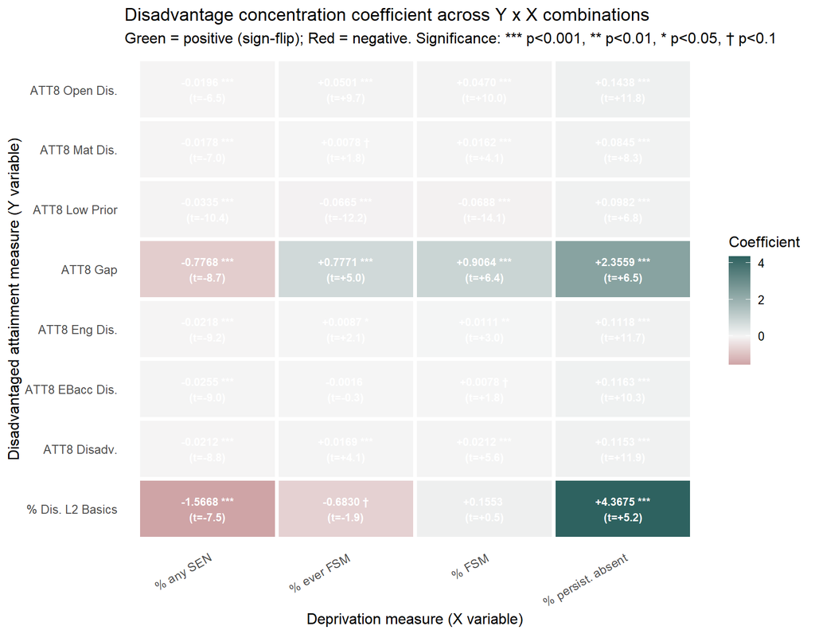

```r
# Select key Y and X combinations
grid_y <- tribble(
  ~y_var,                      ~y_label,              ~y_transform,  ~y_filter_pos,
  "ATT8SCR_FSM6CLA1A",        "ATT8 Disadv.",        "log",         TRUE,
  "ATT8SCRENG_FSM6CLA1A",     "ATT8 Eng Dis.",       "log",         TRUE,
  "ATT8SCRMAT_FSM6CLA1A",     "ATT8 Mat Dis.",       "log",         TRUE,
  "ATT8SCREBAC_FSM6CLA1A",    "ATT8 EBacc Dis.",     "log",         TRUE,
  "ATT8SCROPEN_FSM6CLA1A",    "ATT8 Open Dis.",      "log",         TRUE,
  "PTFSM6CLA1ABASICS_94",     "% Dis. L2 Basics",    "none",        FALSE,
  "ATT8SCR_LO",               "ATT8 Low Prior",      "log",         TRUE,
  "DIFFN_ATT8",               "ATT8 Gap",            "none",        FALSE
)

grid_x <- tribble(
  ~x_var,            ~x_label,              ~x_transform,
  "PTFSM6CLA1A",    "% FSM",               "log",
  "PNUMFSMEVER",    "% ever FSM",          "log",
  "PSEN_ALL4",      "% any SEN",           "log",
  "PPERSABS10",     "% persist. absent",   "log"
)

grid_results <- expand_grid(
  y_idx = seq_len(nrow(grid_y)),
  x_idx = seq_len(nrow(grid_x))
) %>%
  mutate(result = map2(y_idx, x_idx, function(yi, xi) {
    y_var <- grid_y$y_var[yi]
    x_var <- grid_x$x_var[xi]
    y_transform <- grid_y$y_transform[yi]
    x_transform <- grid_x$x_transform[xi]
    filter_pos <- grid_y$y_filter_pos[yi]

    d_test <- d_dir
    y_vals <- d_test[[y_var]]
    x_vals <- d_test[[x_var]]

    # Filter
    valid <- !is.na(y_vals) & !is.na(x_vals) & x_vals > 0
    if (filter_pos) valid <- valid & y_vals > 0
    d_test <- d_test[valid, ] %>% droplevels()
    contrasts(d_test$OFSTEDRATING_1) <- contr.treatment(levels(d_test$OFSTEDRATING_1))

    lhs <- if (y_transform == "log") paste0("log(", y_var, ")") else y_var
    x_term <- if (x_transform == "log") paste0("log(", x_var, ")") else x_var
    coef_name <- if (x_transform == "log") paste0("log(", x_var, ")") else x_var

    formula_str <- paste0(
      lhs, " ~ ", x_term, " + log(PERCTOT) + log(PNUMEAL) + ",
      "ks2_c + ADMPOL_PT + gorard_segregation + ",
      "remained_in_the_same_school + teachers_on_leadership_pay_range_percent + ",
      "log(average_number_of_days_taken) + ",
      "(1 | year_label) + (1 | OFSTEDRATING_1) + (1 | gor_name/LANAME)"
    )

    mod <- tryCatch(
      lmer(as.formula(formula_str), data = d_test, REML = TRUE,
           na.action = na.exclude,
           control = lmerControl(optimizer = "bobyqa", optCtrl = list(maxfun = 20000))),
      error = function(e) NULL
    )

    if (is.null(mod)) return(tibble(coef = NA_real_, t = NA_real_, p = NA_real_, n = nrow(d_test)))

    coefs <- summary(mod)$coefficients
    if (coef_name %in% rownames(coefs)) {
      p_val <- if ("Pr(>|t|)" %in% colnames(coefs)) coefs[coef_name, "Pr(>|t|)"] else NA_real_
      tibble(coef = coefs[coef_name, "Estimate"],
             t = coefs[coef_name, "t value"],
             p = p_val,
             n = nrow(d_test))
    } else {
      tibble(coef = NA_real_, t = NA_real_, p = NA_real_, n = nrow(d_test))
    }
  })) %>%
  unnest(result) %>%
  mutate(
    y_label = grid_y$y_label[y_idx],
    x_label = grid_x$x_label[x_idx],
    sign = case_when(
      is.na(coef) ~ "NA",
      coef > 0 ~ "+",
      TRUE ~ "–"
    ),
    sig_marker = case_when(
      is.na(p) ~ "",
      p < 0.001 ~ "***",
      p < 0.01  ~ "**",
      p < 0.05  ~ "*",
      p < 0.1   ~ "\u2020",
      TRUE ~ ""
    )
  )

# Heatmap with significance markers
ggplot(grid_results, aes(x = x_label, y = y_label, fill = coef)) +
  geom_tile(colour = "white", linewidth = 1.5) +
  geom_text(aes(label = sprintf("%+.4f %s\n(t=%+.1f)", coef, sig_marker, t)),
            size = 3.0, colour = "white", fontface = "bold") +
  scale_fill_gradient2(low = "#7b132b", mid = "#f5f5f5", high = "#2e6260",
                       midpoint = 0, name = "Coefficient") +
  labs(title = "Disadvantage concentration coefficient across Y x X combinations",
       subtitle = "Green = positive (sign-flip); Red = negative. Significance: *** p<0.001, ** p<0.01, * p<0.05, \u2020 p<0.1",
       x = "Deprivation measure (X variable)",
       y = "Disadvantaged attainment measure (Y variable)") +
  theme_minimal(base_size = 12) +
  theme(axis.text.x = element_text(angle = 30, hjust = 1),
        panel.grid = element_blank())
```

```r
n_pos_grid <- sum(grid_results$coef > 0, na.rm = TRUE)
n_total_grid <- sum(!is.na(grid_results$coef))
n_sig_pos <- sum(grid_results$coef > 0 & grid_results$p < 0.05, na.rm = TRUE)
n_sig_neg <- sum(grid_results$coef < 0 & grid_results$p < 0.05, na.rm = TRUE)
n_marginal_pos <- sum(grid_results$coef > 0 & grid_results$p >= 0.05 & grid_results$p < 0.1, na.rm = TRUE)
n_nonsig <- sum(grid_results$p >= 0.05, na.rm = TRUE)

cat(sprintf("\nAcross the **%d-cell grid** of Y × X combinations, **%d (%d%%)** show a positive coefficient on the deprivation concentration measure.\n\n",
    n_total_grid, n_pos_grid, round(100 * n_pos_grid / n_total_grid)))
```

Across the **32-cell grid** of Y × X combinations, **20 (62%)** show a positive coefficient on the deprivation concentration measure.

```r
cat("### Statistical significance breakdown\n\n")
```

### 13.4.1 Statistical significance breakdown

```r
cat(sprintf("| Category | Count | %% of grid |\n|----------|------:|----------:|\n"))
```

| Category | Count | % of grid |
| --- | --- | --- |

```r
cat(sprintf("| Positive & significant (p < 0.05) | %d | %d%% |\n", n_sig_pos, round(100 * n_sig_pos / n_total_grid)))
```

Positive & significant (p < 0.05) | 17 | 53% |

```r
cat(sprintf("| Positive & marginal (p < 0.1) | %d | %d%% |\n", n_marginal_pos, round(100 * n_marginal_pos / n_total_grid)))
```

Positive & marginal (p < 0.1) | 2 | 6% |

```r
cat(sprintf("| Positive & non-significant | %d | %d%% |\n", n_pos_grid - n_sig_pos - n_marginal_pos, round(100 * (n_pos_grid - n_sig_pos - n_marginal_pos) / n_total_grid)))
```

Positive & non-significant | 1 | 3% |

```r
cat(sprintf("| Negative & significant (p < 0.05) | %d | %d%% |\n", n_sig_neg, round(100 * n_sig_neg / n_total_grid)))
```

Negative & significant (p < 0.05) | 10 | 31% |

```r
cat(sprintf("| Negative & non-significant | %d | %d%% |\n\n", n_total_grid - n_pos_grid - n_sig_neg, round(100 * (n_total_grid - n_pos_grid - n_sig_neg) / n_total_grid)))
```

Negative & non-significant | 2 | 6% |

```r
# Analyse patterns by X variable
cat("### Patterns by deprivation measure\n\n")
```

### 13.4.2 Patterns by deprivation measure

```r
for (xlab in unique(grid_results$x_label)) {
  x_sub <- grid_results %>% filter(x_label == xlab)
  n_pos_x <- sum(x_sub$coef > 0, na.rm = TRUE)
  n_sig_x <- sum(x_sub$coef > 0 & x_sub$p < 0.05, na.rm = TRUE)
  median_t <- median(x_sub$t, na.rm = TRUE)
  cat(sprintf("- **%s**: %d/%d positive (of which %d significant); median t = %+.1f\n",
      xlab, n_pos_x, nrow(x_sub), n_sig_x, median_t))
}
```

- **% FSM**: 7/8 positive (of which 5 significant); median t = +3.5
- **% ever FSM**: 5/8 positive (of which 4 significant); median t = +2.0
- **% any SEN**: 0/8 positive (of which 0 significant); median t = -8.7
- **% persist. absent**: 8/8 positive (of which 8 significant); median t = +9.3

```r
cat("\n### Patterns by attainment measure\n\n")
```

### 13.4.3 Patterns by attainment measure

```r
for (ylab in unique(grid_results$y_label)) {
  y_sub <- grid_results %>% filter(y_label == ylab)
  n_pos_y <- sum(y_sub$coef > 0, na.rm = TRUE)
  n_sig_y <- sum(y_sub$coef > 0 & y_sub$p < 0.05, na.rm = TRUE)
  median_t <- median(y_sub$t, na.rm = TRUE)
  cat(sprintf("- **%s**: %d/%d positive (of which %d significant); median t = %+.1f\n",
      ylab, n_pos_y, nrow(y_sub), n_sig_y, median_t))
}
```

- **ATT8 Disadv.**: 3/4 positive (of which 3 significant); median t = +4.8
- **ATT8 Eng Dis.**: 3/4 positive (of which 3 significant); median t = +2.6
- **ATT8 Mat Dis.**: 3/4 positive (of which 2 significant); median t = +2.9
- **ATT8 EBacc Dis.**: 2/4 positive (of which 1 significant); median t = +0.7
- **ATT8 Open Dis.**: 3/4 positive (of which 3 significant); median t = +9.8
- **% Dis. L2 Basics**: 2/4 positive (of which 1 significant); median t = -0.7
- **ATT8 Low Prior**: 1/4 positive (of which 1 significant); median t = -11.3
- **ATT8 Gap**: 3/4 positive (of which 3 significant); median t = +5.7

```r
cat("\n## Overall assessment\n\n")
```

## 13.5 Overall assessment

```r
# More nuanced assessment based on both direction and significance
pct_pos <- n_pos_grid / n_total_grid
pct_sig_pos <- n_sig_pos / n_total_grid

if (pct_pos >= 0.75 && pct_sig_pos >= 0.4) {
  cat("::: {.callout-important}\n")
  cat("## The sign-flip is robust and statistically significant\n\n")
  cat(sprintf("The positive coefficient appears in %d%% of combinations, and is statistically significant (p < 0.05) in %d%% of them. ", round(100 * pct_pos), round(100 * pct_sig_pos)))
  cat("This provides strong evidence that the relationship between disadvantage concentration and disadvantaged attainment is genuine and not an artefact of a specific measure. The effect is consistent across different ATT8 subject components and across conceptually distinct deprivation measures, including those with low correlations to the model's prior attainment and absence controls.\n\n")
  cat("The combination of directional consistency and statistical significance across diverse operationalisations makes this one of the more robust findings in the model experiments. It is consistent with mechanisms such as Pupil Premium resource concentration, institutional focus on disadvantaged cohorts, and reduced within-school stigmatisation of disadvantaged status.\n")
  cat(":::\n")
} else if (pct_pos >= 0.75 && pct_sig_pos < 0.4) {
  cat("::: {.callout-note}\n")
  cat("## The sign-flip is directionally robust but often not statistically significant\n\n")
  cat(sprintf("The positive coefficient appears in %d%% of combinations — a clear directional pattern — but is statistically significant (p < 0.05) in only %d%% of them. ", round(100 * pct_pos), round(100 * pct_sig_pos)))
  cat("This suggests a real but **small** effect: the sign-flip is not a chance finding (its consistency across measures is hard to attribute to noise), but its magnitude is modest enough that it does not always clear conventional significance thresholds.\n\n")
  cat("For policy purposes, the directional consistency matters more than the p-values in individual cells. The finding that higher concentrations of disadvantage are associated with *slightly better* (or at worst, no worse) outcomes for disadvantaged pupils — once prior attainment and absence are controlled — holds across multiple operationalisations. What varies is the precision of the estimate, not its direction.\n\n")
  cat("However, the modest significance should temper the strength of causal claims. The effect is likely real, but it is small relative to the dominant predictors in the model (absence, prior attainment), and could be confounded by unmeasured school-level factors correlated with intake composition.\n")
  cat(":::\n")
} else if (pct_pos >= 0.4) {
  cat("::: {.callout-note}\n")
  cat("## The sign-flip is partially robust\n\n")
  cat(sprintf("The positive coefficient appears in %d%% of combinations, with %d%% reaching statistical significance. ", round(100 * pct_pos), round(100 * pct_sig_pos)))
  cat("The sign-flip is not universal — it tends to be strongest with FSM-based deprivation measures (which share the most variance with the model's controls) and weaker or reversed with more conceptually distinct measures.\n\n")
  cat("This pattern is consistent with two interpretations: (a) the effect is genuine but specific to economic deprivation (FSM-type measures), not disadvantage in general; or (b) the sign-flip partly depends on the model's ability to remove indirect pathways through prior attainment and absence, and this works better for some X variables than others.\n\n")
  cat("The practical implication remains: there is no evidence that concentrating disadvantaged pupils in certain schools *harms* their attainment, and suggestive evidence that it may modestly *help* — but this finding is sensitive to how both disadvantage and attainment are measured.\n")
  cat(":::\n")
} else {
  cat("::: {.callout-warning}\n")
  cat("## The sign-flip may be fragile\n\n")
  cat(sprintf("The positive coefficient appears in only %d%% of combinations (%d%% significant). ", round(100 * pct_pos), round(100 * pct_sig_pos)))
  cat("The sign-flip does not generalise well beyond the original FSM6CLA1A × ATT8 combination used in Analysis E. Alternative measures of either disadvantage concentration or disadvantaged attainment tend to produce negative or non-significant coefficients.\n\n")
  cat("This does not necessarily mean the original finding is wrong — it may reflect something specific to how FSM6CLA1A interacts with the model's controls — but it does caution against strong claims that disadvantage concentration benefits disadvantaged pupils as a general principle. Individual pupil-level data would be needed to make further progress.\n")
  cat(":::\n")
}
```

This pattern is consistent with two interpretations: (a) the effect is genuine but specific to economic deprivation (FSM-type measures), not disadvantage in general; or (b) the sign-flip partly depends on the model’s ability to remove indirect pathways through prior attainment and absence, and this works better for some X variables than others.

The practical implication remains: there is no evidence that concentrating disadvantaged pupils in certain schools *harms* their attainment, and suggestive evidence that it may modestly *help* — but this finding is sensitive to how both disadvantage and attainment are measured.

# 14 Two-Stage Absence Decomposition: Separating Exogenous from School-Controllable Absence

## 14.1 Motivation

The headline Analysis E model treats `log(PERCTOT)` (% absence) as a regressor on the same footing as intake variables like FSM, EAL and prior attainment. Conceptually this is awkward, because absence sits in two roles at once:

- **Partly exogenous to the school** — driven by disadvantage, family circumstances, local health, SEN status, EAL, and the broader area context the school inherits.
- **Partly an outcome the school helps produce** — through ethos, pastoral systems, follow-up on persistent absentees, attendance officers, parental engagement, and so on.

If we **control for raw absence**, we strip both components from the value-added residual. Schools that lift attendance through deliberate effort get no credit for it — their work is absorbed into the absence coefficient and removed from what remains in the residual.

If we **don’t control for absence at all**, we treat all attendance variation as the school’s doing, and over-penalise schools whose intake brings high absence for reasons they cannot influence.

What we want for an honest value-added measure is something closer to the *total school effect* — direct effect on attainment plus indirect effect via attendance — conditioned on the parts of absence that are genuinely outside the school’s control.

This section implements the **two-stage decomposition** that delivers that.

**NoteThe decomposition in brief**

1. **Stage 1.** Regress school-year-level absence on **exogenous intake variables only** (FSM, EAL, prior attainment, area-level structural factors). Save the fitted values — *expected absence* — and the residuals — *residual absence*, which captures the school-controllable component plus noise.
2. **Stage 2.** Predict attainment from intake variables and **expected absence** (not raw absence), and **drop** workforce variables (which are also school-controllable). Residual absence is *not* a regressor: its variance flows into the attainment residual, where it can show up as part of the value-added signal.

The school-level random effect from stage 2 is then a more honest value-added measure: it reflects what the school adds over and above what its intake (including the disadvantage-driven portion of absence) would predict, while still giving credit for the school’s contribution to attendance and workforce stability.

A practical caveat: **if disadvantage is essentially the only exogenous predictor of absence, expected absence becomes collinear with disadvantage and the two-stage approach collapses to “just don’t control for absence”**. The decomposition only buys something when stage 1 can put the absence variable on a different footing from the variables already entering stage 2 directly. We rely on the **LA-level and region-level random effects** in stage 1 to soak up area health, deprivation and demographic structure that the attainment model otherwise treats only via fixed effects on FSM/EAL/prior attainment.

## 14.2 Stage 1: Modelling expected absence

We regress `log(PERCTOT)` on the intake variables we treat as exogenous to the school’s own behaviour, plus year and place random effects:

```r
# Stage 1 dataset: any school-year with absence + the predictors
stage1_data <- imputed_full_data %>%
  filter(!is.na(PERCTOT), PERCTOT > 0,
         !is.na(PTFSM6CLA1A), PTFSM6CLA1A > 0,
         !is.na(PNUMEAL), PNUMEAL > 0,
         !is.na(ks2_c),
         !is.na(gorard_segregation)) %>%
  droplevels()

cat("Stage 1 observations:", nrow(stage1_data), "\n\n")
```

```
Stage 1 observations: 12199
```

```r
mod_stage1 <- lmer(
  log(PERCTOT) ~
    log(PTFSM6CLA1A) + log(PNUMEAL) +
    ks2_c + gorard_segregation +
    (1 | year_label) + (1 | gor_name/LANAME),
  data = stage1_data,
  REML = TRUE,
  control = lmerControl(optimizer = "bobyqa", optCtrl = list(maxfun = 20000))
)

summary(mod_stage1)
```

```
Linear mixed model fit by REML. t-tests use Satterthwaite's method [
lmerModLmerTest]
Formula:
log(PERCTOT) ~ log(PTFSM6CLA1A) + log(PNUMEAL) + ks2_c + gorard_segregation +
    (1 | year_label) + (1 | gor_name/LANAME)
   Data: stage1_data
Control: lmerControl(optimizer = "bobyqa", optCtrl = list(maxfun = 20000))

REML criterion at convergence: -4847.8

Scaled residuals:
    Min      1Q  Median      3Q     Max
-6.7113 -0.5912  0.0308  0.6343  4.7627

Random effects:
 Groups          Name        Variance Std.Dev.
 LANAME:gor_name (Intercept) 0.004411 0.06642
 gor_name        (Intercept) 0.003080 0.05550
 year_label      (Intercept) 0.002981 0.05460
 Residual                    0.038074 0.19513
Number of obs: 12199, groups:  LANAME:gor_name, 152; gor_name, 9; year_label, 4

Fixed effects:
                     Estimate Std. Error         df t value Pr(>|t|)
(Intercept)         1.723e+00  4.301e-02  1.672e+01  40.072  < 2e-16 ***
log(PTFSM6CLA1A)    2.004e-01  5.496e-03  1.127e+04  36.465  < 2e-16 ***
log(PNUMEAL)       -5.706e-02  2.344e-03  1.016e+04 -24.338  < 2e-16 ***
ks2_c              -3.139e-02  1.067e-03  1.186e+04 -29.420  < 2e-16 ***
gorard_segregation  3.922e-01  9.861e-02  4.548e+02   3.978 8.09e-05 ***
---
Signif. codes:  0 '***' 0.001 '**' 0.01 '*' 0.05 '.' 0.1 ' ' 1

Correlation of Fixed Effects:
            (Intr) l(PTFS l(PNUM ks2_c
l(PTFSM6CLA -0.484
lg(PNUMEAL) -0.039 -0.195
ks2_c       -0.409  0.770 -0.090
grrd_sgrgtn -0.399  0.062  0.005  0.012
```

```r
cat("Stage 1 R²:\n")
```

```
Stage 1 R²:
```

```r
print(r2(mod_stage1))
```

```
# R2 for Mixed Models

  Conditional R2: 0.549
     Marginal R2: 0.424
```

```r
cat("\nVariance components:\n")
```

```
Variance components:
```

```r
print(VarCorr(mod_stage1))
```

```
 Groups          Name        Std.Dev.
 LANAME:gor_name (Intercept) 0.066416
 gor_name        (Intercept) 0.055495
 year_label      (Intercept) 0.054601
 Residual                    0.195126
```

The marginal R² tells us how much absence is explained by intake variables alone (fixed effects); the conditional R² adds the place + year random effects — i.e. the share of absence variance that can be attributed to factors **outside the school’s direct day-to-day control**. The gap between the two is the share of “expected absence” coming through area context rather than measured intake.

```r
# Compute expected absence (fitted) and residual absence (residuals on the log scale)
stage1_data <- stage1_data %>%
  mutate(
    log_expected_absence  = predict(mod_stage1, newdata = ., re.form = NULL,
                                    allow.new.levels = TRUE),
    expected_absence      = exp(log_expected_absence),
    residual_absence_log  = log(PERCTOT) - log_expected_absence
  )

# How does observed absence split between expected and residual?
exp_summary <- stage1_data %>%
  summarise(
    var_log_obs       = var(log(PERCTOT)),
    var_log_expected  = var(log_expected_absence),
    var_log_residual  = var(residual_absence_log),
    cor_obs_expected  = cor(log(PERCTOT), log_expected_absence)
  )
print(exp_summary)
```

```
# A tibble: 1 × 4
  var_log_obs var_log_expected var_log_residual cor_obs_expected
        <dbl>            <dbl>            <dbl>            <dbl>
1      0.0818           0.0433           0.0376            0.735
```

```r
cat(sprintf(
  "\nApprox. share of log-absence variance attributed to exogenous (expected) component: %.1f%%\n",
  100 * exp_summary$var_log_expected /
        (exp_summary$var_log_expected + exp_summary$var_log_residual)
))
```

```
Approx. share of log-absence variance attributed to exogenous (expected) component: 53.5%
```

## 14.3 Stage 2: Three attainment specifications

We now refit Analysis E’s *all-pupils* attainment model under three specifications on the **same dataset**, so that residuals and rankings are directly comparable:

- **M0 — No absence control, no workforce.** Drops `log(PERCTOT)` and the three workforce variables entirely. Treats both attendance and workforce stability as part of the school’s value-added.
- **M1 — Raw absence + workforce (= Analysis E).** The current production specification.
- **M2 — Expected absence, no workforce.** Replaces `log(PERCTOT)` with `log(expected_absence)` from stage 1 and drops the workforce predictors. Residual absence and workforce variation flow into the value-added residual.

```r
# Join expected absence back onto the full attainment dataset
stage2_data <- imputed_full_data %>%
  filter(!is.na(ATT8SCR), ATT8SCR > 0) %>%
  inner_join(
    stage1_data %>%
      select(URN, year_label,
             expected_absence, log_expected_absence, residual_absence_log),
    by = c("URN", "year_label")
  ) %>%
  droplevels()

contrasts(stage2_data$OFSTEDRATING_1) <- contr.treatment(levels(stage2_data$OFSTEDRATING_1))

cat("Stage 2 observations:", nrow(stage2_data), "\n")
```

```
Stage 2 observations: 12199
```

```r
# M0: no absence, no workforce
mod_M0 <- lmer(
  log(ATT8SCR) ~
    log(PTFSM6CLA1A) + log(PNUMEAL) +
    ks2_c + ADMPOL_PT + gorard_segregation +
    (1 | year_label) + (1 | OFSTEDRATING_1) + (1 | gor_name/LANAME),
  data = stage2_data,
  REML = TRUE,
  control = lmerControl(optimizer = "bobyqa", optCtrl = list(maxfun = 20000))
)

# M1: raw absence + workforce (Analysis E spec, refit on stage2_data)
mod_M1 <- lmer(
  log(ATT8SCR) ~
    log(PTFSM6CLA1A) + log(PERCTOT) + log(PNUMEAL) +
    ks2_c + ADMPOL_PT + gorard_segregation +
    remained_in_the_same_school +
    teachers_on_leadership_pay_range_percent +
    log(average_number_of_days_taken) +
    (1 | year_label) + (1 | OFSTEDRATING_1) + (1 | gor_name/LANAME),
  data = stage2_data,
  REML = TRUE,
  control = lmerControl(optimizer = "bobyqa", optCtrl = list(maxfun = 20000))
)

# M2: expected absence, no workforce
mod_M2 <- lmer(
  log(ATT8SCR) ~
    log(PTFSM6CLA1A) + log_expected_absence + log(PNUMEAL) +
    ks2_c + ADMPOL_PT + gorard_segregation +
    (1 | year_label) + (1 | OFSTEDRATING_1) + (1 | gor_name/LANAME),
  data = stage2_data,
  REML = TRUE,
  control = lmerControl(optimizer = "bobyqa", optCtrl = list(maxfun = 20000))
)
```

```r
mod_list <- list(M0 = mod_M0, M1 = mod_M1, M2 = mod_M2)

fit_summary <- map_dfr(names(mod_list), function(nm) {
  m <- mod_list[[nm]]
  r <- performance::r2(m)
  tibble(
    model         = nm,
    description   = c(M0 = "No absence, no workforce",
                       M1 = "Raw absence + workforce (Analysis E)",
                       M2 = "Expected absence, no workforce")[nm],
    n_obs         = nobs(m),
    n_fixed       = length(fixef(m)),
    R2_marginal   = as.numeric(r$R2_marginal),
    R2_conditional = as.numeric(r$R2_conditional),
    AIC           = AIC(m),
    BIC           = BIC(m)
  )
})

knitr::kable(fit_summary, digits = 3,
             caption = "Fit statistics across the three Stage 2 specifications")
```

Fit statistics across the three Stage 2 specifications

| model | description | n_obs | n_fixed | R2_marginal | R2_conditional | AIC | BIC |
| --- | --- | --- | --- | --- | --- | --- | --- |
| M0 | No absence, no workforce | 12199 | 7 | 0.527 | 0.748 | -21007.12 | -20918.21 |
| M1 | Raw absence + workforce (Analysis E) | 12199 | 11 | 0.651 | 0.779 | -23135.16 | -23016.61 |
| M2 | Expected absence, no workforce | 12199 | 8 | 0.531 | 0.749 | -21034.33 | -20938.01 |

## 14.4 Coefficient comparison

```r
extract_fixef_table <- function(m, label) {
  s <- summary(m)$coefficients
  tibble(
    term = rownames(s),
    estimate = s[, "Estimate"],
    std_error = s[, "Std. Error"],
    p_value = s[, "Pr(>|t|)"],
    model = label
  )
}

coef_long <- bind_rows(
  extract_fixef_table(mod_M0, "M0"),
  extract_fixef_table(mod_M1, "M1"),
  extract_fixef_table(mod_M2, "M2")
)

coef_wide <- coef_long %>%
  mutate(value = sprintf("%.3f%s",
                         estimate,
                         case_when(p_value < 0.001 ~ "***",
                                   p_value < 0.01  ~ "**",
                                   p_value < 0.05  ~ "*",
                                   TRUE            ~ ""))) %>%
  select(term, model, value) %>%
  pivot_wider(names_from = model, values_from = value, values_fill = "—")

knitr::kable(coef_wide,
             caption = "Fixed-effects coefficients across specifications (* p<.05, ** p<.01, *** p<.001)")
```

Fixed-effects coefficients across specifications (* p<.05, ** p<.01, *** p<.001)

| term | M0 | M1 | M2 |
| --- | --- | --- | --- |
| (Intercept) | 3.871*** | 4.261*** | 4.252*** |
| log(PTFSM6CLA1A) | -0.092*** | -0.050*** | -0.048*** |
| log(PNUMEAL) | 0.019*** | 0.007*** | 0.006* |
| ks2_c | 0.039*** | 0.032*** | 0.032*** |
| ADMPOL_PTOTHER NON SEL | 0.033*** | 0.028*** | 0.035*** |
| ADMPOL_PTSEL | -0.028*** | -0.004 | -0.028*** |
| gorard_segregation | -0.050 | 0.026 | 0.056 |
| log(PERCTOT) | — | -0.207*** | — |
| remained_in_the_same_school | — | 0.000*** | — |
| teachers_on_leadership_pay_range_percent | — | -0.001*** | — |
| log(average_number_of_days_taken) | — | -0.013*** | — |
| log_expected_absence | — | — | -0.222*** |

**NoteReading the coefficient table**

There are two diagnostic comparisons worth making.

A third comparison — the coefficient on `log(PERCTOT)` in M1 vs the coefficient on `log_expected_absence` in M2 — tells us whether the elasticity-on-absence reading we have been using elsewhere in the analysis is robust to the decomposition. If they are close, the “1pp absence reduction → ATT8 gain” story holds whether you take “absence” to mean raw absence or the intake-predicted component.

## 14.5 School-level value-added under each specification

For each model we extract the school-level random effects (the `LANAME:gor_name`-nested intercepts pull out *LA × region* effects, but the school’s own value-added shows up via the fitted-vs-observed residual at the school-year level). We aggregate to school level by taking each school’s mean residual on the log scale across the years it appears.

```r
# Per-school average of the school-year residual on the log scale,
# converted to an approximate "GCSE-points value-added" via the school's mean ATT8.
school_value_added <- function(m, label) {
  d_used <- model.frame(m)
  d_used$log_resid <- residuals(m)
  # We need URN/SCHNAME/LANAME — pull them from stage2_data via row index
  d_used <- bind_cols(
    stage2_data %>%
      slice(as.integer(rownames(d_used))) %>%
      select(URN, SCHNAME, LANAME, gor_name, ATT8SCR),
    d_used %>% select(log_resid)
  )
  d_used %>%
    group_by(URN, SCHNAME, LANAME, gor_name) %>%
    summarise(
      mean_log_resid = mean(log_resid, na.rm = TRUE),
      mean_att8      = mean(ATT8SCR, na.rm = TRUE),
      n_years        = n(),
      .groups = "drop"
    ) %>%
    mutate(
      vadd_points = mean_att8 * (exp(mean_log_resid) - 1),
      model = label
    )
}

va_M0 <- school_value_added(mod_M0, "M0")
va_M1 <- school_value_added(mod_M1, "M1")
va_M2 <- school_value_added(mod_M2, "M2")

va_all <- bind_rows(va_M0, va_M1, va_M2)

va_wide <- va_all %>%
  select(URN, SCHNAME, LANAME, model, vadd_points) %>%
  pivot_wider(names_from = model, values_from = vadd_points,
              names_prefix = "vadd_") %>%
  mutate(
    rank_M0 = rank(-vadd_M0, na.last = "keep"),
    rank_M1 = rank(-vadd_M1, na.last = "keep"),
    rank_M2 = rank(-vadd_M2, na.last = "keep"),
    n_schools = sum(!is.na(vadd_M1))
  )

cat("Schools with value-added under all three models:", sum(complete.cases(va_wide[, c("vadd_M0","vadd_M1","vadd_M2")])), "\n")
```

```
Schools with value-added under all three models: 3388
```

```r
va_complete <- va_wide %>%
  filter(!is.na(vadd_M0), !is.na(vadd_M1), !is.na(vadd_M2))

cor_table <- tibble(
  pair = c("M0 vs M1", "M0 vs M2", "M1 vs M2"),
  pearson_vadd = c(
    cor(va_complete$vadd_M0, va_complete$vadd_M1),
    cor(va_complete$vadd_M0, va_complete$vadd_M2),
    cor(va_complete$vadd_M1, va_complete$vadd_M2)
  ),
  spearman_rank = c(
    cor(va_complete$rank_M0, va_complete$rank_M1, method = "spearman"),
    cor(va_complete$rank_M0, va_complete$rank_M2, method = "spearman"),
    cor(va_complete$rank_M1, va_complete$rank_M2, method = "spearman")
  )
)

knitr::kable(cor_table, digits = 3,
             caption = "Cross-specification correlations of school value-added and rank")
```

Cross-specification correlations of school value-added and rank

| pair | pearson_vadd | spearman_rank |
| --- | --- | --- |
| M0 vs M1 | 0.855 | 0.828 |
| M0 vs M2 | 0.999 | 0.999 |
| M1 vs M2 | 0.856 | 0.828 |

If the rank correlation between **M1 and M2** is very high (say > 0.95), the absence-vs-expected-absence choice barely moves the rankings overall — the two specifications largely agree about who is doing well. The interesting cases sit where they disagree.

## 14.6 Why the paper uses M0 rather than M2

Earlier versions of the manuscript built the quadrant figure’s vertical axis from **M2** — the specification that substitutes stage 1’s *expected* absence for raw absence. That choice is econometrically unsound, and the paper now uses **M0** instead. The reasoning is worth setting out, because the two produce almost identical results and a reader is entitled to know the choice does not drive anything.

**The problem.** Expected absence is, by construction, a linear combination of the stage 1 predictors plus stage 1’s random intercepts:

$$\widehat{\log(\text{absence})} = \hat\beta_1 \log(\text{FSM}) + \hat\beta_2 \log(\text{EAL}) + \hat\beta_3 \text{KS2} + \hat\beta_4 \text{Seg} + \hat u_{\text{year}} + \hat u_{\text{region}} + \hat u_{\text{LA}}$$

Every one of those terms already appears in M2. Regressing expected absence on M2’s other fixed effects together with LA and year indicators returns $R^2 = 1.000$ exactly — it is a *perfect* linear combination, and the variance inflation factor is infinite. The model does not fail, because stage 2’s place and year terms are random effects: shrinkage stops them absorbing stage 1’s intercepts completely, and the sliver of variation that survives is what identifies the coefficient. That identification is an artefact of the shrinkage, not information about absence, so the coefficient on expected absence should not be interpreted despite its apparently comfortable *t*-statistic.

**Why it barely matters in practice.** Collinearity inflates the variance of coefficients; it does not bias fitted values or residuals. Since the quadrant figure uses only residuals, moving from M2 to M0 changes very little:

```r
.r_m2 <- residuals(mod_M2)
.r_m0 <- residuals(mod_M0)

.sch <- stage2_data %>%
  mutate(r_m2 = .r_m2, r_m0 = .r_m0) %>%
  group_by(URN) %>%
  summarise(att8 = mean(ATT8SCR, na.rm = TRUE),
            m2 = mean(r_m2), m0 = mean(r_m0), .groups = "drop") %>%
  mutate(va_m2 = att8 * (exp(m2) - 1),
         va_m0 = att8 * (exp(m0) - 1))

tibble(
  Quantity = c("Residual correlation (school-year)",
               "Value-added correlation (school)",
               "Mean absolute change in value added (Att8 points)",
               "Largest change in value added (Att8 points)",
               "Schools changing sign of value added"),
  Value = c(sprintf("%.5f", cor(.r_m2, .r_m0)),
            sprintf("%.5f", cor(.sch$va_m2, .sch$va_m0)),
            sprintf("%.3f", mean(abs(.sch$va_m2 - .sch$va_m0))),
            sprintf("%.2f", max(abs(.sch$va_m2 - .sch$va_m0))),
            sprintf("%d of %d (%.1f%%)",
                    sum(sign(.sch$va_m2) != sign(.sch$va_m0)), nrow(.sch),
                    100 * mean(sign(.sch$va_m2) != sign(.sch$va_m0))))
) %>%
  knitr::kable(align = "lr")
```

Table 1: Sensitivity of the value-added axis to dropping the expected-absence term.

| Quantity | Value |
| --- | --- |
| Residual correlation (school-year) | 0.99976 |
| Value-added correlation (school) | 0.99949 |
| Mean absolute change in value added (Att8 points) | 0.073 |
| Largest change in value added (Att8 points) | 0.62 |
| Schools changing sign of value added | 29 of 3300 (0.9%) |

**A limitation shared by both.** Neither M0 nor M2 controls observed absence, so absence that lies outside a school’s control but is not captured by intake or place is charged to the school’s value added. Stage 1 explains 55% of absence variation, so this residual is not negligible. This is a property of the design — attendance management is deliberately counted inside the school’s contribution — rather than a consequence of the M0/M2 choice.

**A cleaner alternative, and why we do not use it.** A two-stage design would be econometrically sound if stage 1 contained predictors excluded from stage 2. The census neighbourhood measures used in Analysis F are the obvious candidates, but they fail the exclusion restriction on this project’s own evidence: neighbourhood %-level-4+ survives the full Analysis E controls as a predictor of *attainment* at *t* ≈ 16. Instruments that predict the outcome directly are not valid instruments, so we prefer the simpler M0 specification.